# The Social Wage as a Claim on Capital

Fiscal incidence and the limits of charging labour in a two-class reproduction game

Author

Carlos Galindo Escajeda

Published

August 1, 2026

# Abstract

The public stock on which the working class continues in Galindo (2026)‘s two-class game is built only from a tax on profits, and paying that tax out as cash does not build it: the social wage is a claim on capital, not a deduction from wages, and unfunded a perishable stock stops the worker dynasty outright. Six results here are new. (i) Two rest points rank from each class’s own objective without a social welfare function: the worker’s payoff rises with the common growth factor unconditionally, the capitalist’s exactly when his effective discount beats a dilution term in capital share and depreciation, so at a given growth factor durability decides — and holding the shares while the system reselects the growth factor, conflict is a lower interval in durability along the whole correspondence, crossed at most once. The criterion is affine in the capitalist’s weight on owned capital, so wherever both regimes occur a single value of that weight separates them at a given growth factor; and under a stated inequality of curvature against durability, at any locally attracting rest point of the source’s own share loop, conflict is an upper interval in that weight along the correspondence too. Both dichotomies agree at the source’s calibration, and at the two profiles it actually reports the conflict regime is empty at every admissible weight. Ranked instead by dynastic size the classes are not alike: wherever two configurations’ growth and class-ratio orderings oppose, the capitalist’s ordering reverses in finite time, at a date the two ratios and the two factors fix exactly, and the worker’s cannot reverse at all — a reversal trades a level against a rate, and only his dynasty carries one, where the two are started from a common population, the comparison being of one economy’s policies rather than of two economies. The opposed pair is not a hypothesis awaiting a case: the source’s own family of splits induces it at every admissible split but at most one. (ii) No additive magnitude in the worker’s two reproduction inputs ranks bundles as his reproduction index does, except where the public stock has left it. (iii) Whose labour produced the output is two questions; the input one is settled, workers being the only labour and initial stocks surviving — wherever the economy settles at all, which is the whole basin of the rest point and not a neighbourhood of it — as worker headcount rather than as capital intensity. (iv) Charging labour and nothing else closes on the making of goods — uniquely up to scale, and only where replacement takes less than the whole product, which is automatic at a growth factor of one or above and which this model can violate only below it — but not on the making of workers, where the shortfall is exactly capitalist consumption plus the growth of both stocks. Closing it is a knife-edge in the primitives and the source’s own numbers miss it, and the requirement is a band rather than a floor: balancing needs growth above two minus the capital share and below two — an upper edge the model sharpens further, leaving a window never wider than the capital share itself. The lower edge is missed here — the bundle that would balance is about a twenty-eighth of what the worker himself consumes — and the upper edge binds at a rest point the model reaches, so faster growth is no escape. The charging rule is not free to dispute the remainder either: under every rule in that class, at every configuration at rest that is not contracting, what is left over is at least net private accumulation plus the owners’ consumption, and where a rule does close the system it still leaves a remainder. At the source’s own economy the rescuing drift runs near eighty per cent a period, and barely moves whichever rule in that class is used. Set what a worker’s period yields against what it costs, both in labour, and that ratio — the one this tradition states its findings in — is not a number but an interval. It has a width only because there is a social wage, and closes exactly as that wage does; wherever production conserves it lies under a ceiling of the capital share over the labour share. A balancing rule demands a value of it fixed by the growth factor and nothing else, so the two edges of that window are one condition on the ratio rather than two unrelated ones. (v) Along the one tax family the source itself pins, the direction in which the worker’s own stationary tax moves with growth turns on how cautious he is, against thresholds written in the technology and not in any instrument. It reverses at most twice at any growth factor, and where the growth factor is one, exactly once when two coefficients written in the primitives share a sign and not at all otherwise — the level of caution at which it turns being exact rather than the root of an implicit equation. Twice is reached, on both sides of the durability comparison and on both sides of one. It reverses exactly once wherever the two ends of the caution ray disagree, a condition the direction of growth reverses; which of the two happens elsewhere is settled at that quadratic’s own roots, in closed form, so the line dividing the two counts is an equation in the primitives and not a search over them. For a worker cautious without limit, whom only a growing economy admits, it turns on which of the two stocks wears out faster and on nothing else, and the capital share leaves for a wider reason than that limit, being absent from the elasticity at every curvature wherever the two stocks wear out at the same rate. (vi) Along the split family the source varies, with the growth factor reselected rather than held, and wherever the public stock enters the worker’s index at all, the private-consumption gap is strictly increasing in the split, so the splits at which the owning class consumes more per head than the working class form an upper interval whose boundary is crossed at most once. The growth feedback does not merely fail to reverse the direct effect of a larger split: within the term through which the split reaches continuation it annihilates that effect exactly, so what the split buys is not among the reasons the gap widens — the worker’s falling share of output is, and so, on its own, is the stationary response. Where the corner condition of the stationary split holds, the split the working class chooses for itself is therefore the one that maximises that gap, at an equalised reproduction index throughout — which sharpens rather than supplies the source’s own warning that measured private inequality and reproduced class condition are different objects, since a gap known to depend on policy may still move either way and this one does not.

# Non-technical summary

A social wage paid from profits is not a transfer paid from wages, and it is not cash. If the working class needs a public stock in order to continue, handing out the tax as cash does not build that stock. Shut the stock off: if it lasts only one period, the class stops. Galindo (2026) puts that funding into a two-class game — a tax on capital income, a split between cash and the stock, and a capitalist accumulation decision. Read for the political economy, that game says who pays, what cash cannot do, and why “accumulate everything” extinguishes the very decision that slogan was meant to describe. Six further results are this paper’s own.

The first is about who wants growth. Once the two classes have settled into a fixed ratio they grow at a single rate, and workers are better off the faster that rate is, always. Capitalists face two things at once: the faster rate, and the fact that sustaining it leaves less capital for each worker, which cuts what their own holdings start from. Which of the two wins is a matter of arithmetic in the model’s own numbers, not of deciding how much a worker counts against a capitalist. At a given growth rate it comes down to how durable private capital is: where capital wears out at an ordinary rate the two classes want the same thing, and where it lasts they do not. Across the whole range of numbers the source works in they want the same thing. What would change that is not a bigger social wage but a different kind of owner — one who cares about holding capital almost to the exclusion of spending it. At the two settled states the original paper actually reports, not even that is enough: no owner within the allowed range prefers the slower economy. Wanting the same rate is not the same as faring alike in numbers. Ranked by the sheer size each class reaches rather than by the rate it grows at, the two are not alike: where two settled states disagree in both the growth rate and the relative size of the classes, each higher on one of them, the owners’ ranking of the two turns over at a date the model fixes exactly, and the workers’ never turns over at all — turning over needs a starting level to trade against a rate, and only the owners’ side carries a level. That last point holds because the two settled states being compared are two policies for one economy, starting from the same number of workers; two different economies could differ in that number too, and then the workers’ ranking could turn over as well. Nor is that disagreement a case one has to imagine. Move the one knob the original paper itself varies, the split between cash and the stock, and the growth rate and the relative size of the two classes travel in opposite directions at every admissible split but at most one.

The second concerns what the two classes end up sharing. At that fixed ratio both are continuing through one measure, and the workers’ version of it mixes private consumption with the public stock; no total got by simply adding those two together ranks bundles the way that measure does, except in the single case where the public stock has dropped out of it and the social wage is doing no work. The third settles half of an older question. Asked whose work the output came from, the model can answer one part and not the other. Workers are the only people whose labour the technology uses. And an economy that begins with more machinery does not stay ahead in machinery per worker, because that settles at a level the policy fixes: what the head start turns into, over time, is a larger working population.

The fourth is about the number attached to that labour. The old way of putting a value on things — count the labour that went into them, directly and through the machinery used up, and count nothing else — works on one half of this model and not the other. On the side that makes goods it works, and there is only one way to do it, but it needs the economy to be replacing less than its whole product, which only a shrinking economy fails to do. On the side that makes workers it does not close: asking that half to add up as well leaves an equation the model satisfies only on a knife-edge, and not at the numbers the source itself reports. The size of the mismatch is the useful part, because it is not a rounding error. It is exactly what the owning class consumes plus what the economy adds to its capital and to its public provision. Set what a worker’s period yields against what it costs, counting both in labour, and you have the ratio this tradition usually reports; here it is not a single number but a range, and that range has a width only because there is a social wage. Charge the worker nothing for the public stock and the ratio is at its highest; charge him the whole of what the period puts into that stock and it is at its lowest; take the social wage away and the two answers become one. At the economy the source reports, the range runs from about a tenth to about two fifths, under a ceiling of about a half that no rule of the kind considered can pass wherever the accounting works at all.

The fifth is about the tax the worker would choose himself. Whether he wants it higher or lower as the economy grows faster is not a matter of politics in this model. Where the public stock outlasts private capital it turns on how cautious he is, measured against a line the technology draws and no instrument moves; and for a worker cautious without limit it turns on nothing at all except which of the two stocks wears out first — not the share going to capital, not his own patience, not how much he values private consumption against the public stock. The share going to capital drops out for a wider reason than extreme caution: wherever the two kinds of stock wear out at the same rate it plays no part at any level of caution at all. Whichever way it goes, it can change direction at most twice as he grows more cautious, and where the public stock outlasts private capital and he is patient enough it changes exactly once, so that a single level of caution separates wanting the tax higher from wanting it lower. Where it is not that, whether he changes his mind twice or never is settled by a comparison the model writes down, rather than having to be checked economy by economy. The economy the source reports sits close enough to that line that its two reported states fall on opposite sides of it.

The sixth is about what the split does to the difference between what the two classes privately consume. Move the split towards the stock and that difference always widens — not usually, and not depending on the numbers, but at every setting in which the public stock does anything for the working class at all. The reason is worth stating because it is not the obvious one. Putting more of the tax into the stock does raise public provision directly; but it also makes the economy grow faster, and a faster-growing economy needs more investment merely to hold that stock level per worker. Those two effects cancel exactly, to the last term. What is left over, and what widens the gap, is simply that less of the tax comes back to the worker as cash. So the arrangement that funds public provision most fully is the one in which the two classes’ private consumption looks furthest apart; and where the workers would choose to put the whole tax into the stock, that is the widest the gap ever gets. None of that makes them worse off, and the original paper is careful about why: they are equally well reproduced at every one of those settings, and the public stock is standing in for the private spending it displaces. What is added here is the direction. That the gap depends on policy leaves open which way it moves as the policy moves; it moves one way.

Where the public stock lands in that mismatch depends on a judgement the model does not make. Charge each side for what it wears out — the rule already used for machinery — and keeping the stock up counts as part of what the working class costs while making it bigger counts on the other side. Decide instead that public provision is not used up by being used, and the whole of it moves across. Three answers are defensible; this paper takes the first and says why, while the model itself chooses between none of them. But the open question is smaller than it looks. Whichever way it is answered, the two halves still fail to balance and something is still left over — balancing them would need the economy to grow inside a narrow band, faster than sixty-seven per cent a period but slower than a doubling, and this one grows at three. Growing faster is not a way out, because the model reaches points that breach the upper end. So the choice moves the social wage around inside the leftover; it does not make the leftover go away. What the model also cannot supply is the decision to count labour and nothing else in the first place. It does not rank the two classes against each other, and it does not claim that any particular country has this tax base. What it does say is that there is an arithmetic underneath the argument about whether the social wage is part of what labour costs. In any economy that is not contracting, something is left over under every defensible way of counting, and there is no exception. The one arrangement that would leave nothing is an economy that has stopped growing whose owners consume nothing, and an owning class that consumes nothing does not continue, so no such economy stands at rest. The choice of rule decides only where the social wage sits inside that remainder, and by how much, which the model gives exactly.

# Introduction

The social wage in Galindo (2026) is a claim on capital. It is a public stock, built from a tax on profits, that enters how the working class continues and does not enter how capitalists continue. Wages do not build it. Cash from the same tax does not build it. Unfunded, a stock that lasts one period is gone and the worker dynasty stops; a stock that lasts has no interior settled provision, at any tax rate. That is not an amenity you can scale down. It is a class mechanism.

This note restates that paper and then goes past it; it is not a second existence theorem, and the larger part of what follows is proved here rather than cited. The chassis is a Lancaster-lineage accumulation game with one addition. In that lineage each class maximises a consumption stream and nothing else, and no wealth term enters either payoff. Make reproduction the objective instead and the private-consumption ratio is one at every policy; the addition that reopens it is a public stock inside worker continuation. Reproduction is a technology of class numbers, not a fertility choice — the move Brezis (2001) made against altruistic fertility, without taking the class ratio as the object. Galindo’s object is the ratio, and the tax that funds the stock workers continue on. What persists at a settled ratio is a class relation reproducing itself, which is the register Marx works in; the law of motion that carries a class there, running from consumption to numbers, is not his, and a reader who takes population to follow from the standard of living rather than the reverse will read the engine as Malthus’s. The choices affect future capital, the public stock, and the two populations, so the source paper treats them as a dynamic game rather than as a one-period transfer.

A public stock lets the fiscal fight reach the private-consumption ratio while the equal-growth boundary stays intact. Cash is not a substitute for building the stock. Accumulation is a decision only while reinvestment still costs the capitalist something he values. The prices in the stationary first-order conditions are prices of moving the two stocks, not surplus value.

The results that follow go beyond that. Two configurations at rest can be ranked from each class’s own objective without a social welfare function, and the inequality deciding the capitalist’s side is written in the primitives. It decides more than one comparison at a time: hold the shares and let the system reselect the growth factor, and that boundary is crossed at most once, so the configurations on which the two classes disagree form an interval in durability rather than a scatter of cells a reader would have to be shown one by one. Ranked instead by the size of the two dynasties, the classes are not alike: the capitalist’s ordering can reverse in finite time and the worker’s cannot, because a crossing needs a level to trade against a rate, and only the capitalist’s dynasty carries one. The reproduction index the two classes share admits no additive magnitude at any interior weight. The question of whose labour produced the output splits in two, and the input half is settled. And the accounting that charges labour and nothing else closes on the making of goods, on a condition this model can violate, and not on the making of workers, with the defect exact and the latitude the charging rule enjoys inside it bounded on both sides. And along the one tax family the source itself pins, the direction in which the worker’s own stationary tax moves with growth is settled: by how cautious he is where the public stock is the more durable, and, for a worker cautious without limit, by which of the two stocks wears out faster and by nothing else. A contracting economy also bounds how cautious he is permitted to be: there patience raises the effective discount instead of lowering it, so the requirement that his discounted total converge stops being a condition met at every curvature and becomes a ceiling on curvature itself, at a level the discount factor and the growth factor write down between them. That direction reverses at most twice in his caution at any growth factor other than one and at most once at one, exactly once on a region the primitives write down — a region the direction of growth reverses, so that the single turnover sits on one side of the durability comparison in a growing economy and on the other in a contracting one — and where it does not, whether it reverses twice or not at all is settled in closed form, by reading the carrier at that quadratic’s own roots; the crossings themselves stay transcendental, but each is alone in a bracket those roots cut for it. The formal statements used here through Proposition A.6 are Galindo’s, restated in Appendix A so the argument can stay in words. From Proposition A.7 they are this paper’s own, and they are the greater part of that appendix: more of it is built past the restated foundation than lies within it. What they answer are questions this tradition asks and the source paper declines: which class wants faster growth and when, what the shared index cannot be made into, what an economy carries forward from its starting stocks, where an accounting that charges labour and nothing else closes and where it cannot, what the social wage does to the ratio in which such findings are usually reported, and which way the fiscal split moves the gap between what the two classes privately consume — a gap the source shows to depend on policy, and signs against the weight on owned capital, without signing against the split.

# Nomenclature

Symbols are grouped by role in the class mechanism, not by alphabet. What the table carries is the model’s own objects and the accounting laid over them; the quantities the appendix builds inside a proof are defined where they first appear there.

Stocks and populations — objects that persist

| Symbol | Meaning |
| --- | --- |
| $K$ | Capital stock, owned by the capitalist class |
| $G$ | Public stock of reproduction goods |
| $N_W$, $N_C$ | Worker and capitalist populations |
| $Y$ | Output |
| $x$ | Capital per worker, $K/N_W$ |
| $z$ | Public stock per worker, $G/N_W$ |
| $\nu$ | Class ratio, $N_C/N_W$ |

Reproduction — what a settled class ratio equalises

| Symbol | Meaning |
| --- | --- |
| $c_W$, $c_C$ | Private consumption per head |
| $x_W$ | Worker’s reproduction index, $c_W^\theta z^{1-\theta}$ |
| $x_C$ | Capitalist’s reproduction index, $c_C$ |
| $g_W$, $g_C$ | Class growth factors, $N_{j,t+1}/N_{j,t}$ |
| $g$ | Common growth factor at a rest point |
| $\theta$ | Weight on private consumption in worker reproduction |

Instruments — what each class chooses

| Symbol | Meaning |
| --- | --- |
| $\tau$ | Tax on capital income, the worker’s |
| $\bar\tau$ | Tax ceiling, strictly below one |
| $\phi$ | Fiscal split: share of tax revenue that builds $G$ rather than a cash transfer |
| $i$ | Reinvested share of after-tax capital income, the capitalist’s |

Objectives — what each class maximises

| Symbol | Meaning |
| --- | --- |
| $P$ | Capitalist’s payoff object, retained consumption and owned capital |
| $\omega$ | Weight on owned capital in $P$; admissible range is $[0,1)$ |
| $\sigma_W$, $\sigma_C$ | Curvature of each class’s felicity, both above one; $\sigma$ unsubscripted is their common value, where the two coincide |
| $\beta$ | Discount factor |
| $\tilde\beta$ | Effective discount once growth is folded in |

Wedges — prices of moving the two stocks

| Symbol | Meaning |
| --- | --- |
| $\Omega$ | Public-stock transition wedge |
| $J$ | Capital-stock transition wedge |
| $\delta$ | Depreciation of private capital |
| $\delta_G$ | Depreciation of the public stock |

Primitives — technology constants

| Symbol | Meaning |
| --- | --- |
| $A$ | Total factor productivity |
| $\alpha$ | Capital share in output |
| $B$ | Scale of the reproduction map |
| $\gamma$ | Outer elasticity of the reproduction map |

Labour accounting — magnitudes laid over the model, and the shares they run on

| Symbol | Meaning |
| --- | --- |
| $\chi$ | Magnitude assigned to a unit of the good |
| $\varpi$ | Magnitude assigned to a unit of labour |
| $\rho$ | Drift in the magnitude of a unit of the good, $\chi_{t+1}/\chi_t$; applied to a matrix, $\rho(\cdot)$ is its spectral radius |
| $\zeta$ | Share of gross output that replaces worn-out capital, $\delta x/w$ |
| $\iota$ | Gross private investment share of output, $i(1-\tau)\alpha$ |
| $\varsigma$ | Gross public investment share of output, $\phi\tau\alpha$ |
| $\varrho$ | Survival share of the private stock, $(1-\delta)/g$; $\varrho_G$ is the public one, $(1-\delta_G)/g$ |
| $\varepsilon$ | What a worker’s period yields over what it costs, both in labour |

**Colour groups.** Same taxonomy as the blocks above.

- Stocks and populations — objects that persist
- Reproduction — what a settled class ratio equalises
- Instruments — what each class chooses
- Objectives — what each class maximises
- Wedges — prices of moving the two stocks
- Primitives — technology constants
- Labour accounting — magnitudes laid over the model, and the shares they run on

# Who pays for continuation

The private-consumption ratio would be a crowding-out diagram if the public stock were an amenity. It is not. The stock’s law of motion has one source: a fraction of the capital share. Set that share to zero and the source vanishes; worker consumption does not. Nothing that reaches the stock is drawn from the wage bill. The claim is about this instrument set — one tax base, one route to the stock — not that every economy funds reproduction this way.

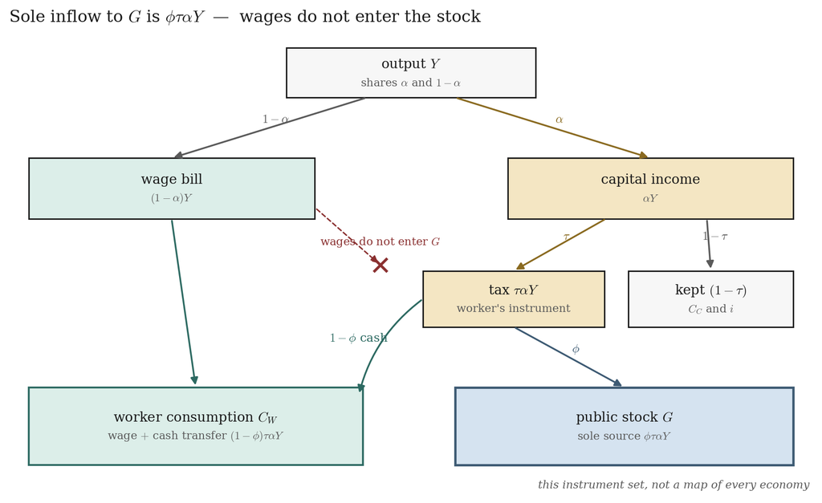

Figure 1: The public stock’s only source term. Output splits into the wage bill and capital income; the tax $\tau$ is levied on the capital share; only the building split $\phi$ enters $G$. The cash split $(1-\phi)$ joins worker consumption and does not build the stock. Wages do not enter the law of motion. This instrument set, not a map of every economy.

Shut the source off while the stock still enters worker continuation. If the stock lasts only one period it is gone next period and the worker dynasty stops; with curvature above one the continuation payoff is minus infinity, so the unfunded policy is inadmissible rather than merely worse. If the stock lasts, any interior settled public intensity forces worker growth to equal the stock’s own survival rate. The tax does not appear. A worker who taxes capital at the ceiling and transfers all of it as cash grows at the same rate as one who does not tax at all. Interiority requires strictly positive gross investment in the stock, so no such rest point is interior. Taxing capital is not a substitute for spending the proceeds on the stock that worker continuation uses.

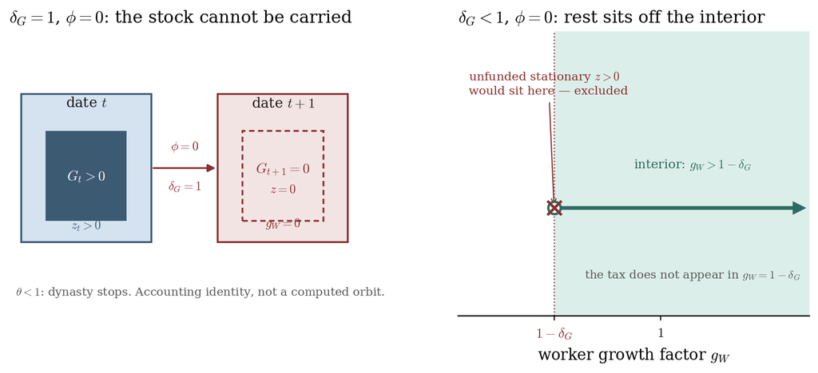

Figure 2: Unfunded public stock. Left: $\phi=0$ and $\delta_G=1$ — next period the stock is gone and worker growth is zero. Right: $\phi=0$ and $\delta_G<1$ — a stationary $z>0$ would force $g_W=1-\delta_G$, which is the excluded boundary of interiority; the tax does not appear. Accounting identities, not computed orbits.

Within this instrument set, worker continuation and capitalist accumulation are not separable. The stock on which the working class continues is paid for from the income of the class it contests. At the public-provision corner of the fiscal split, the worker’s private claim is exactly the competitive wage bill: the whole redistributive tax has become public provision. The one-period split sits at that corner whenever the tax lies below a threshold written in the public-stock wedge. The worker’s own stationary tax then stops short of taking all capital income. The gap $1-\tau^{\ast}$ is the share of the denominator that carries the capital wedge; the instrument ceiling does not do that work, and it is slack at the source paper’s reported cells (Computation 1, $\bar\tau=0.8$). A worker who owned this tax would still leave a slice of capital income untaxed, because taking it all reduces the capital stock that produces the output from which both the wage bill and the public stock are drawn.

That is a result about a model in which the worker has one tax and one split and cannot borrow against the capital he is taxed to build. It is not a historical law of the capitalist state, and it is not a theorem that no other funding route exists. Nor is the question a new one. Who bears a capital tax in a two-class economy is asked of a growing economy in Gupta (1976) and dynamically in Homma (1981). The incidence statement restated here belongs with that line, and what this paper adds is not that statement but the results that follow it.

The tradition has been measuring the working class’s fiscal position since the 1980s, and its ledger is not this one. What it measures is that position on net — what the state pays out to wage and salary earners set against what they pay in — estimated for real fiscal systems rather than derived in a model, and the recent literature calls it the net social wage (Tonak 1987; Shaikh and Tonak 1994; Maniatis and Passas 2019; Karabacak and Tonak 2022). What is measured here is a single gross flow inside a stipulated instrument set: a fraction of the capital share, on its way to a stock that worker continuation uses. The two measure different things, and a negative net position is not a counterexample to the incidence result: an economy can build its public stock out of profits and still take back more from wage-earners through the rest of its fiscal system than it hands them. What those accounts have to say to this note is about a step neither accounting avoids. Charitou, Maniatis and Passas (2025) report the net social wage ratio negative in eight of nine European countries when indirect taxes are taken to be borne partly by labour, and positive and substantial in all nine when they are taken to fall entirely on surplus value; the sign of the headline number turns on which incidence convention is adopted. This note’s counterpart is not a better convention but a statement of how far such a latitude reaches. The corresponding choice here — how much of the public stock is charged to the worker’s period — decides which side of the ledger the social wage falls on. What it cannot decide, and this is settled below, is whether there is an imbalance for it to fall inside: wherever the economy is not contracting, no defensible charging rule makes that imbalance vanish, and there is no exception to that. The arithmetic would allow one — an economy that has stopped growing whose owners consume nothing — but owners who consume nothing do not reproduce, and that economy has no rest point in this model. The placement is a convention. That there is something to place is not.

Marx’s own framing cuts across this, and the crossing is worth stating. He treats the wage bill as one historical form of appearance of the fund a worker needs to maintain himself and his family — a fund the worker must produce and reproduce whatever the system of production. On that reading a tax on profits is another form of appearance of the same fund, so calling the social wage a claim on capital states an incidence within this instrument set; it says nothing about whose labour produced the output the claim is drawn from. The model settles the first question and leaves the second untouched.

Huato’s production-and-appropriation game is the nearest neighbour and the wrong engine for this claim. His players are twins who differ only in initial wealth, with the same objective, the same production function, and the same appropriation technology. There is no demography, so the size-not-condition question cannot be posed. Intertemporal exchange is excluded by assumption; with unrationed exchange, equalised shadow prices kill appropriation. At a stationary state the aggressor, when conflict occurs, is the poorer player — a revolution model, not an extraction model. Galindo’s model is class-structural rather than endowment-symmetric. It does not turn on appropriation. The fiscal instrument reaches a reproducing population that the capitalist does not own and cannot seize, which is what lets a reproduction elasticity enter one class’s accumulation rule while cancelling from the other’s fiscal rules. Galindo (2026) §9.

# What a settled ratio equalises

A settled class ratio means both dynasties grow at the same rate. If both classes continue through the same strictly increasing map of a single index, equal growth forces those indices to match. The argument uses only injectivity. It does not use concavity, differentiability, or anyone’s objective. At any interior settled ratio the worker’s index $c_W^\theta z^{1-\theta}$ equals the capitalist’s index $c_C$. What matches is the index, not social condition. Once the ratio has settled, class disadvantage is a matter of numbers and of how the index is built.

If public provision does not enter worker continuation, the index is private consumption itself, so $c_W=c_C$ at every fiscal policy. The instruments can still change the class ratio. They cannot change the private-consumption ratio. Which way they change it is not open either. At that corner relative class size is fixed by the instruments and the capital share alone, with no reproduction primitive in it — not the scale, not the elasticity, not the map, and neither depreciation rate — and wherever the tax and the building split are both positive the capitalist class shrinks relative to the worker class as the tax rises and as the reinvested share rises, and grows relative to it as the split turns from cash towards the stock, each instrument moved with the others held (Galindo 2026, Theorem 2$'$(iv)). The source paper recovers this case from the same technology and the same budget, without preferences: the social wage is off, not a tax that failed.

If public provision does enter, the equalisation boundary still holds and the composite still matches. What opens is a private-consumption ratio that depends on policy. Along the equalised-index locus, holding capitalist consumption fixed, a larger public stock per worker goes with a smaller private claim for the worker. That direction is not a feature of the composite chosen to represent continuation: any index nondecreasing in the private good and strictly increasing in the stock displaces the private claim the same way, by an order argument on the locus that uses no derivative, no curvature and no functional form at all. What the particular composite adds is that the elasticity is constant; the sign it does not add, and the source paper is explicit that it does not. The elasticity is constant and negative. The derivative is taken on the stationarity locus, not along an equilibrium experiment: an instrument that moves the public stock generally moves capitalist consumption too. The elasticity is the shape of the boundary. The locus settles the level as well as the slope: the capitalist consumes more privately than the worker exactly when public provision per worker exceeds the worker’s own private claim, equivalently exactly when it exceeds that of the capitalist, so the private gap vanishes where provision equals capitalist consumption and changes sign across it. Neither is a statement that workers are better or worse off. Ranking the two configurations would need a social welfare function over the two dynastic sizes and a price, on both sides, of the capital-funded transfer that builds the stock. The source paper writes neither. How much of that ranking can be had without either is this note’s own question, and is taken up below.

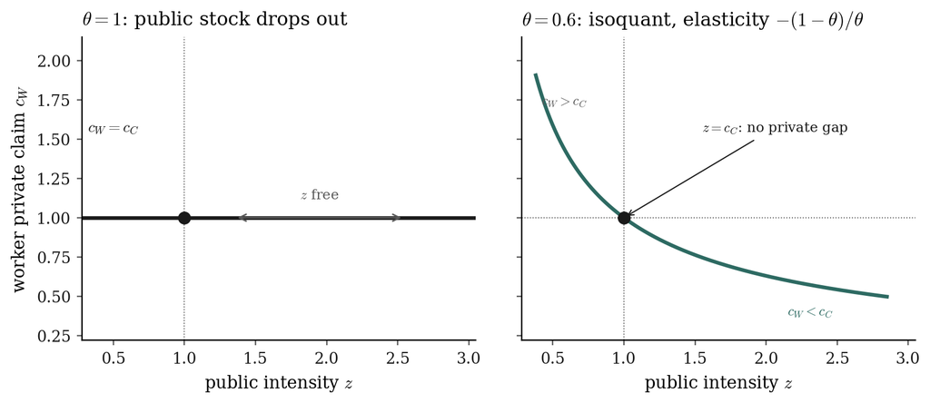

Figure 3: Equalised-index locus at fixed $c_C=1$. Left: $\theta=1$ — $z$ drops out and $c_W=c_C$ at every interior settled ratio; the instruments can still move the class ratio, which falls in the tax and in the reinvested share and rises in the building split at any positive tax and split. Right: $\theta=0.6$ — the locus is the isoquant of the worker’s index, with log-elasticity $-(1-\theta)/\theta$. The marked point is $z=c_C$, where the private gap is zero for any $\theta$. Taken at fixed capitalist consumption, not along an equilibrium experiment, and not a welfare ranking.

A common continuation map does not, by itself, give workers a worse private condition once private consumption differs. Written as a map of private consumption, the worker’s technology is class-specific: the private gap offsets public provision, not a built-in efficiency difference. That offset is not a welfare ranking.

This is not Barro–Becker under another name. There, parents choose both how many children to have and how much to give each child, and equalisation comes from that choice. Here fertility is not a choice. Continuation is a technology that turns this period’s consumption into next period’s numbers — the move Brezis (2001) made against altruistic fertility in a two-class setting. She takes the elite population to be negligible, so there is no class ratio to have a law of motion. Here that ratio is the object. Equalisation holds only at a settled class ratio; it is not a one-period identity of a fertility first-order condition. Galindo (2026) §9 records the comparison.

The index is not the value of labour-power. Huato and Galindo’s joint work treats labour-power as the value source in a price-taking setting without strategic interaction. This game is a strategic closure of a different object: a contested continuation technology, paid for from capital, with different class objectives. Identifying the composite with a value-form would be a further derivation, not a relabelling of the source paper’s Theorem 1.

Equal growth pins the index; the index does not pin the private claim; and what stands between the two is public provision. A worker whose private consumption falls as the public stock rises has had his continuation recomposed. Whether that is also a reduction the index cannot say, and it is the question the next section settles without the apparatus that would ordinarily be required to pose it.

# Ranking two configurations without a welfare function

Everything above reports what the source paper establishes. The results that follow do not: they are this paper’s own, and they are proved in Appendix A rather than cited. Where the argument still leans on the source or on the outside literature, that debt is named at the point of use. They take up the three derivations the source declines — the ranking of two settled configurations, what the shared index is not, and the question of whose labour produced the output — and the last of those yields two results rather than one, because it is two questions wearing a single name. They are not confined to those three. The worker’s own tax is a question the source does pose and partly answers; what it does not ask, and what is settled here, is how many times the direction of that tax can turn as the worker’s caution varies. Begin with the ranking, which the source declines on two grounds — that it would need a social welfare function over the two dynastic sizes, and that it would need a price, on both sides, of the capital-funded transfer. The first ground does not survive. The second does, and stating it precisely is what the first one’s removal buys.

Take two configurations that have come to rest — not merely a class ratio that has stopped moving, but the whole state, so that the two growth factors are equal and each is the same from one date to the next — and start them from the same number of workers. There is then one growth factor, and the worker’s dynasty is that factor and its starting size and nothing else, at every date. His payoff is a strictly increasing function of the factor. The capitalist’s payoff object is not his dynasty — he has left his own numbers out of it — but it is retained consumption and owned capital, and that composite is homogeneous of degree one in the capital stock and the workforce. At a rest point it therefore grows at the same factor the workers do. His payoff is a strictly increasing function of that same factor too, together with the level at which his object starts. So the worker’s side of the ranking is unconditional, and the capitalist’s turns on how that starting level moves. Neither of those is a normative question. What a social welfare function would have been for — supplying weights before either class could be ranked — is not needed at all; what it is still for, if the two rankings disagree, is a different matter, and the next paragraphs say exactly when that arises.

What the classes agree on has a name in the model already. The growth factor is a strictly increasing function of the reproduction index, and a settled ratio is exactly where the two classes’ indices coincide. The index is therefore not only the argument of the continuation technology: over settled configurations it is an ordinal measure of the ranking both classes accept, and by the equalisation it is the capitalist’s private consumption per head. That the worker’s own long-run standing is measured by the capitalist’s consumption is not a claim that one causes the other. It is what a settled class ratio means: both classes’ continuation is tied to a single index, and a configuration that raises it raises the growth factor both of them are paid in. Whether it raises the capitalist’s payoff as well depends on the one further term his object carries, which is the subject of the last paragraph but one.

This sharpens the earlier result rather than reversing it. Along the equalised-index locus at fixed capitalist consumption, a larger public stock goes with a smaller private claim. That movement holds the index fixed, so it holds the growth factor fixed, so it leaves the worker’s dynasty identical date by date. The crowding-out of the private claim by public provision is exactly neutral there, not approximately: it is a recomposition of how continuation is delivered and not a loss of it. Whatever welfare content the fiscal split has must therefore come from moving the index itself, and not from the substitution the locus describes. A criticism of public provision that points at the falling private claim is pointing at the one margin along which nothing happens.

The second reason does not stand either, and what replaces it is the more interesting result. The capitalist’s starting level is his own class’s consumption and capital taken per worker, and per worker both of those depend on the configuration only through capital per worker. Capital per worker is pinned by the growth factor: a faster-growing configuration sustains its growth on a thinner capital stock per worker, because the same reinvested slice has to equip more workers. So his starting level falls, always, whenever the growth factor rises. His two channels therefore pull against each other, and which wins is not a matter of weights at all. It is an inequality between his effective discount and a dilution term built from the capital share, the weight he puts on owned capital, and the depreciation of private capital.

Both signs of that inequality occur among admissible parameters. Where private capital depreciates at an ordinary rate the discount term wins and the two classes agree, faster growth being worth more to the capitalist than the thinner stock it leaves him. Where private capital is durable the dilution term wins and he is made worse off by the faster-growing configuration, so the classes are in genuine conflict over the fiscal split. One caution belongs with that immediately: the growth factor is not something one sets, it is what the stationary system settles at, so showing that the inequality can fall either way is not yet showing that a policy could put an economy on either side of it. That second step is taken here rather than assumed. Hold the tax and the reinvested share fixed and move only the split between cash and the stock: two admissible settings induce two rest points whose growth factors the stationary system itself selects, and at a weight on owned capital near the top of its range the criterion holds at one and fails at the other. Both regimes are reached, then, and not merely stateable — for that pair, which is what an existence claim asks for, and not for every calibration. At a given growth factor, durability of the private stock — not the size of the social wage — is what decides which regime the economy is in. That is a statement about primitives, and it is the whole of what the source meant by pricing the transfer on both sides, recovered as a comparative static rather than written as a criterion.

It matters where the source’s own economy falls, because a dichotomy with one unreachable side would be an empty one. At the source’s calibration, and at every weight on owned capital it reports, the threshold sits well below the depreciation rate it uses: the two classes agree there, and comfortably. What reaches the other side is not a larger social wage but a different capitalist — one who values owning capital almost to the exclusion of consuming it. At the two profiles the source itself reports, not even that reaches it: the separating weight lies above one at both, so the conflict regime is empty there at every admissible weight. That is exact, and not a report of where one calibration happens to sit. The weight he puts on owning capital enters the criterion linearly, so a single value of it separates the two regimes rather than a region found by trying values; that value can be written in the primitives; and at a rest point induced from that calibration it stands about two per cent below the top of the range the weight can take, while at both growth factors the source itself reports there it stands above that range altogether, so no admissible owner reaches the conflict at either. So the conflict this note identifies is real — a pair of induced rest points straddles it — and it is not generic, and the thing that would tip an economy into it is a change in what the owning class wants rather than in what the working class is given. That is a more useful finding than a conflict claimed everywhere, and a more uncomfortable one for the reading that expects the social wage itself to be the point of contention.

That conflict belongs to the comparison in which the reinvestment rate stands still while the split moves, which is the comparison that matters, because the split is what the two classes contest. It would be natural to think the capitalist could escape it by reinvesting more as growth rises, and he cannot do so freely. Reinvesting more does thicken the capital stock each worker has to work with, but it is paid for out of his own consumption, and the two effects run against each other. Which one wins is decided by where his reinvestment rate already stands relative to the capital share, adjusted for how much he values owning capital rather than consuming. Below that line reinvesting more closes the disagreement; above it, reinvesting more widens it. So the instrument the capitalist holds is not a way out of the contest either, and whether it helps him is fixed by the technology rather than chosen by him. The tax differs from the reinvestment rate in one respect. Its weight in his ranking is the capital share and nothing else — how much he values owning capital rather than consuming it cancels out of that channel entirely, which it does not do out of the other — so a comparison that reaches faster growth by cutting the tax favours him whatever sort of capitalist he is, and one that reaches it by raising the tax does not. Which of those a tax family is remains a question about the settled system rather than about him, and along the one family the source itself pins — the worker sitting at his own stationary tax — the settled system answers it. What decides the answer is not the tax and not the split but how cautious the worker is. Where the public stock is the more durable of the two, and where he is patient enough — a threshold on his discount factor that carries no instrument, only the technology and the growth factor — there is a single level of caution, carrying no instrument either, below which faster growth arrives with a lower tax and above which it arrives with a higher one. Let him fail that patience threshold and, so long as the public stock’s own gross investment margin does not fall below the private one by more than the weight on private consumption times the labour share, the tax rises with growth however cautious he is. Where that margin does fall that far the direction turns twice instead of never, and at ordinary degrees of caution: at a capital share of a tenth, private capital wearing out at four fifths a period against a tenth in the public stock, and a growth factor of $1.1$, it turns at curvatures of about $1.85$ and about $2.50$, a band that straddles the curvature the source fixes for its capitalist. Nowhere, at any admissible configuration and any growth factor, does it turn more than twice. A contracting economy runs the same argument backwards: caution there raises the effective discount rather than lowering it, and properness stops being a condition met at every curvature and becomes a ceiling on how cautious the worker may be. The single turnover then sits where the public stock is the *less* durable, which is the reverse of the arrangement above, so which side of the durability comparison carries it is decided by the direction of growth rather than by the technology alone. And where the growth factor is one the question closes altogether, his caution having no purchase on the effective discount at all, so the direction turns exactly once when two coefficients written in the primitives share a sign and not at all otherwise. For a worker cautious without limit — a case a growing economy alone affords him — the question collapses to which of the two stocks wears out faster, every other primitive having left the answer. The economy the source reports is close enough to that boundary that its own two profiles at a single calibration fall on opposite sides of it. The same qualification reaches the dynastic sizes themselves if one insists on ranking those: the capitalist’s dynasty carries the class ratio as a level, so a faster-growing configuration overtakes a slower one only from a date that the two ratios and the two factors fix exactly.

Three limits travel with all of this. It compares configurations that have settled, each evaluated from its own rest point, and says nothing about the road to one. The source locates the entire gap between the split that maximises growth and the split a worker actually chooses in precisely that transition, so this result cannot be read as endorsing either. And unanimity over configurations is not efficiency at one: two classes agreeing on how to rank settled outcomes is a different statement from neither being able to do better at the outcome they are at. And the finite-time reversal of the capitalist’s dynastic ranking is proved for any pair of settled configurations whose growth and class-ratio orderings oppose — a pair the stationary system does induce, and along the very family the source itself varies: move the split with the tax and the reinvestment rate held and the growth factor and the class ratio go opposite ways wherever either moves at all, so any two splits on one side of the turning point are such a pair. What is not claimed is that the two orderings must oppose under an arbitrary joint move of the instruments; the opposition proved here belongs to that family.

The index is also not a magnitude got by adding the worker’s two reproduction inputs together, and here that is a theorem rather than a fence. Give those inputs a magnitude by adding them up — so much for the private good, so much for the public stock, the total scaling with quantity as such a magnitude must. That total and the reproduction index do not rank bundles the same way, at any interior weight on private consumption. The index’s level curves bend; an additive total’s are straight. The one exception is the degenerate case: at weight one the public stock has already left the index, and the two agree because only one input is left to add. So the identification declined earlier is not merely underived here. Within this model it is available exactly where the social wage does no work, and forcing it anywhere else costs the step that makes an unfunded perishable stock stop the worker dynasty — the mechanism the whole argument turns on. The claim is about totals built by adding the two inputs the index aggregates; a magnitude attached instead to the labour that produces them is untouched, and stays what it was, a further derivation.

# Whose labour, and what can be charged to it

Whose labour produced the output the claim is drawn from is not one question but two: the model has two different things to say, and only one of them is a magnitude. On the input side it is not silent at all. The worker population is the only labour the technology uses; the capitalist’s numbers enter neither output nor either stock law, and the source says so in those words. That leaves exactly one thing in the whole chain that is neither an instrument, nor a constant of the technology, nor a person: the stock the economy starts with. At a configuration at rest that stock is not free. Capital and public provision per worker are pinned by the instruments and the technology, so the state is worker headcount multiplied by two numbers the policy chooses, and the configurations compared above differ in their instruments or their technology rather than in what they were handed. Away from rest the starting stocks do matter, and they do not simply fade. They are converted: wherever the economy settles at all — anywhere in the basin of the rest point, not merely near it — the worker population settles onto a fixed multiple of the growth path, and that multiple is where the starting stocks have gone. What such an economy carries forward from its endowment is not capital. It is people — and the capital it ends up with is whatever those people are equipped with, at an intensity the instruments and the technology fix between them. The stock is not absent from the long run; it is absent from the part of the long run the endowment still reaches.

Two things qualify that conversion, and the second changes its size. The rate of the conversion is the source’s own stability rate, and what buys it is interiority — strictly positive gross investment in both stocks, which is the same condition that makes the two survival shares fall short of one, and the same one an unfunded stock violates. At the single point where they do not fall short, two of the source’s three stability margins bind with equality, and its assumptions exclude that point twice over. But the private stock’s persistence is not its rate of decay. It is the elasticity the source already writes into the capital wedge, and it exceeds bare survival by the share of gross investment that returns through production; it falls below one only because capital’s marginal product diminishes. So an account that charges the endowment nothing beyond its physical remnant is too generous to the labour side of the ledger, and the model says by exactly how much. None of this attaches a magnitude to anything. It says which primitive the long-run state carries, not what a unit of output contains, and the shortcut is unavailable for the reason just given: an index that no additive total orders alike does not become a value magnitude by being renamed one.

Saying that no magnitude can be read off the index is not the same as saying the model will not carry one at all, because the model runs two activities and the index belongs to only one of them. Goods are made from goods and labour; workers are made from goods. Put the old question to each in turn — give a unit of the good one magnitude and a unit of labour another, require each activity to hand on exactly what it uses up, and see whether the model will bear it — and the two answer differently.

Production bears it, and on precise terms. There is one such assignment, up to the choice of unit, and it is the familiar one: what a unit of output is worth is the labour done directly, plus the labour in the capital worn out making it, plus the labour in the capital worn out making that, and so on down. The series adds up exactly when replacing worn-out capital takes less than the whole product. That is a real restriction and not a formality. It is stronger than the condition the model already needs for a rest point to exist, and the gap between the two is the reinvested share of output times the rate at which capital wears out. At a growth factor of one or above it is automatic. Below one it can fail, at configurations the model itself reaches: an economy growing slowly enough holds so much capital per worker that replacement eats the entire product, and then there is nothing left for any accounting to distribute.

Reproduction does not bear it. Ask that activity to hand on what it uses up — a worker and a period’s goods in, more workers out — and the demand cannot be met alongside the first. The two requirements over-determine the two magnitudes, and the model does not satisfy the equation that would reconcile them. The failure is not a residue or an approximation. It is exactly capitalist consumption plus the growth of the two stocks. What a worker’s period yields, over what that period costs to sustain, is what the owning class consumes together with what the economy adds to its capital and to its public provision. Consumption by the owning class and accumulation are the two things such a remainder can go to, and here they exhaust it — as an identity in the source’s primitives, not as an assumption laid over them. It also runs one way only: a technique that cannot reproduce itself leaves nothing over, so the restriction above is necessary for a positive remainder, and it is not sufficient.

The public stock is where this bites, and it does not fall on one side. It enters that identity twice, with different coefficients. What the period wears out of it counts against the worker’s side, as part of what sustaining him costs. What the period adds to it counts on the other side, alongside private accumulation. Maintaining the social wage belongs to the cost of the working class; enlarging it does not. The note’s claim that the social wage is a claim on capital survives that intact and gains a boundary it did not have: the upkeep of the stock sits on the workers’ side of the ledger and its growth on capital’s, and one tax funds both without distinguishing them.

That last division is the one place here where the answer is chosen rather than found. Whether the arithmetic closes, and where, does not depend on how the public stock is charged. Where the public stock lands does, and completely. The rule used above charges each activity what it wears out and not what it invests, which is the rule already being applied to machinery on the other side of the same identity; that is its whole recommendation, and it is a good one. But a reader who holds that public provision is not consumed by being used will charge the worker nothing for it, and then the entire social wage — upkeep and growth together — sits with capitalist consumption on the other side. A reader who holds that the tax buys the stock on the working class’s behalf will charge the whole of it, and then the social wage vanishes from that side altogether. All three are exact, and the model does not choose between them. The disagreement about whether the social wage is part of what labour costs is therefore not a disagreement this model can settle — but it is now a disagreement with three stated positions and an identity that says exactly what each one implies, which is more than it had before.

What that latitude cannot touch is whether there is anything left over to place, and this is where the argument closes rather than trailing off. Ask what bundle *would* make the two halves balance, and the answer is forced: the magnitudes cancel and one number survives, the growth premium multiplied by net output. Compare it to what any rule can charge. Every rule charges the worker at least what he himself consumes, so balancing needs the growth premium, net of replacement, to be at least the worker’s whole consumption share — and since that share is at least the labour share, it needs a growth factor above two minus the capital share. At the capital share this model uses that is a growth factor above one and two thirds, per period. The source’s economy grows at about three per cent. It is not near the line: the bundle that would balance is about a twenty-eighth of what the worker himself consumes, and every economy that is not growing at all fails the requirement outright, whatever the rule.

There is a second line, and it sits above rather than below. Run the same comparison from the other end. A rule cannot charge the worker more than what he consumes plus the whole of what the period puts into public provision, because the period contains nothing else to charge him: the machinery it wears out is already charged to production, and charging one real thing to both activities is the double count the argument refuses on its other side. That refusal is a convention, and the conclusion does not stand on it. A rule that ignored the double count altogether still could not charge the worker more than his period’s whole net product, and that alone stops the growth factor at two. So the window is bounded above whatever one decides about charging a thing twice; what the convention decides is how far below two the upper edge falls, and no more. That ceiling is strictly below the whole product, short of it by exactly the share capital keeps after tax; below net output it is short by that share less the machinery worn out in the period. So balancing fails again before the growth factor reaches two, short of it by a margin no wider than the capital share: past that upper edge the bundle that would balance the two halves exceeds everything the worker’s period commands. Closure is therefore not a shortfall that faster growth would cure. It is a window; without the convention it is exactly as wide as the capital share, and the convention only narrows it; and its width closes to nothing as that share does. Below it the balancing bundle is smaller than what the worker himself eats; above it, larger than everything the period has to give him. Both are refusals, and at the period length the source’s own calibration describes, no measured economy sits between them. What is left over is left over on either side: it is never less than what capital keeps after tax, once the machinery worn out in the period has been replaced.

There is a way of seeing what the failure costs, and it turns a leftover into a rate. The accounting assumes something it never states: that a unit of a good is worth the same amount of labour this period as next. Drop that and the arithmetic goes through at every date — but only by letting the worth of a unit drift, period after period, and the required drift can be computed. At the source’s economy it is about eighty per cent a period, and it barely moves whichever of the three charging rules is used. That is at a settled configuration, where output per worker, the stock per worker and the technology are the same from one date to the next, so nothing is changing that a changing worth could be tracking. Requiring the worth of a good to be a fact about the good rather than about the date is exactly the balancing condition, no more and no less.

So the remainder is not an artefact of how the social wage is counted. Nor is it an artefact of the rule being a fixed share of output: every step of the argument is a statement about a single date, so both edges bind at any configuration at rest, whatever kind of rule brought the economy to it. What the fixed shares are still needed for is that such a configuration should exist at all, and for anything said about the road to one. Under every rule, at every configuration at rest that is not contracting, the two halves do not balance and something is left over. And the leftover is not a residue the accounting failed to place. Under the broadest charge it is exactly two things: what the period adds to private capital, and what the owning class consumes. Those are the two uses of the product a worker’s period cannot be charged with, so where the economy is not contracting the leftover would disappear only where both do — in an economy that has stopped growing whose owners consume nothing. There is no such economy. In a contracting economy the first of the two is negative and can outweigh the second — A.10(iv) exhibits a rest point at which it does — which is why every statement of the result carries the scope. An owning class that consumes nothing does not reproduce at all, so the stationary class ratio the case would need does not exist. That is not a corner but an absence, and it is why the statement needs no exception inside its scope: wherever this model is not contracting something is left over, and what is left over is the owners’ share seen from the other side. What the charging rule settles is only where the social wage sits inside that remainder. That is the honest shape of the result: a placement the model leaves open, around a residue the model does not leave open at all.

There is one more thing to take from that remainder, and it is the form in which this question is usually asked. Set what a worker’s period yields against what it costs, both counted in labour, and the ratio of the two is the quantity the tradition states its findings in. Here that ratio is not a number. It is an interval, because the charging rule is not settled, and it has a width only because there is a social wage: charge the worker nothing for the public stock and the ratio stands at its highest, charge him the whole of what the period puts into that stock and it stands at its lowest, and where there is no social wage the two coincide and the ratio is a number again. The split between cash and the stock does not touch both ends alike: it leaves the bottom of the range exactly where it was and raises only the top, so turning the tax towards the stock cannot alter the least rate the accounting will permit and can only widen the range above it. At the economy the source reports it runs from about a tenth to about two fifths, against a ceiling — binding wherever the accounting works at all, under every rule of the kind considered here — of the capital share divided by the labour share, which at these numbers is close to a half. The width is more than two and a half times the floor. So how the social wage is counted is a small matter for whether anything is left over, which is settled, and a large one for how large the leftover is reported to be.

That ratio is also what the failure to balance was asking for all along. A rule that balanced the two halves would need it to take one particular value, fixed by the growth rate and by nothing else, running from the ceiling itself at the slow edge of the window down to zero at the fast edge. Below the window, balancing asks for more than these shares can supply; above it, for less than the owners’ own claim on the product already leaves standing. At a growth rate of one it asks for a rate no shares could meet, and below one it asks for something that is not a rate at all. The two edges stop being separate facts with separate proofs and become one condition, in a coordinate where they were always the same condition, which is also why faster growth cannot cure the failure.

None of this says whose labour produced the output, and the reason is plain. The accounting was told to charge labour and nothing else. That is a convention, taken here because it is the tradition’s, and the model neither supplies it nor refutes it. What the model does supply is the answer to a question that can be put without it: granted the convention, will the arithmetic close? On production it closes, and only on a region the model can leave. On reproduction it does not close, and the gap is exact. So the old question is narrower than it looked, and narrower at no cost to the argument: what stood as a silence is a boundary with two sides and a closed form across it.

# Why “accumulate everything” is not a theory of the decision

The capitalist in this model does not maximise the size of his dynasty. Continuation is still a technology for him, and his numbers still grow with his private consumption, but that growth is not his payoff. He maximises an aggregate of retained consumption and the capital stock he owns, with weight on the stock strictly less than one. For positive weight on the stock, that is the formal content of accumulation pursued for its own sake; at zero weight, it is the standard consumption objective.

If the weight is one, the payoff object is the stock alone. Reinvestment then costs him nothing he values, the interior margin vanishes, and the reinvestment rate goes to its corner with no first-order condition. The same conclusion follows without an envelope: raising the rate raises every later capital stock, and nothing in the payoff falls. A contested accumulation decision exists only when reinvesting still costs him something he values. Pure accumulation, the heuristic that the capitalist cares only for the stock, extinguishes the margin that heuristic was meant to supply. The opposite objective fails for a different reason. An objective in the profit rate is homogeneous of degree zero, destroys the reduction to ratios, and drives the rate to zero because the profit rate falls as the stock it accumulates rises.

What survives is the interior of the family. At zero weight on the stock the capitalist is a consumption objective; above zero the stock enters directly. The source paper is stated over that interior, not at one chosen point in it.

The capitalist must still put a price on the workforce. That requirement does not come from his own numbers, which have left his payoff. It comes from production: labour is the complementary factor, and more workers raise his output, his consumption, and the stock he accumulates. Under a dynastic objective that channel is mixed with a second one — more workers as more of his own descendants. Under the accumulation objective only the production channel survives. The class-asymmetric term in his reinvestment rule is therefore a fact about who produces, not about who continues, which is also why the reinvestment rate, unlike the worker’s tax, moves with the elasticity of the continuation technology. That elasticity cannot cancel from a valuation of the workforce, because the workforce’s own law of motion carries a leading one that no elasticity multiplies.

# What the wedges are not

The first-order conditions of the stationary profile contain two transition wedges. The public-stock wedge is a proper fraction if and only if the worker’s discounted total stays finite; on that region it rises with the stock’s depreciation. The capital wedge is the same object read on the private stock. Neither contains the outer elasticity of continuation. Each is the discounted resolvent of a stock law: a durable stock is slow-moving, and perishability buys delivery.

The growth-maximising split is the stationary split evaluated as if the wedge equalled one. It over-predicts the stationary split wherever the worker’s discounted total stays finite. That direction is Futagami, Morita and Shibata’s, for a public input in production, as Galindo (2026) §9 records. What is this model’s own is that the gap is the wedge, that the public input sits in continuation rather than in production, and that what it moves is class composition and who funds continuation, not the marginal product of capital.

These objects are prices of moving the two stocks — how much of a change in a flow arrives, discounted, as a change in the intensive state. They are not generic costs of exploitation, surplus value, the length of the working day, or a moral residual. At a profile evaluated at the rest point it induces, each one-period margin already carries the sign of the total change in the discounted payoff, including the transition and the induced change in growth (Galindo 2026, Theorem 4; the start is that rest point). That identity is why a stationary first-order condition is informative about the full payoff at that start. It is not why exploitation has a price.

The same outer elasticity that makes the class ratio a contraction at an interior rest point also carries the fiscal asymmetry. Local rest-point stability is a theorem inside constant-share profiles; a far-field orbit is a different question.

The negative is not a retreat. A residue would have left who funds continuation to rhetoric; a price leaves it to a closed form, and one that answers a different question from the marginal product of capital rather than the same one badly.

# Conclusion

The social wage here is a claim on capital, and cash is not a substitute for the stock it builds. Unfunded, a perishable stock stops the worker dynasty; a durable stock has no interior settled provision, at any tax. Within this tax base the two classes are not separable: at the public-provision corner the worker’s private claim is the competitive wage bill. Where the tax ceiling is slack, as it is at the source paper’s reported cells, what stops the worker short of full expropriation is the capital wedge and not that ceiling. Pure accumulation — the capitalist who values only capital — has no interior reinvestment decision. When the public stock matters for worker continuation, who pays for it and what it replaces in the private claim are not independent objects.

A settled class ratio equalises a reproduction index. Where that index mixes private consumption and the public stock, the private claim can fall as the stock rises. That is how continuation is composed, and it is not the value of labour-power.

The source paper defines a constant-share stationary equilibrium. That restriction is not shown to be without loss against state-dependent rules; one annihilating family in the split, at fixed tax and reinvestment, exists and is nowhere dense on compact subintervals of its open admissible band. A stationary profile is not yet a global best reply from a declared start. The split and the reinvestment rate single-cross; the worker’s joint tax-and-split condition is a theorem when both stocks fully depreciate and open otherwise, and the transfer from an induced rest point to a fixed declared start remains conditional.

The remaining theorem is the worker’s unique reply in the pair he owns, off the full-depreciation face, together with that fixed-start transfer. Closing them would not found a historical law of the state. It would establish the conditions under which capital-funded public provision, when it is the one-period split, is the worker’s answer in the pair he actually holds.

This paper’s own results start from a single fact. A configuration at rest leaves one growth factor, unchanging from date to date, and the capitalist’s payoff object grows at that same factor there. The worker’s payoff rises with it without qualification; the index the two classes share is what represents that ranking, and the substitution of public provision for the private claim, taken at a fixed index, changes nothing about the worker’s dynasty at any date. The capitalist’s payoff rises with it too, but only against a second channel: sustaining faster growth leaves a thinner capital stock per worker, which cuts the level his object starts from. The contest between the two is an inequality in the primitives, and at any given growth factor it turns on how durable private capital is. Nor is that only a statement at a fixed growth factor. Hold the shares and let the system reselect its own growth factor as durability moves, and the disagreement is confined to a lower interval in durability: the boundary is crossed at most once, so the conflict has an edge in that parameter rather than recurring across it.

That is a demarcation rather than an abolition, and the difference matters. Ranking the two configurations from each class’s own objective needs no social welfare function anywhere: both rankings are comparative statics, and the inequality says which way each falls. A social welfare function becomes necessary only where the two rankings disagree and one verdict is nonetheless wanted — and the same inequality says exactly when that is. So the model does not dispense with normative choice; it confines it, and tells you the boundary of its own confinement. At the source’s own numbers the classes are on the agreeing side of that boundary, and reaching the other side takes a capitalist who values owning capital almost to the exclusion of consuming — a boundary that is a single weight, written in the primitives, and not a region arrived at by trying values. At the two profiles the source itself reports, that weight lies above one, so the conflict regime is empty there at every admissible weight. Under the curvature-against-durability inequality (A.14$'''$), at any locally attracting rest point of the source’s share loop, conflict is an upper interval in the weight on owned capital along the correspondence. Ranked instead by the sheer size of the two dynasties, the classes are not alike: the capitalist’s ordering between two configurations reverses in finite time wherever their growth and class-ratio orderings oppose, and the worker’s cannot, because a reversal needs a level to trade against a rate and, where the two start from a common population, only the capitalist’s dynasty carries one — a comparison of one economy’s policies, not of two economies that might differ in their starting numbers as well; and the opposition is not a hypothesis waiting on a case, since moving the split along the family the source itself varies produces it at every admissible split but at most one. What looked like a question needing a criterion was a question needing an object, and the object turned out to be the capital stock each worker has to work with.

The worker’s own tax answers to the same kind of boundary, and the thing that decides it is how cautious he is. Along the one tax family the source itself pins, his patience can turn that direction at most twice at any growth factor other than one, whatever the configuration, and at a growth factor of one exactly once when two coefficients written in the primitives share a sign and not at all otherwise, his caution there having no purchase on the effective discount at all. Where the public stock is the more durable of the two and his discount factor clears a level those same primitives write down, it turns exactly once, so that a single level of caution separates a tax that falls with faster growth from one that rises, and nothing further is asked of the discount factor. A contracting economy reverses which side of the durability comparison that single turnover sits on: there it is the *less* durable public stock that carries it, and it carries it everywhere on that side rather than under a condition. It also puts a ceiling on the worker himself. Where the economy shrinks, patience raises the effective discount rather than lowering it, so the requirement that his discounted total converge ceases to be a condition satisfied at every degree of caution and becomes a bound on caution, written in his discount factor and the growth factor alone. An indefinitely prudent worker is a figure only a growing economy affords. So the parity of the count is not a fact about the technology alone but about the technology and the direction of growth together. Everywhere else the two ends agree and the count is even, and whether it is two or none is settled by the sign the carrier takes at the roots of one quadratic in the effective discount — the same quadratic that, read as the derivative of the carrier rather than as its value, is what bounds the count at two in the first place. Those roots are a square root away from the primitives and the carrier’s value at them is a logarithm away, so the line dividing the two counts is an equation a reader can write down rather than a region a reader must search, even though no single primitive can be solved out of it. Where the crossings themselves fall stays out of reach; which stretch of the worker’s caution holds one, and that it holds no more than one, does not. For a worker cautious without limit the question collapses altogether, to which of the two stocks wears out faster and to nothing else — the capital share, his patience and the weight he puts on private consumption having all left the answer. The capital share leaves for a wider reason than that limit: wherever the two stocks wear out at the same rate it is absent from his tax elasticity at every curvature, and full depreciation is one point of that locus rather than the fact itself. The source’s own economy sits close enough to that boundary that its two reported profiles fall on opposite sides of it.

The index that carries the ranking is not itself a magnitude got by adding the worker’s two inputs together: at any interior weight the two rank bundles differently, and they agree only where the public stock has already left the index. And on the question of whose labour the output came from, the model divides what looks like one question. The input side it settles: the worker population is the only labour in the technology, the intensities at rest are pinned by the instruments, and what an economy carries forward from its starting stocks is not capital but a level on its worker population.

The magnitude side cannot be reached by relabelling, and it is not a silence either. The accounting the tradition uses — labour charged, and nothing else — closes on the making of goods, uniquely, and only while replacing worn-out capital takes less than the whole product. It does not close on the making of workers, and what it leaves over there is exactly capitalist consumption plus the growth of the two stocks. Where the social wage falls within that is the one thing the model declines to settle: charge each activity what it wears out, as the same identity charges machinery, and the stock’s upkeep counts against the working class while its growth counts against capital; the two other defensible rules move the whole of it to one side. That latitude is bounded, and the bound is what makes it tolerable. Exactly one bundle would balance the two halves, and reaching it under any rule needs a growth factor above two minus the capital share and below two — which the source’s own economy misses from below, its balancing bundle coming to about a twenty-eighth of what the worker himself consumes, and which no stationary economy meets at the period length that calibration describes — growth of sixty-seven to a hundred per cent in a single period, which is empty read as a year and unremarkable read as a generation, and the source declares no period, so this is a statement about that calibration and not an empirical universal. Faster growth is no escape either, because that requirement is a window and not a floor: past its upper edge the balancing bundle exceeds everything the worker’s period commands. The remainder is therefore common to every rule, and the rule fixes only where the social wage sits inside it. Set what a worker’s period yields against what it costs, both in labour, and that ratio — the form in which this tradition states its results — is an interval rather than a number, which has a width only because there is a social wage and closes exactly as that wage does, and which lies under a ceiling of the capital share over the labour share wherever production conserves. A balancing rule demands one value of it, carrying the growth factor and nothing else, so the window’s two edges are a single condition on that ratio and not two: below the window balancing asks more than these shares can supply, above it less than the owners’ claim already leaves standing. What remains genuinely unsettled is small and sharp: not whether the arithmetic works, nor whether there is a remainder, but whether labour is the thing to charge and how the stock is charged.

# Appendix A. Formal statements

The statements below through Proposition A.6 are those of Galindo (2026), restated for this note and in places narrowed to the case the argument uses. They are collected here so the body can stay in words. Proofs are compressed, and where a step is the source’s it is named rather than repeated. Numbering is local to this note. Everything from Proposition A.7 onward is outside the restated material: those statements are this paper’s own, they are proved rather than cited, and they are not to be attributed to the source. They are also the greater part of what follows. The restated statements are a foundation laid so the argument can proceed in words, and more of this appendix is built past that foundation than lies within it — an impossibility theorem, an order theorem obtained with no social welfare function, an exact identity, a closed-form two-sided band, and a count settled at every growth factor.

The reproduction maps are
$$g_{W,t} = B\big(c_{W,t}^{\theta} z_t^{1-\theta}\big)^{\gamma},
\qquad
g_{C,t} = B\,c_{C,t}^{\gamma},
\qquad
B>0,\quad 0<\theta\le 1,\quad 0<\gamma<1.
\tag{A.0}$$
Output is produced from the two class inputs and paid competitively, $Y_t = A K_t^{\alpha} N_{W,t}^{1-\alpha}$ with $A>0$, so the wage share $(1-\alpha)Y_t$ accrues to the worker class and the capital share $\alpha Y_t$ to the capitalist class. Private consumption and the two stock laws are
$$C_{W,t} = \big[(1-\alpha)+(1-\phi_t)\tau_t\alpha\big]Y_t,
\qquad
C_{C,t} = (1-i_t)(1-\tau_t)\alpha Y_t,
\tag{A.0$'$}$$
with $\alpha\in(0,1)$ and $\delta,\delta_G\in(0,1]$, and all three instruments shares: $\tau_t\in[0,\bar\tau]$ with $\bar\tau<1$, $\phi_t\in[0,1]$, $i_t\in[0,1]$.
$$G_{t+1} = (1-\delta_G)G_t + \phi_t\tau_t\alpha Y_t,
\qquad
K_{t+1} = (1-\delta)K_t + i_t(1-\tau_t)\alpha Y_t.
\tag{A.4}$$

**Lemma A.1 (index equalisation).** Let each class reproduce through a scalar index of its own inputs, $g_j=F(x_j)$, with $F$ strictly increasing. Then at any interior stationary class ratio, $x_W=x_C$, whatever $F$ is and whatever the policy.

*Proof.* Interior stationarity of $\nu$ is $\nu'=\nu$ with $\nu\in(0,\infty)$, which is $g_C=g_W$. A strictly increasing map on $(0,\infty)$ is injective, so $F(x_W)=F(x_C)$ forces $x_W=x_C$. No instrument enters. $\square$

Under (A.0) this is
$$c_W^{\theta} z^{1-\theta} = c_C.
\tag{A.1}$$

**Proposition A.1 (no-social-wage nesting).** If $\theta=1$, then at any interior stationary class ratio $c_W=c_C$. The public stock drops out of the worker’s map. The instruments do not appear in that identity.

*Proof.* $\theta=1$ in (A.0) gives $g_W=B c_W^{\gamma}$. Stationarity is $B c_C^{\gamma}=B c_W^{\gamma}$. Since $B>0$ and $\gamma>0$, $u\mapsto Bu^{\gamma}$ is strictly increasing, hence $c_W=c_C$. $\square$

**Lemma A.1$'$ (displacement without a functional form).** Let $x_C=c_C$ and let the worker’s index be $x_W=h(c_W,z)$ for an $h$ nondecreasing in $c_W$ and strictly increasing in $z$, with $F$ strictly increasing as in Lemma A.1. Then at any interior stationary class ratio $h(c_W,z)=c_C$; and along that locus, at a fixed equalised index, a larger public stock strictly lowers the private claim — if $(c_1,z_1)$ and $(c_2,z_2)$ both lie on it and $z_1<z_2$, then $c_1>c_2$.

*Proof.* Lemma A.1 gives $x_W=x_C$, which is $h(c_W,z)=c_C$; that step uses strict increase of $F$ and no property of $h$. Suppose $z_1<z_2$ and, for contradiction, $c_1\le c_2$. Monotonicity in the first argument gives $h(c_1,z_1)\le h(c_2,z_1)$, and strict monotonicity in the second gives $h(c_2,z_1)<h(c_2,z_2)$. Hence $h(c_1,z_1)<h(c_2,z_2)$ while both equal $c_C$ — a contradiction. $\square$

No differentiability, no concavity, no continuity and no functional form is used, and neither $\gamma$ nor $B$ appears: the displacement is an order property of the stationarity locus rather than a feature of the technology chosen to represent it. Theorem A.1 is the Cobb–Douglas case of that displacement, and what that form adds is the closed form and the constant elasticity below — under a composite with a non-unit substitution elasticity the same object varies with the stock — and not the sign. The ordering in the theorem has a different parent: the source proves it from a second lemma, on idempotence of the index — monotonicity in the private claim entering only for the comparison against $c_C$ — and shows neither lemma to be a corollary of the other. Only the displacement is restated here.

**Theorem A.1 (stationary incidence).** If $\theta\in(0,1)$, then at any interior stationary class ratio
$$\frac{c_C}{c_W} = \Bigl(\frac{z}{c_W}\Bigr)^{1-\theta}
= \Bigl(\frac{z}{c_C}\Bigr)^{(1-\theta)/\theta},
\tag{A.2}$$
and, along the equalised-index locus holding $c_C$ fixed,
$$\frac{\partial\ln c_W}{\partial\ln z}\Big|_{c_W^{\theta}z^{1-\theta}=c_C}
= -\frac{1-\theta}{\theta} < 0.
\tag{A.3}$$
On that locus the two private claims are ordered by the public stock alone: the capitalist consumes more privately than the worker exactly when public provision per worker exceeds the worker’s own private claim — $c_C>c_W$ exactly when $z>c_W$, equivalently exactly when $z>c_C$.

*Proof.* Lemma A.1 with (A.0) is (A.1). Divide (A.1) by $c_W>0$ to get the first member of (A.2). Solve (A.1) for $c_W$ and divide to get the second. Logs of (A.1) at fixed $c_C$ give $\theta\,d\ln c_W+(1-\theta)\,d\ln z=0$, which is (A.3). The sign is $\theta\in(0,1)$. The ordering is the first member of (A.2) read against one: $t\mapsto t^{1-\theta}$ is strictly increasing and takes the value one at $t=1$ because $1-\theta>0$, so $c_C>c_W$ exactly when $z>c_W$; the second member gives the comparison against $c_C$ because $(1-\theta)/\theta>0$. $\square$

**Proposition A.2 (unfunded public stock).** If $\theta<1$ and $\phi=0$, the public stock has no source. If $\delta_G=1$, then $z_1=0$ and $g_{W,1}=0$. If $\delta_G<1$, any $z>0$ that is stationary under (A.4) forces
$$g_W = 1-\delta_G.
\tag{A.2$'$}$$
The right-hand side carries no instrument. At any such state whose class ratio is also stationary, $g_C=g_W=1-\delta_G$ as well, so **both** dynasties decline at the public stock’s own rate of depreciation and the contraction is symmetric across the two classes. This contradicts interiority, which requires strictly positive gross investment in both stocks, $g>1-\delta$ and $g>1-\delta_G$.

*Proof.* At $\phi=0$, (A.4) loses $\phi\tau\alpha y$ and reads $z'=(1-\delta_G)z/g_W$. If $\delta_G=1$, then $z_1=0$; $\theta<1$ makes $g_W$ vanish at $z=0$. If $\delta_G<1$ and $z'=z>0$, then $(1-\delta_G)/g_W=1$. Stationarity of the class ratio equalises the two growth factors at each date, so $g_C=g_W$ wherever it holds. $\square$

The public-stock and capital-stock wedges, at a balanced-growth factor $g$ and effective discount $\tilde\beta=\beta g^{1-\sigma}$, are
$$\Omega = \frac{\tilde\beta(g-1+\delta_G)}{g-\tilde\beta(1-\delta_G)},
\tag{A.5}$$
$$J = \frac{\tilde\beta(g-1+\delta)}{g-\tilde\beta(1-\delta)-\tilde\beta\alpha(g-1+\delta)}.
\tag{A.6}$$
Write $N=\tilde\beta(g-1+\delta_G)$ and $D=g-\tilde\beta(1-\delta_G)$, so $\Omega=N/D$. Interiority gives $N>0$, so the sign of $\Omega$ is the sign of $D$. If $\tilde\beta<1$ then either $\delta_G=1$ and $D=g>0$, or $\delta_G<1$ and $D>(1-\delta_G)(1-\tilde\beta)>0$; then $\Omega<1$ is $\tilde\beta g<g$. At $\tilde\beta=1$, $\Omega=1$. If $\tilde\beta>1$ the identity $\Omega-1=g(\tilde\beta-1)/D$ puts $\Omega$ outside $(0,1)$ wherever $D\neq 0$, and $\Omega$ is undefined at $D=0$. Setting $\alpha=0$ in $J$ returns $\Omega$ with $\delta$ in place of $\delta_G$. The capital wedge needs no separate hypothesis to be defined: its denominator decomposes as $(g-1+\delta)(1-\tilde\beta\alpha)+(1-\delta)(1-\tilde\beta)$, whose first term is positive by interiority and whose second is non-negative by properness, so $J>0$ follows from conditions already in force. Neither wedge contains $\gamma$.

**Proposition A.3 (stationary split).** Under $\tilde\beta<1$ and $\theta\in(0,1)$, the unique stationary split is the corner $\phi=1$ when
$$\tau \le \frac{(1-\theta)(1-\alpha)\Omega}{\theta\alpha},$$
and otherwise the unique interior root
$$\phi^{\dagger} = \frac{(1-\theta)\Omega\big[(1-\alpha)+\tau\alpha\big]}{\tau\alpha\big[\theta+(1-\theta)\Omega\big]}.$$
At $\phi=1$ the unconstrained stationary tax root is
$$\tau^{\ast} = \frac{(1-\theta)\Omega}{(1-\theta)\Omega + J\alpha\big[\theta+(1-\theta)\Omega\big]}\in(0,1).
\tag{A.7}$$
The whole of the distance to full expropriation is accounted for by the capital wedge:
$$1-\tau^{\ast} = \frac{J\alpha\big[\theta+(1-\theta)\Omega\big]}{(1-\theta)\Omega + J\alpha\big[\theta+(1-\theta)\Omega\big]}.
\tag{A.7$'$}$$
Set $J=0$ and the condition returns $\tau^{\ast}=1$, which interiority excludes. Nothing in the assumption list forces $\tau^{\ast}\le\bar\tau$: (A.7) is the worker’s stationary tax exactly where it clears the ceiling, and where it does not the constrained tax is $\bar\tau$.

*Proof.* Write $\kappa_W(\phi)=(1-\alpha)+(1-\phi)\tau\alpha>0$ on $[0,1]$ and
$$\Psi(\phi)=\frac{(1-\theta)\Omega}{\phi}-\frac{\theta\tau\alpha}{\kappa_W(\phi)}.$$
Then $\kappa_W'=-\tau\alpha$, so
$$\Psi'(\phi)=-\frac{(1-\theta)\Omega}{\phi^{2}}-\frac{\theta\tau^{2}\alpha^{2}}{\kappa_W(\phi)^{2}}<0$$
once $\Omega>0$. As $\phi\to 0^{+}$ the first term diverges to $+\infty$. Hence $\Psi$ has at most one zero and can only cross from above. $\Psi\ge 0$ on $(0,1]$ iff $\Psi(1)\ge 0$, and $\Psi(1)=(1-\theta)\Omega-\theta\tau\alpha/(1-\alpha)$, which is the displayed corner threshold. If $\Psi(1)<0$ then $\Psi(0^{+})>0>\Psi(1)$ gives a unique interior root; clearing the identity $\Psi(\phi)=0$ gives $\phi^{\dagger}$. At $\phi=1$ the tax envelope reduces to $(1-\theta)\Omega/(\tau\alpha)=J[\theta+(1-\theta)\Omega]/(1-\tau)$, which is linear in $\tau$ and solves as (A.7). Rearrangement is (A.7$'$): the numerator of $1-\tau^{\ast}$ is exactly the $J$ term of the denominator of (A.7), so $J=0$ forces $\tau^{\ast}=1$. $\square$

The capitalist’s payoff object is
$$P_t = C_{C,t}^{1-\omega} K_t^{\omega},
\qquad \omega\in[0,1).
\tag{A.8}$$
The one-period cost of the reinvestment rate is $(1-\omega)$ times a positive scale, divided by $1-i$.

**Proposition A.4 ($\omega=1$ is degenerate).** At $\omega=1$ that cost vanishes identically. The capitalist’s problem has no first-order condition and $i^{\ast}=1$ unconditionally. The same conclusion follows without an envelope: the transition in $(K,G,N_W)$ is order-preserving in the reinvested slice, and nothing in the payoff falls when $i$ rises.

*Proof.* The one-period cost of $i$ is $(1-\omega)$ times the positive scale $P^{1-\sigma}$, divided by $1-i$. At $\omega=1$ this is identically zero while the benefit of $i$ is strictly positive under interiority, so the difference has no zero. Envelope-free: $\omega=1$ makes $P=K$; every partial of the level transition in the reinvested slice is nonnegative, so $K_t$ is nondecreasing in $i$ and strictly increasing for $t\ge 1$, and $V_C$ is then strictly increasing in $i$. $\square$

**Proposition A.5 (class-ratio contraction).** At every state of the constant-share system,
$$\ln\nu' = (1-\gamma)\ln\nu + \Theta(x,z),$$
with $\Theta$ free of $\nu$. Since $\gamma\in(0,1)$, the coefficient $1-\gamma$ lies in $(0,1)$. Local rest-point stability of the two-stock block is a theorem on the admissible parameter space, except at the degenerate corner where both stocks are undepreciating and growth is nil.

*Proof.* $\nu'=\nu\,g_C/g_W$, so $\ln\nu'=\ln\nu+\ln g_C-\ln g_W$. From (A.0$'$), $c_C\propto 1/\nu$, hence $\ln g_C=\text{const}(x)+\gamma\ln c_C$ contributes $-\gamma\ln\nu$. The worker’s $c_W$ and $z$ do not contain $\nu$, so $\ln g_W$ is free of $\nu$. Collecting gives the displayed contraction. The Jury-margin half is Theorem 2 of Galindo (2026) and is not re-derived here. $\square$

**Proposition A.6 (annihilating family).** Let $\theta\in(0,1)$, fix $\tau>0$ and $i$, and let the split be a differentiable Markov rule in $z$ alone. Then $\partial\ln g_W/\partial\ln z\equiv 0$ on an open band of $z$ if and only if
$$\phi(z) = 1 + \frac{1-\alpha}{\alpha\tau} + \xi z^{-(1-\theta)/\theta},
\qquad \xi<0.$$
This is the only such family in that class. Admissibility $\phi\in[0,1]$ confines annihilation to a band whose width is pinned by the primitives. The family is nowhere dense in the supremum norm on compact subintervals of the open band. What it can suppress stays bounded as $\theta\to1$: the cancellation leaves no factor $1/(1-\theta)$, so annihilation is strong and local or wide and negligible, and never both.

That bound is the source’s and is stated in $\theta$. Reading the same display in the capital share is this paper’s: the suppressed variation is $\gamma\theta\ln\bigl(1+\tau\alpha/(1-\alpha)\bigr)$, bounded uniformly on any parameter set that holds $\alpha$ away from one and not bounded uniformly on $\alpha\in(0,1)$, since $\tau\alpha/(1-\alpha)$ diverges as $\alpha\to1$. So the one strategy that could idle the public stock is negligible at ordinary capital shares and unbounded only as capital approaches the whole product. The threat to the mechanism is smallest exactly where the mechanism is worth having, and an economy in which it bites is one in which labour has almost no share left to defend.

*Proof.* Under constant $\tau$ and $i$, $\partial\ln g_W/\partial\ln z=\gamma\theta\bigl(d\ln\kappa_W/d\ln z+(1-\theta)/\theta\bigr)$. Annihilation is the ODE $d\ln\kappa_W/d\ln z=-(1-\theta)/\theta$, whose solution is $\kappa_W=C z^{-(1-\theta)/\theta}$, $C>0$. Invert $\kappa_W=(1-\alpha)+(1-\phi)\tau\alpha$ to get the displayed $\phi$ with $\xi=-C/(\tau\alpha)<0$. Admissibility bounds $\kappa_W$ in $[1-\alpha,1-\alpha+\tau\alpha]$, which pins the band ratio. The suppressed log-growth swing is $q\ln(z_{\mathrm{hi}}/z_{\mathrm{lo}})=\gamma\theta\ln\bigl(1+\tau\alpha/(1-\alpha)\bigr)$, in which $(1-\theta)$ cancels. Write $T(\phi)(z)=\kappa_W(z)\,z^{(1-\theta)/\theta}$. The annihilating set is $T^{-1}(\text{constants})$. $T$ is continuous in the supremum norm, so that set is closed. On a compact subinterval of the open band, $\phi$ takes values in $(0,1)$, a small continuous perturbation stays admissible, and $T$ moves by a non-constant term, so every ball meets the complement. $\square$

Everything that follows is this paper’s, not the source’s.

**Proposition A.7 (balanced-path order).** Let two configurations, indexed $a=1,2$, each sit at an interior rest point of the constant-share system in $(x,\nu,z)$, and be evaluated on the path from that rest point, from a common initial worker population $N_{W,0}>0$ and with common $\beta\in(0,1)$ and $\sigma_W,\sigma_C>1$. What separates them is not an endowment. With the share policy held fixed the interior rest point is unique on the domain the source proves it — Assumptions 1–4 with $\theta\in(0,1)$, and $i\in(0,1)$ and $\phi\tau>0$ for that part (Galindo 2026, Theorem 2(ii)). Interiority in $(x,\nu,z)$ already carries the last two, since $i=1$ leaves the capitalist no consumption and so no interior class ratio, $i=0$ no private stock, and $\phi\tau=0$ no interior public stock; the restriction on $\theta$ is the one this proposition inherits rather than supplies, and it is inherited only for this sentence, no step of (i)–(v) using uniqueness. So two configurations at rest with different growth factors differ in their instruments or in their technology and can differ in nothing else; Corollary A.3 moves the split and holds the rest, and Proposition A.9(i) is where the exclusion of the endowment is proved. The hypothesis is the rest point and not merely a stationary class ratio: stationarity of $\nu$ equalises the two growth factors at each date without holding either constant across dates, and it is constancy that the geometric path below requires. Write $g_a$ for the common growth factor of configuration $a$ and
$$\psi_a \;=\; \big(c_{C,a}\,\nu_a\big)^{1-\omega} x_a^{\omega},
\tag{A.9}$$
so that the capitalist’s payoff object starts at $P_{0,a}=N_{W,0}\,\psi_a$, the initial worker population $N_{W,0}$ being common to the two configurations and carrying no index. Assume properness, $\beta g_a^{1-\sigma_j}<1$ for $j\in\{W,C\}$ — for both classes, at each class’s own curvature. Then

1. $\displaystyle V_W=\frac{N_{W,0}^{1-\sigma_W}}{(1-\sigma_W)\big(1-\beta g^{1-\sigma_W}\big)}$, and $\partial V_W/\partial g>0$;
2. $\displaystyle V_C=\frac{(N_{W,0}\psi)^{1-\sigma_C}}{(1-\sigma_C)\big(1-\beta g^{1-\sigma_C}\big)}$, with $\partial V_C/\partial g>0$ and $\partial V_C/\partial\psi>0$;
3. if $g_2>g_1$ and $\psi_2\ge\psi_1$, both classes strictly prefer configuration 2, with no welfare weights chosen and no social welfare function written. Corollary A.3 shows that along the family the source varies, the second hypothesis never holds, and replaces this sufficient condition with a criterion that is necessary and sufficient;
4. $g=Bx_W^{\gamma}$, where $x_W=x_C$ is the common reproduction index of Lemma A.1 and not $x$, which denotes capital per worker throughout; so the order in (iii) is ordinally represented by $x_W$, and by (A.1) that value is $c_C$;
5. if $g_2=g_1$ then $N_{W,t,2}=N_{W,t,1}$ at every date.

*Proof.* At an interior rest point $(x,\nu,z)$ is constant, so $c_W$, $c_C$ and $z$ are, so by (A.0) $g_W$ and $g_C$ are constant; stationarity of $\nu$ makes them one factor $g$, and $N_{W,t}=N_{W,0}g^{t}$. The worker’s objective is $\sum_{t\ge0}\beta^{t}N_{W,t}^{1-\sigma_W}/(1-\sigma_W)$; successive terms are in the ratio $\beta g^{1-\sigma_W}$, which properness places in $(0,1)$, and summing the geometric series gives (i). Differentiating,
$$\frac{\partial V_W}{\partial g}
=\frac{N_{W,0}^{1-\sigma_W}\,\beta\,g^{-\sigma_W}}{\big(1-\beta g^{1-\sigma_W}\big)^{2}}\;>\;0,
\tag{A.10}$$
in which the factor $1-\sigma_W$ has cancelled. The sign is bought by the curvature normalisation and not by the felicity, which is negative throughout: drop the $1/(1-\sigma_W)$ and the surviving factor $1-\sigma_W<0$ reverses (A.10). For (ii), $P$ is homogeneous of degree one in $(K,N_W)$, so at a rest point it grows at the workers’ factor (Galindo 2026, §2); with $P_0=N_{W,0}\psi$ the same computation returns the display, and $\partial V_C/\partial\psi>0$ because $1-\sigma_C$ cancels there too. (iii) follows from (i) and (ii). For (iv), $B>0$ and $\gamma>0$ make $u\mapsto Bu^{\gamma}$ a strictly increasing bijection of $(0,\infty)$, Lemma A.1 identifies its argument across the two classes, and (A.1) evaluates that argument at $c_C$. (v) is the displayed path with $g$ held. Properness is inherited upward: $1-\sigma_j<0$ makes $g\mapsto\beta g^{1-\sigma_j}$ strictly decreasing, so raising $g$ never leaves the admissible set. $\square$

**Corollary A.1 (the equalised-index locus carries no welfare content, and the hypothesis that buys it).** Two interior rest points sharing a value of $c_C$ lie on one locus of Theorem A.1, share the reproduction index $x_W$ by (A.1), hence share $g$ by (A.0), hence by A.7(v) have identical worker dynasty paths at every date. The elasticity $-(1-\theta)/\theta$ of (A.3) therefore describes a recomposition at constant continuation, and the welfare content of the fiscal split lies entirely in whether it moves $x_W$. The locus itself is a stationarity relation rather than a set of attainable rest points, so the corollary binds on the pairs of rest points that lie on it and is silent about the rest.

The neutrality is a knife-edge on the worker’s objective. It holds because that objective is a function of the population path alone: private consumption and the public stock enter it only by moving $N_W$. Along the locus the worker’s consumption is *not* constant — by (A.3) it moves with elasticity $-(1-\theta)/\theta$ — so a felicity carrying any direct weight $\lambda>0$ on $c_W$ would rank the two points apart, by exactly $\lambda\,\theta^{-1}(1-\theta)\ln(z_2/z_1)$. Corollary A.1 is therefore a statement about *this* objective, not a general welfare neutrality, and it fails the moment consumption is valued for itself rather than for the numbers it sustains.

**Corollary A.2 (ranking the two dynastic sizes).** **The capitalist’s dynastic ranking can reverse in finite time. The worker’s cannot.** The three cases below are that fact, not a formula with three variants.

Rank the two dynastic sizes directly, $N_{C,t}=\nu N_{W,0}g^{t}$. In logs the comparison is a line in the date, $\ln(\nu_2/\nu_1)+t\ln(g_2/g_1)$, so the ranking is settled by the growth ordering before it is settled by anything else. **If $g_2>g_1$**, configuration 2 dominates configuration 1 in the capitalist’s dynasty at every date when $\nu_2>\nu_1$, at every date after the first when $\nu_2=\nu_1$, and otherwise from the date
$$t \;>\; \frac{\ln(\nu_1/\nu_2)}{\ln(g_2/g_1)}
\tag{A.11}$$
onward — a bound that is sharp, since below it the ranking is the other way. **If $g_2=g_1$** the line is flat: $\nu_2>\nu_1$ gives dominance at every date and $\nu_2\le\nu_1$ at none, and (A.11) has no content there. **If $g_2<g_1$** the line falls, so a larger class ratio buys dominance only *up to* the date (A.11) names and the ranking reverses after it — the inequality is the reverse of the displayed one, because dividing by $\ln(g_2/g_1)<0$ turns it round — and without a larger class ratio there is no date of dominance at all.

The growth ordering does the work in all three cases and it is not inherited: A.7(iii) hypothesises $g_2>g_1$ for its own conclusion and A.7(v) hypothesises $g_2=g_1$ for its own, so neither is standing here, and the equal-$g$ case is one A.7(v) puts in play rather than an idle corner. Without the ordering the first clause is false outright: at $\nu=(1,2)$ and $g=(1.04,1.02)$ the second configuration leads at every date through $t=35$ and has lost the lead by $t=36$, the crossing falling at $t\approx35.70$. That pair is one the corollary’s own hypotheses permit rather than one solved for here: A.7 fixes the rest-point setting and holds $N_{W,0}$, $\beta$ and the curvatures common, and it treats the growth ordering and the $\psi$ side — which is where $\nu$ sits — as separate conditions.

The worker’s dynasty needs none of this, and the reason is the substantive half of the corollary. $N_{W,t}=N_{W,0}g^{t}$ from the proof of A.7 gives $N_{W,t,2}>N_{W,t,1}$ at every date after the first whenever $g_2>g_1$, with equality at $t=0$ because the initial population is held common; and the ratio $(g_2/g_1)^{t}$ is monotone, so once ahead it stays ahead. **That is the whole of the asymmetry: a crossing needs a level to trade against a rate, the class ratio is the only level available, and the worker’s dynasty has no class ratio in it.** So the reversal is a difference between the two continuations rather than a fact about arithmetic. Neither A.7(v), which is the equal-$g$ case, nor (A.10), which signs a payoff rather than a population, is what carries it.

**Corollary A.2$'$ (the source’s own family induces the opposed pair).** Keep A.7’s rest-point setting with $\theta\in(0,1)$, $i\in(0,1)$ and $\phi\tau>0$, and move the split along the family the source itself varies, $\phi$ at fixed $(\tau,i)$. Then the growth factor and the stationary class ratio move in **opposite** directions wherever either moves, and both are stationary together. Writing $P=(1-\theta)/\phi-\theta\tau\alpha/\kappa_W$ for the quantity whose sign the source gives to $\partial g/\partial\phi$,
$$\frac{\mathrm{d}\ln g}{\mathrm{d}\ln\phi}=\phi P\,\frac{\gamma}{g\,\mathcal{H}'},
\qquad
\frac{\mathrm{d}\ln\nu^{\ast}}{\mathrm{d}\ln\phi}=\phi P\left[\frac{(1-\theta)\gamma}{m_G\,\mathcal{H}'}-1\right],
\tag{A.11$'$}$$
and the bracket is negative at every interior rest point, because
$$m_G\mathcal{H}'-(1-\theta)\gamma \;=\; \frac{m_G}{g}+\frac{\gamma\alpha}{1-\alpha}\,\frac{m_G}{m}\;>\;0 .
\tag{A.11$''$}$$
Moreover $P$ is strictly decreasing in the split, $\mathrm{d}P/\mathrm{d}\phi=-(1-\theta)/\phi^{2}-\theta\tau^{2}\alpha^{2}/\kappa_W^{2}<0$, so it vanishes at most once and the opposition holds at **every admissible split but at most one**. Any two splits on one side of that single point are a pair of the kind Corollary A.2 needs, **and the stationary system produces it**: the reversal there is induced rather than merely permitted.

*Proof.* The source writes the rest point as $\mathcal{H}(g)=\mathcal{P}$ with $\mathcal{P}$ free of $g$, gives $\partial g/\partial\phi=\mathcal{P}_\phi/\mathcal{H}'(g)$ with $\mathcal{P}_\phi=\gamma P$, and $\mathcal{H}'>0$ at a proper split; its growth side is $\mathcal{H}(g)=\ln g+\frac{\gamma\alpha}{1-\alpha}\ln m+\gamma(1-\theta)\ln m_G$, so $\mathcal{H}'=1/g+\frac{\gamma\alpha}{1-\alpha}/m+\gamma(1-\theta)/m_G$. The first display of (A.11$'$) is that quotient in elasticity form. For the second, take logs of the source’s closed form for the stationary class ratio, $\nu^{\ast}=\frac{(1-i)(1-\tau)\alpha}{\kappa_W^{\theta}}\bigl(m_G/(\phi\tau\alpha)\bigr)^{1-\theta}$, and differentiate **totally**, $\phi$ entering both directly and through $g$: with $\kappa_W'=-\tau\alpha$,
$$\frac{\mathrm{d}\ln\nu^{\ast}}{\mathrm{d}\ln\phi}
=\theta\frac{\phi\tau\alpha}{\kappa_W}-(1-\theta)+(1-\theta)\frac{\phi}{m_G}\frac{\partial g}{\partial\phi}.$$
The first two terms are exactly $-\phi P$, which is the cancellation the result turns on, and substituting $\partial g/\partial\phi=\gamma P/\mathcal{H}'$ gives the second display. Multiplying $\mathcal{H}'$ by $m_G$ and subtracting $(1-\theta)\gamma$ annihilates the third term of $\mathcal{H}'$ and leaves (A.11$''$), whose two summands are strictly positive at an interior rest point, since $g>0$, $m>0$, $m_G>0$, $\alpha\in(0,1)$ and $\gamma>0$. Hence the bracket in (A.11$'$) is negative while the factor multiplying it in the first display is positive, and the two elasticities carry opposite signs whenever $P\neq0$ and vanish together when $P=0$. For the last clause, $\kappa_W'=-\tau\alpha$ gives $\mathrm{d}P/\mathrm{d}\phi=-(1-\theta)/\phi^{2}-\theta\tau^{2}\alpha^{2}/\kappa_W^{2}$, both terms strictly negative for $\theta<1$, so $P$ is strictly monotone and has at most one zero; and $P\to+\infty$ as $\phi\to0^{+}$, so the set on which the opposition bites is never empty. $\square$

⚠ The opposition is a statement about this family, not about every route between two rest points: it is the split that is moving, with the tax and the reinvestment rate held. Nothing here says the two orderings must oppose under an arbitrary joint move of the instruments.

Both rankings here are within one class across two configurations, and neither is a ranking of the configurations themselves. The source declines that second ranking, and declines it twice over: it would need a social welfare function over the two dynastic sizes, the paper writes none, and it adds that writing one would not settle the matter either, since the provision is funded by taxing capital and any ranking must price that transfer on both sides. Nothing here supplies one, and along the family the source varies nothing needs to: the passage following Corollary A.3 shows the two classes’ own rankings agree exactly on (A.14) and conflict exactly off it, so a ranking without weights exists on one side of that boundary and no ranking at all exists on the other. A.7(iii) reaches a joint ordering only where those objectives already agree, which is unanimity rather than aggregation, and Corollary A.1 has already said that the equalised-index locus carries no welfare content at all.

**Corollary A.3 (the residue is signed, and the ranking is a closed-form dichotomy).** Move the rest point along the family the source varies, $\phi$ at fixed $(\tau,i)$. Then

1. $\psi$ depends on $g$ only through capital per worker. Aggregate capitalist consumption per worker is $c_C\nu = (1-i)(1-\tau)\alpha A x^{\alpha}$, in which $c_C$ does not separately appear, so by (A.9)
   $$\frac{d\ln\psi}{d\ln g} \;=\; \big[\alpha+\omega(1-\alpha)\big]\,\frac{d\ln x}{d\ln g};
   \tag{A.12}$$
2. the source’s $x(g)=\big[i(1-\tau)\alpha A/(g-1+\delta)\big]^{1/(1-\alpha)}$ gives $d\ln x/d\ln g=-g/\big[(1-\alpha)(g-1+\delta)\big]$, negative under interiority, so
   $$\frac{d\ln\psi}{d\ln g}
   \;=\;-\,\frac{\big[\alpha+\omega(1-\alpha)\big]\,g}{(1-\alpha)(g-1+\delta)}\;<\;0
   \tag{A.13}$$
   for every $\alpha\in(0,1)$, $\omega\in[0,1)$ and $g>1-\delta$. The second hypothesis of A.7(iii) therefore never holds along this family;
3. with $\tilde\beta=\beta g^{1-\sigma_C}$, the capitalist’s payoff rises with $g$ if and only if
   $$\frac{\tilde\beta}{1-\tilde\beta}\;>\;\frac{\big[\alpha+\omega(1-\alpha)\big]\,g}{(1-\alpha)(g-1+\delta)}.
   \tag{A.14}$$
   The worker’s rises unconditionally, by A.7(i). Both signs of (A.14) occur in the admissible *parameter* region.

That is weaker than it may read. A.7 hypothesises its rest points rather than constructing them, and $g$ is not a free parameter: it solves the stationary system, so a tuple $(\alpha,\omega,\beta,\sigma_C,\delta,g)$ satisfying or violating (A.14) need not be one that any admissible instrument choice induces. What (A.14) establishes here is the criterion; what the witnesses establish is that the criterion is not one-sided as an inequality in its own arguments. Exhibiting both regimes at rest points the constant-share system actually reaches requires solving that system — done below, for an explicit witness pair, not for every calibration.

*Proof.* (i) By (A.0$'$), $C_C=(1-i)(1-\tau)\alpha Y$ and $N_C=\nu N_W$, so $c_C\nu = (1-i)(1-\tau)\alpha Ax^{\alpha}$; substituting into (A.9) makes $\psi$ a power of $x$ with exponent $(1-\omega)\alpha+\omega=\alpha+\omega(1-\alpha)$. (ii) Stationarity of $x$ under (A.4) is $xg=(1-\delta)x+i(1-\tau)\alpha Ax^{\alpha}$, which is the displayed $x(g)$; taking logs, $\ln x(g)=\big[\text{const}-\ln(g-1+\delta)\big]/(1-\alpha)$, and differentiating gives the elasticity. (iii) $V_C<0$ under $\sigma_C>1$, and $d\ln(-V_C)/d\ln g=(1-\sigma_C)\big[d\ln\psi/d\ln g+\tilde\beta/(1-\tilde\beta)\big]$; $V_C$ rises exactly when this is negative, and $1-\sigma_C<0$ turns that into the bracket being positive, which is (A.14) after (A.13). $\square$

4. Solving (A.14) for the depreciation rate at fixed $g$ gives the threshold explicitly:
   $$\delta^{\ast} \;=\; 1-g+\frac{\Lambda\,g\,(1-\tilde\beta)}{(1-\alpha)\tilde\beta},
   \qquad \Lambda=\alpha+\omega(1-\alpha),
   \tag{A.16}$$
   with $\delta<\delta^{\ast}$ the conflict regime and $\delta>\delta^{\ast}$ the agreement regime.

*Proof of (iv).* (A.14) fails when $\Lambda g/\big[(1-\alpha)(g-1+\delta)\big]\ge\tilde\beta/(1-\tilde\beta)$; the two sides are equal at the displayed $\delta^{\ast}$, and the left side is strictly decreasing in $\delta$ on $g>1-\delta$. $\square$

(iv$'$) **The threshold is an elementary function of the growth factor once the effective discount is eliminated, and the direction it moves is one inequality in the primitives.** The growth factor enters (A.16) twice — in the open, and again hidden inside $\tilde\beta$ — which is why the qualification recorded after (A.16) reads as though that boundary could not be traced at all. The second occurrence comes out exactly: $\tilde\beta=\beta g^{1-\sigma_C}$ gives $g/\tilde\beta=g^{\sigma_C}/\beta$, and what remains is a linear term and a single power. No auxiliary constant is needed to write it, because the combination that would carry one collapses — $1-\alpha+\Lambda=1+\omega(1-\alpha)$ — so clearing by $1-\alpha>0$,
$$(1-\alpha)\,\delta^{\ast}(g)\;=\;(1-\alpha)\;-\;g\bigl[1+\omega(1-\alpha)\bigr]\;+\;\Lambda\,\frac{g^{\sigma_C}}{\beta},
\tag{A.16$'$}$$
$$(1-\alpha)\,\frac{d\delta^{\ast}}{dg}\;=\;\Lambda\,\sigma_C\,\frac{g^{\sigma_C-1}}{\beta}\;-\;\bigl[1+\omega(1-\alpha)\bigr],
\tag{A.16$''$}$$
so the threshold rises with the growth factor exactly when $\Lambda\,\sigma_C\,g^{\sigma_C-1}/\beta$ exceeds $1+\omega(1-\alpha)$, and falls otherwise. The curvature needs no value beyond the exponent it already carries, which is the economy (A.14$'''$) buys on the weight, obtained here on the other parameter. The direction is itself a threshold in the growth factor, and it too is in closed form: the two sides of (A.16$''$) are equal at
$$g^{\dagger}\;=\;\Bigl[\frac{\beta\bigl(1+\omega(1-\alpha)\bigr)}{\sigma_C\,\Lambda}\Bigr]^{1/(\sigma_C-1)},
\tag{A.16$'''$}$$
the exponent being defined because curvature exceeds one strictly, and $\delta^{\ast}$ falls in the growth factor below $g^{\dagger}$ and rises above it. So the weight on owned capital does not decide the direction; it moves the point at which the direction changes. At the source’s calibration with no weight on owned capital that point is about $1.45$ — above every growth factor the source reports, and below the closure window of A.12, so the threshold falls where that economy sits and rises inside the window where balancing would have to happen. At a weight of nine tenths it drops to about $0.82$, below anything a growing economy occupies, and the threshold rises throughout. That is a criterion in the primitives rather than a report of where one economy happens to sit. The threshold is also never vacuous, and the reason is the standing assumption rather than a further one: subtracting the interiority floor leaves
$$\delta^{\ast}(g)-(1-g)\;=\;\frac{\Lambda\,g}{1-\alpha}\Bigl(\frac{g^{\sigma_C-1}}{\beta}-1\Bigr),$$
whose sign is the sign of $g^{\sigma_C-1}-\beta$ and of nothing else — which is exactly $\tilde\beta<1$. So wherever the profile is proper the threshold sits strictly inside the admissible range of durabilities, and where it is not, it does not.

*Proof of (iv$'$).* Substituting $\tilde\beta=\beta g^{1-\sigma_C}$ into (A.16) and collecting the terms linear in $g$ returns (A.16$'$), the collapse $1-\alpha+\Lambda=1+\omega(1-\alpha)$ being what removes the auxiliary constant; the only restrictions used are $\beta>0$ and $\alpha<1$, and no logarithm appears, so the substitution is valid wherever (A.16) is. Differentiating a linear term and a power gives (A.16$''$), and its sign is the displayed inequality because $1-\alpha>0$. $\square$

(iv$''$) **Tracing durability through the full correspondence crosses that boundary once, and what delivers it is two cancellations rather than an estimate.** Write $g(\delta)$ for the growth factor the stationary system selects at durability $\delta$, the other instruments held, and set $\mathcal{G}(\delta)=\delta-\delta^{\ast}\big(g(\delta)\big)$, so that the conflict regime is exactly where $\mathcal{G}$ is negative. Then
$$\mathcal{G}'(\delta)\;=\;1\;-\;\frac{d\delta^{\ast}}{dg}\cdot\frac{dg}{d\delta},$$
and both factors are bounded by the model rather than by a calibration.

The first bound is the source’s own separation. Its closed form for the rest-point growth factor puts every appearance of the growth factor on one side and every share on the other, and **durability appears only on the growth side, in a single logarithmic term**. So at fixed shares the share side contributes nothing, and $dg/d\delta$ is minus the ratio of that term’s derivative in durability to the whole growth side’s derivative in the growth factor. But that numerator *is* one of the three strictly positive summands of the denominator, the other two being the pure logarithm and the public-stock term. A part is less than the whole, so $|dg/d\delta|<1$ — no magnitude estimated, no calibration used, and no attraction hypothesis of the kind (vii) needs, because holding the shares means there is no loop to attract.

The second bound is (A.16$''$) read one line further. Adding one and clearing,
$$(1-\alpha)\Bigl(\frac{d\delta^{\ast}}{dg}+1\Bigr)\;=\;\Lambda\Bigl(\frac{\sigma_C\,g^{\sigma_C-1}}{\beta}-1\Bigr),$$
because $1+\omega(1-\alpha)-(1-\alpha)$ collapses to $\Lambda$ exactly. **The weight divides out**, and the sign is that of $\sigma_C g^{\sigma_C-1}-\beta$, which properness settles at once: properness is $\beta<g^{\sigma_C-1}$, and curvature exceeds one strictly, so the quantity is positive. Hence $d\delta^{\ast}/dg>-1$ everywhere the paper operates.

The two are exhaustive. Where $d\delta^{\ast}/dg$ is non-negative the product is non-positive; where it is negative both factors lie strictly inside the unit interval in absolute value, so the product is below one. Either way $\mathcal{G}$ is strictly increasing and crosses zero at most once. **The conflict regime is a lower interval in durability along the full equilibrium correspondence** — the statement (vii) reaches for the weight on owned capital, now reached for the parameter that had been left open, and the qualification recorded after (A.16) is discharged rather than merely narrowed.

*Proof of (iv$''$).* Proposition 6 of the source writes the rest-point condition as $\mathcal{H}(g)=\mathcal{P}$, with $\mathcal{H}$ strictly increasing on the interiority interval and $\mathcal{P}$ a function of the shares alone; durability enters $\mathcal{H}$ and not $\mathcal{P}$. Differentiating at fixed shares gives $\mathcal{H}'(g)\,dg+\partial_\delta\mathcal{H}\,d\delta=0$, so $dg/d\delta=-\partial_\delta\mathcal{H}/\mathcal{H}'(g)$. Interiority makes both strictly positive, and $\partial_\delta\mathcal{H}$ is exactly one summand of $\mathcal{H}'(g)$, whose remaining two are $1/g$ and a positive multiple of $1/(g-1+\delta_G)$; hence $0<\partial_\delta\mathcal{H}<\mathcal{H}'(g)$ and $-1<dg/d\delta<0$. The strict inequality needs only *one* of those two to be positive, and $1/g$ is positive unconditionally, so the step does not depend on the public-stock term — which is worth saying because that term vanishes at the boundary of the weight on private consumption, a boundary this setting excludes in any case. The displayed identity for $d\delta^{\ast}/dg+1$ is (A.16$''$) plus the collapse above, and $\Lambda>0$ with $1-\alpha>0$ leaves the sign of $\sigma_C g^{\sigma_C-1}-\beta$, positive under properness and $\sigma_C>1$. The case split is then arithmetic, and $\mathcal{G}'>0$ in both cases. $\square$

22. **The weight on owned capital enters (A.14) linearly, so the conflict regime is an upper interval in it and its endpoint is in closed form.** Since $\tilde\beta=\beta g^{1-\sigma_C}$ carries no $\omega$, the difference between the two sides of (A.14) factors:
    $$\frac{\tilde\beta}{1-\tilde\beta}-\frac{\Lambda g}{(1-\alpha)(g-1+\delta)}
    \;=\;\big(\omega^{\ast}-\omega\big)\,\frac{g}{g-1+\delta},
    \qquad
    \omega^{\ast}=\frac{\tilde\beta\,(g-1+\delta)}{(1-\tilde\beta)\,g}-\frac{\alpha}{1-\alpha},
    \tag{A.14$'$}$$
    and the second factor is strictly positive under interiority. So (A.14) holds if and only if $\omega<\omega^{\ast}$, fails if and only if $\omega>\omega^{\ast}$, and at equality the capitalist is indifferent. The classes therefore agree at every admissible weight when $\omega^{\ast}\ge1$, conflict at every admissible weight when $\omega^{\ast}<0$, and are separated by a single cut otherwise; at equality the capitalist is indifferent.

*Proof of (v).* $\Lambda=\alpha+\omega(1-\alpha)$ is affine in $\omega$ and $\tilde\beta$ does not contain it, so the displayed difference is affine in $\omega$ with slope $-g/(g-1+\delta)$; the root of that affine function is $\omega^{\ast}$, and the factorisation is the function written about its root. Interiority gives $g-1+\delta>0$ and $g>0$, so the second factor’s sign is fixed and the equivalence follows. $\square$

Two things about (v) come apart. It is the operation (iv) performs on the depreciation rate, carried out on the one parameter in which (A.14) is *affine* rather than hyperbolic — which is why it returns an equivalence outright rather than a threshold that then has to be argued monotone. And its reach is wider than (iv)’s: $\tilde\beta$ enters (A.14$'$) as a single quantity, so nothing in it needs a value for $\sigma_C$, and it holds at every curvature the source admits. The cells reported below are a sample of (A.14$'$) rather than the evidence for it. At the source’s calibration and $\sigma_C=2$, $\omega^{\ast}$ stays inside $[0.82,1.78]$ across the whole band $g\in[0.99,1.05]$ — so every weight below $0.82$ agrees at every growth factor in it, which is a region rather than the three cells the next paragraph reports — and the crossing that paragraph locates is the growth factor at which $\omega^{\ast}$ falls through $0.99$.

6. **The cut itself moves with the growth factor, and the direction of that movement is in closed form.** Both $\tilde\beta$ and the gross-investment margin depend on $g$, so $\omega^{\ast}$ is not a fixed number as $g$ varies. Write $T=\omega^{\ast}+\alpha/(1-\alpha)$, which is the whole of the first term of (A.14$'$) and is strictly positive under interiority and convergence. Then
   $$\frac{d\ln T}{d\ln g}
   \;=\;\frac{1-\sigma_C}{1-\tilde\beta}\;+\;\frac{1-\delta}{g-1+\delta},
   \tag{A.14$''$}$$
   and since $T>0$ this is the sign of $d\omega^{\ast}/dg$ outright. The cut therefore does not rise as the growth factor rises exactly when
   $$(\sigma_C-1)\,(g-1+\delta)\;\ge\;(1-\delta)\,(1-\tilde\beta).
   \tag{A.14$'''$}$$

*Proof of (vi).* By (A.14$'$), $T=\tilde\beta(g-1+\delta)/[(1-\tilde\beta)g]$, and each of $\tilde\beta$, $1-\tilde\beta$, $g-1+\delta$ and $g$ is strictly positive under convergence and interiority, so $T>0$ and $\ln T$ is defined. Differentiating $\ln T=\ln\tilde\beta-\ln(1-\tilde\beta)+\ln(g-1+\delta)-\ln g$ in $\ln g$, with $d\ln\tilde\beta/d\ln g=1-\sigma_C$, gives $(1-\sigma_C)\big[1+\tilde\beta/(1-\tilde\beta)\big]+g/(g-1+\delta)-1$, which is the display after $1+\tilde\beta/(1-\tilde\beta)=1/(1-\tilde\beta)$ and $g/(g-1+\delta)-1=(1-\delta)/(g-1+\delta)$. Multiplying the display by $(1-\tilde\beta)(g-1+\delta)>0$ turns its non-positivity into (A.14$'''$), and the two are therefore equivalent rather than the second merely sufficient. $\square$

Three things about (vi) come apart, and the third does the work. It is a comparison of curvature against durability: the capitalist’s curvature pushes the cut down as growth rises, the survival of the private stock pushes it up, and (A.14$'''$) is the exact balance. It needs no value for $\sigma_C$ beyond the one already inside $\tilde\beta$ — with $\tilde\beta$ carried as the single quantity (A.14$'$) already makes of it, (A.14$'''$) is a polynomial inequality in the primitives and the exponent $g^{1-\sigma_C}$ never appears in it, which is the same economy (v) buys on $\omega$. And at full depreciation of the private stock the second term of (A.14$''$) vanishes identically, leaving $(1-\sigma_C)/(1-\tilde\beta)$, which is strictly negative because $\sigma_C>1$ strictly: at $\delta=1$ the cut is strictly falling in $g$ at every admissible curvature, and (A.14$'''$) has no content there at all.

(A.14$'$) separates the regimes at a *given* growth factor, while the rest point solves for $g$ and $\omega$ enters that solution. Write $g(\omega)$ for the growth factor the stationary system selects at weight $\omega$, other instruments held, and $F(\omega)=\omega^{\ast}\big(g(\omega)\big)-\omega$, so that (A.14) holds exactly where $F>0$. Then $F'=(d\omega^{\ast}/dg)(dg/d\omega)-1$. Under (A.14$'''$) the first factor is non-positive, so if the weight does not *lower* the growth factor the rest point selects, $F'\le-1<0$: $F$ is strictly decreasing, it crosses zero at most once, and the conflict regime is an upper interval in $\omega$ **along the correspondence** and not merely at a fixed growth factor. What that leaves is exactly one sign, $dg/d\omega$, and it is a property of the source’s stationary system rather than of this criterion. The rest of this corollary settles it: first at a fixed growth factor, and then, in (vii), at a selected one.

That sign decomposes further, as far as the source’s own statements carry. Two of them compose exactly. The source puts the rest-point growth factor in closed form as $g=\mathcal{H}^{-1}(\mathcal{P})$ with $\mathcal{H}$ a strictly increasing bijection and $\mathcal{P}$ strictly increasing in the reinvested share; and it puts the capitalist’s stationary rate in closed form as $i^{\ast}=\mathcal{R}/(1+\mathcal{R})$, strictly increasing in a rate index the source writes out — called $\mathcal{R}$ here, since this appendix’s $R$ at A.12(vii) is the remainder and the source’s own symbol for the index is a third object again. Composing the two — which is this note’s step, not the source’s — the growth factor is strictly increasing in that rate index, so
$$\operatorname{sign}\frac{dg}{d\omega}\;=\;\operatorname{sign}\frac{d\mathcal{R}}{d\omega}$$
whenever the other two instruments hold still along the profile. In the source’s expression for $\mathcal{R}$ the weight appears **explicitly in exactly two places**, and they push the same way: a factor $1/(1-\omega)$, strictly increasing on $[0,1)$, and the elasticity of the capitalist’s composite in his capital, $\alpha+\omega(1-\alpha)$ — which is precisely the $\Lambda$ of this appendix, under the source’s own name for it, and that name is the symbol this appendix reserves at (A.25) for an unrelated replacement share, which is the collision already flagged after (A.15$'$). Both are strictly positive and strictly increasing in $\omega$, and the two transition wedges that multiply them — the capital-side one and the public-stock one — carry $g$, $\delta$, $\delta_G$, $\alpha$ and $\tilde\beta$ and are free of $\omega$ altogether. So every channel through which the weight reaches the rate index *in the open* raises it.

One channel is not in the open, and it runs the other way. The rate index also carries the capitalist’s valuation of the workforce measured against the scale of his own flow payoff, and that scale is a power of the composite, so the weight reaches the index through it as well. The source signs that valuation positive and reads off its two ends: at zero weight it is proportional to $(1-\alpha)(1+\alpha J)$ and as the weight approaches one it tends to $(1-\alpha)J$, both with the same weight-free positive factor. Those two are ordered, and the source’s own identity orders them — $(1-\alpha)J=1-\eta$ lies in $(0,1)$ exactly under properness, so $1+\alpha J$ exceeds $J$ by $\eta$. **The hidden channel therefore falls as the weight rises, against the two that climb.** Calling it merely unsigned would have understated it.

**It is outrun at every weight, and the reason is a cancellation rather than a magnitude.** The source does not leave that valuation implicit: it solves for it, and the solution is affine in the weight, since the scalar equation it satisfies has the weight only in $(1-\omega)$ and in $\zeta$, both affine, over a coefficient built entirely from technology. So the whole bracket the divergent factor multiplies is affine in the weight. That is the fact that decides it. For any affine $B$, the numerator of the derivative of $B(\omega)/(1-\omega)$ is $B'(\omega)(1-\omega)+B(\omega)$, in which the weight **cancels identically**, leaving the single constant $B(1)$; and here
$$B(1)\;=\;1+\frac{k\,(1-\alpha)J}{\mathcal{M}}\;>\;1,$$
with $k$ and $\mathcal{M}$ the coefficients of that same solution, positive and free of the weight, and $(1-\alpha)J=1-\eta\in(0,1)$ by the source’s own identity. **The rate index is therefore strictly increasing in the weight at every admissible weight, not merely on net** — its derivative is $J\,B(1)/(1-\omega)^{2}$, and the falling channel is outrun uniformly rather than on balance. So $dg/d\omega>0$, and by the step above the conflict regime is an upper interval in the weight along the correspondence.

One qualification remains after that, and (vii) settles it. All of the above differentiates at a fixed growth factor, while the growth factor is itself selected: it enters the two wedges, the discount factor and the technology coefficient, and the tax share moves along the profile rather than standing still. The source’s own reported profiles already run the way the result predicts, the reinvestment rate rising substantially with the weight while the split stays at its corner; what follows replaces that corroboration with an argument.

7. **The loop closes, and what closes it is the source’s own stability criterion.** The source supplies the instrument for exactly this. It shows that the whole share loop — the map carrying a share pair to the rest point it induces, and back to the shares that rest point in turn induces — acts through a single scalar, whose derivative at a fixed point is $\mathcal{L}'=\mathcal{P}_g/\mathcal{H}'$ with $\mathcal{H}'>0$; and it records that such a fixed point is locally attracting for the loop precisely when $|\mathcal{L}'|<1$. Its own comparative static in the reproduction elasticity carries two terms in the bracket and needs a further hypothesis on the growth factor to sign their sum. All of that is the source’s; carrying it to the weight on owned capital is this note’s step, and the difference the next paragraph turns on is what the carry buys.

**For the weight on owned capital there is only one term, and that is the whole of the difference.** The weight enters the share side of the rest-point condition through the reinvested share and through nothing else: the growth side carries no weight at all; the worker’s tax at the corner is a ratio built from the two transition wedges and the capital share, and those wedges carry the growth factor, the two depreciation rates and the discount factor alone; and the worker’s own wedge at that corner is $1-\alpha$. Differentiating the rest-point condition in the weight therefore leaves a single product,
$$\frac{dg}{d\omega}
\;=\;\frac{1}{\mathcal{H}'(g)\,\big(1-\mathcal{L}'(g)\big)}\;\cdot\;
\frac{\gamma\alpha}{(1-\alpha)\,i^{\ast}}\;\cdot\;
\frac{\partial i^{\ast}}{\partial\omega}\bigg|_{g},$$
whose second and third factors are strictly positive — the middle one is the source’s own partial of the share side in the reinvested share, the last is the paragraph above — and whose first has the sign of $1-\mathcal{L}'(g)$. **So local attraction of the loop delivers the sign outright: at any locally attracting rest point of the share loop, the growth factor rises with the weight on owned capital.** Together with (A.14$'''$) that completes (vi) — the conflict regime is an upper interval in the weight along the full equilibrium correspondence, and not merely at a fixed growth factor.

Three conditions travel with (vii). It is stated at the corner in the public-investment split with an interior reinvested share, and at a growth factor where the constrained tax is differentiable. The first is not imported: Proposition A.3 above already gives the corner as the *unique* stationary split under properness and $\theta\in(0,1)$, and states the inequality that delivers it, so the hypothesis is one this note has restated rather than one it has borrowed on trust. Nothing here shows that such a rest point exists or is attracting; the source’s own comparative static is conditional in exactly the same way, and this inherits that and claims no more. And the attraction hypothesis is load-bearing rather than tidying: at a repelling fixed point the same expression reverses sign, so dropping it would not simplify the statement but falsify it.

The weight is the cleaner instrument, and not by accident of the algebra. The reproduction elasticity reaches the growth factor twice — once directly, and once through the reinvested share — and the two can pull against each other, which is why signing its comparative static needs a condition on the growth factor as well as on the loop. The weight reaches it once. The reason is structural and the source states it plainly: the worker’s problem never sees the capitalist’s payoff, so the weight cannot move the worker’s tax except through the growth factor the two classes share. **A parameter that lives inside one class’s objective alone moves the equilibrium through a single channel, and its comparative statics are correspondingly clean.** That is a fact about the two-class structure rather than about this parameterisation of it, and it is the sharpest thing the conflict result has to say about the model it sits in.

The claim is checkable against a third parameter and survives. Private durability sits in neither objective — it is a law of motion — and it appears on the growth side of the rest-point condition outright, in the same logarithm that carries the gross-investment margin, as well as in the capital wedge that the worker’s tax and the reinvested share are both built from. So it has a direct channel and two indirect ones, which is more than the reproduction elasticity has and strictly more than the weight. The ordering is therefore not a two-point coincidence: **the further a parameter sits from a single class’s objective, the more channels it opens, and the more hypotheses signing its comparative static requires.** That count of channels is about the growth side of the rest-point condition, and (iv$''$) shows it is not what decides the comparative static: the qualification on (A.16) is discharged there, and by a route that needs neither the attraction hypothesis (vii) carries nor any bound on the individual channels.

(A.14$'''$) is two-sided at the very calibration (A.16)’s witnesses use, and the two roles must not be run together. At $\beta=0.95$, $\sigma_C=2$ and $g=1.02$ — the capital share does not enter (A.14$'''$) at all, which itself matters, since (A.16)’s threshold depends on it — the condition holds at $\delta=0.06$ and fails at $\delta=0.01$. So the same durability margin that decides which regime the classes are in also decides whether that regime’s boundary can be traced monotonically at all; the first is (A.16) and the second is (vi), and they are different questions about the same parameter.

(A.14$'$) holds $g$ fixed, exactly as (A.16) does, and here the qualification is the sharper of the two rather than the milder. The rest point solves for $g$, and $\omega$ enters that solution through the capitalist’s own reinvestment rule, so moving the weight moves the growth factor as well as the criterion evaluated at it. What (A.14$'$) alone establishes is therefore that at any given growth factor the two regimes are separated by one weight and the conflict regime is the upper piece — not, by itself, that tracing $\omega$ through the full equilibrium correspondence crosses that boundary once. That last step is what (vi) and (vii) supply between them. It rests on one condition of this note’s own, (A.14$'''$), which is checkable in the primitives, and on the source’s criterion for which rest points its share loop can select; the sign of $dg/d\omega$, which was the open premise, is settled by (vii).

(A.16) is what carries the attribution, and the witnesses alone would not. At $\alpha=0.35$, $\omega=0$, $\beta=0.95$, $\sigma_C=2$ and $g=1.02$ held fixed, $\delta^{\ast}=0.0205$: at $\delta=0.06$ the two sides of (A.14) are $13.57$ against $6.87$ and both classes gain, and at $\delta=0.01$ they are $13.57$ against $18.31$ and the capitalist loses. Only the depreciation rate moves between those two, so durability is what separates them. Both were checked against $dV_C/dg$ computed directly from the payoff, and the signs agree.

That comparison holds $g$ fixed, and $g$ is not a primitive: the rest point solves for it, and $\delta$ enters that solution through $x(g)$. So (A.16) locates the boundary at a given growth factor, and it is not by itself the claim that moving $\delta$ through the full equilibrium correspondence traces the threshold. What survives without that qualification is the weaker and still substantive statement that at any given $g$ private durability decides the regime; (iv$'$) and (iv$''$) then supply the rest, so the boundary is traced along the correspondence and not only at a fixed growth factor.

Where the source’s own numbers fall. The dichotomy would be an empty distinction if one side of it were unreachable, so the source’s reported economy has to be located. At its calibration — $\alpha=0.33$, $\beta=0.96$, $\sigma_C=2$, $\delta=0.08$ — and at every weight it reports, $\omega\in\{0,0.25,0.5\}$, the threshold $\delta^{\ast}$ stays below $0.048$ across the whole band $g\in[0.99,1.05]$, against a depreciation rate of $0.08$. **The two classes agree there, and not marginally.** Conflict at that calibration needs a capitalist who weights owned capital close to one: at $\omega=0.99$ the threshold rises past $\delta$ for growth factors above roughly $1.03$. So the conflict regime is real but not generic, and what reaches it is not an unusual social wage — it is an unusual capitalist. Both the threshold form and the original inequality were evaluated at every cell of that band and agree at all of them. The band is not standing in for the source’s own point, because the source has two at that calibration — $1.0103$ at zero weight on owned capital and $1.0252$ at a half — and evaluating (A.14$'$) at each is sharper than the band: at both, the cut $\omega^{\ast}$ lies strictly **above one**, at about $1.21$ and about $1.02$. So at the profiles the source actually reports, the conflict regime is not merely non-generic; it is empty, and the two classes agree at every admissible weight.

**Both regimes are reached, not merely stateable.** The gap named just after (A.14) — that a tuple satisfying or violating the criterion need not be one any admissible instrument choice induces — is closed for an explicit witness pair. Fixing $(\tau,i)=(0.5,0.9)$ and moving $\phi$ within Corollary A.3’s own family at $\phi\in\{0.6,0.8\}$, at the calibration of Computation 1 ($\alpha=0.33,\ \beta=0.96,\ \gamma=0.5,\ \sigma_C=2,\ \delta=0.08,\ \delta_G=0.05,\ \theta=0.6$), with $A=B=1$ — Computation 1 does not fix either, and $A=1$ matches the source’s own practice elsewhere in Section 8 — each $\phi$ induces a unique interior rest point via the source’s own Proposition 6 — whose stationary equation is strictly increasing in $g$ and carries the interiority interval $\big(\max(1-\delta,1-\delta_G),\infty\big)$ onto $\mathbb{R}$, so the induced growth factor is unique — located by bisection on the source’s own instrument for this equation (Computation 5) rather than assumed: $g_L\approx1.02913$ at $\phi=0.6$ and $g_H\approx1.03701$ at $\phi=0.8$, both proper. At $\omega=0.95$, (A.14) holds at $g_L$ and fails at $g_H$: the agreement and the conflict regime are each realised by a genuinely induced, admissible rest point, not merely by a free choice of $(\alpha,\omega,\beta,\sigma_C,\delta,g)$. This is existence by witness, not a claim that the conflict regime is generic — the calibration paragraph above already locates it at the high-$\omega$ corner, and that remains the honest description of where it lives.

One corner of (A.14) needs no witness at all, and it ties the result to the note’s existing objects. The dilution term’s denominator is the gross-investment margin $g-1+\delta$, which is exactly the numerator of the capital wedge $J$ in (A.6). As growth falls towards the point where gross investment vanishes, $J$ goes to zero — the same limit at which Proposition A.3’s remark says full expropriation stops being excluded — while the dilution diverges, so (A.14) fails and the two classes conflict with certainty there. The public-stock wedge $\Omega$ does not vanish at that point and should not: it carries $\delta_G$ rather than $\delta$. Two objects derived by disjoint routes turning on one factor is a check this derivation could have failed and did not.

This answers a question the source declines. The source states that ranking two configurations would need a social welfare function over the two dynastic sizes, that it writes none, and that writing one would not settle the matter either, since the provision is funded by taxing capital and any ranking must price that transfer on both sides. All of that stands. But along the family it varies, the ranking question does not need such a function at all, because it has an answer without one. The worker’s continuation rises with the growth factor throughout A.7’s setting, by A.7(i) — the point being not that no hypothesis is in force, since properness for both classes is, but that his direction turns on nothing the capitalist’s side turns on. The capitalist’s rises exactly on (A.14), by Corollary A.3(iii), which is a criterion and not a sufficient condition. So where (A.14) holds strictly, the two classes’ own rankings agree; where it fails strictly, they conflict; and at equality the capitalist is indifferent while the worker still gains, which is an improvement one class does not resist rather than a disagreement. The three cases are exhaustive and mutually exclusive, and the two strict ones are each inhabited at the source’s own capital share and depreciation rate. Where the rankings agree, one configuration is preferred by both classes judged by their own objectives, and no weights have been chosen. Where they conflict, no ranking exists that does not choose them.

The content of that is a location, and locations are what the source’s declining sentence lacks. The question is not open everywhere and closed nowhere: it is closed on one side of a boundary written in the primitives, and open on the other. What a welfare function would be *for* is therefore identifiable — it is needed on the conflict cell and nowhere else — and the case a reader might expect, in which the worker loses and the capitalist gains, does not arise at any parameter. That the worker’s direction is fixed independently of the criterion is doing the work here; were it not, the cells would not partition anything and the boundary would carry no information.

The reach is the family and no more. The dichotomy is stated for the split at a fixed reinvestment rate and a fixed tax, which is the family the source itself varies; it says nothing about configurations that differ in their technology, and it must not be read as though it did. Configurations differing in the tax or the reinvestment rate are reached only in the weaker sense (A.15) and (A.15$'$) supply: an identity in the corresponding elasticity, whose own sign the stationary system fixes and this note does not. Nor does it claim that a welfare function would settle the conflict cell — the source declines that too, in the same breath, and nothing here bears on it.

Along that same family a second thing is settled, and it is about the object the note is named for. The split decides how much of the tax on profits is paid out as cash and how much is built into the stock the working class continues on. What that choice does to the two classes’ private consumption is a first-order question, and it has an exact answer.

**Theorem A.2 (the split widens the private-consumption gap, growth feedback included).** Keep Corollary A.3’s family — the split moving at a fixed tax and reinvestment rate, with the growth factor reselected by the stationary condition rather than held fixed — and let $\theta\in(0,1)$. Then at every interior rest point the private-consumption gap is strictly increasing in the split:
$$\frac{\mathrm{d}}{\mathrm{d}\phi}\ln\Bigl(\frac{c_C}{c_W}\Bigr)
=\frac{1-\theta}{m_G\,\mathcal{H}'}
\Bigl\{(a+b)\Bigl[\frac{m_G}{g}+\frac{\gamma\alpha}{1-\alpha}\,\frac{m_G}{m}\Bigr]+\gamma b\Bigr\}\;>\;0,
\qquad a=\frac{1}{\phi},\qquad b=\frac{\tau\alpha}{\kappa_W}.
\tag{A.11$'''$}$$
The splits at which the owning class consumes more privately per head than the working class therefore form an **upper interval**, and its boundary — which by Theorem A.1 is the split at which public provision per worker overtakes the worker’s own private claim — is crossed at most once.

*Proof.* Theorem A.1 gives $c_C/c_W=(z/c_W)^{1-\theta}$, and (A.4) at rest gives $z\,m_G=\phi\tau\alpha y$ against $c_W=\kappa_W y$, so $z/c_W=\phi\tau\alpha/(\kappa_W m_G)$ and $\ln(c_C/c_W)=(1-\theta)\bigl[\ln(\phi\tau\alpha)-\ln\kappa_W-\ln m_G\bigr]$. With $\kappa_W'=-\tau\alpha$, and $m_G=g-1+\delta_G$ moving only through $g$, differentiating at fixed $(\tau,i)$ gives $(1-\theta)\bigl[a+b-(\mathrm{d}g/\mathrm{d}\phi)/m_G\bigr]$. Corollary A.2$'$ supplies $\mathrm{d}g/\mathrm{d}\phi=\gamma P/\mathcal{H}'$ with $P=(1-\theta)a-\theta b$. Multiplying by $m_G\mathcal{H}'/(1-\theta)>0$, the third term of $m_G\mathcal{H}'$ contributes $\gamma(1-\theta)(a+b)$, from which $\gamma P$ removes $\gamma(1-\theta)a$ exactly and leaves $\gamma(1-\theta)b+\gamma\theta b=\gamma b$; the two terms remaining from $m_G\mathcal{H}'$ are the left side of (A.11$''$), already shown strictly positive at every interior rest point. Every other factor is positive there, $\phi>0$ by Proposition A.2 and $\kappa_W>0$ on $[0,1]$. The final clause is strict monotonicity of a continuous function. $\square$

**The growth feedback does not merely fail to reverse the direct effect. Within the continuation component it annihilates it.** Raising the split feeds the public stock directly, at rate $a$, and the stationary system answers by moving the growth factor, which moves the stock’s own investment margin the other way. Those two movements cancel to the last term: what $\gamma P$ removes from $\gamma(1-\theta)(a+b)$ is exactly $\gamma(1-\theta)a$, the whole of the direct channel’s contribution *to that component*. It does not remove $a$ from the numerator, because the two stationary terms carry $(a+b)$ and are strictly positive at an interior rest point. So (A.11$'''$) is signed for two independent reasons: the worker’s falling cash share, isolated as $\gamma b$ by the cancellation, and the stationary response, which would sign the derivative on its own. What the cancellation establishes is that the direct provision channel is not among them. A dominance argument would have been the weaker result and a different one; the cancellation is exact.

**Composed with Proposition A.3 this locates the worker’s own choice.** Where the corner condition of that proposition holds — a tax at or below $(1-\theta)(1-\alpha)\Omega/(\theta\alpha)$ — the unique stationary split is $\phi=1$, and by (A.11$'''$) that is precisely the admissible split at which the private-consumption gap is widest. The split the worker selects for himself is the gap-maximising one, and he selects it while his own reproduction index is equalised with the capitalist’s at every one of them. Nothing is being conceded in that sentence: it is the displacement of Lemma A.1$'$ read along the instrument, and the two facts are the same fact.

**What the theorem adds is the sign, and the caution around it is the source’s own.** That measured private inequality and reproduced class condition are different objects, separated completely by a settled class structure; that the private gap is a function of policy and that the state sets the composition fixing it; that a capital-funded social wage does its distributive work by displacing the private claim rather than supplementing it, so that a smaller private claim is not a worse-off worker — all of that is established in the source and is not reopened here. Corollary A.1 restates the half of it this note needs, that the equalised-index locus carries no welfare content at all.

What none of that supplies is a direction. A gap that is a function of policy may still move either way as the policy moves, and the composition the state sets is a composition of two instruments and a split. (A.11$'''$) settles the split: the gap moves one way only, and it is the way a reader is least likely to guess, since what widens it is funding the stock more fully rather than less. So a reader who measures what a capital-funded social wage does by the ratio of private consumptions finds that wage widening the gap monotonically, at every admissible split, and widest exactly where the corner condition of Proposition A.3 puts the worker’s own choice. The displacement the source identifies is therefore not merely available to be misread — along this family it is guaranteed to point the wrong way, at every split, without exception. That the source’s three reported gaps do not exhibit this is worth saying plainly: they move with the tax and the reinvestment rate at a split already at its corner, and no computation in either source file varies the split alone and reports the ratio. The monotonicity is proved here rather than observed anywhere.

What Proposition A.7 and the dichotomy (A.12)–(A.14) do not reach is the transition. They compare configurations at rest, each from its own rest point; the source locates the whole gap between the growth-maximising split and the worker’s own in the road to one, and nothing here speaks to it. Nor is the family the only one, and freeing the reinvestment rate does not simply undo the dilution. Let $\eta=d\ln i/d\ln g$ along a family that moves $i$ with $\tau$ held — the same letter the source gives to $1-(1-\alpha)J$, and a different object — and write $\Lambda=\alpha+\omega(1-\alpha)$ for the combination already governing (A.13). Then
$$\frac{d\ln\psi}{d\ln g}
\;=\;\frac{\Lambda-i}{(1-\alpha)(1-i)}\,\eta
\;-\;\frac{\Lambda\,g}{(1-\alpha)(g-1+\delta)},
\tag{A.15}$$
whose second term is (A.13) and whose first vanishes identically when $i$ is held. The factor $1-i$ in that first denominator is strictly positive wherever the display is used: an interior class ratio *requires* $i<1$ (Galindo 2026, Theorem 4), so the restriction comes with the hypothesis rather than beside it. Raising the reinvested share lifts capital per worker and cuts capitalist consumption at the same time, and the net effect on $\psi$ is positive only while $i<\Lambda$. Above that threshold, raising $i$ alongside growth deepens the disagreement instead of closing it. So the conflict of (A.14) is a fact about the family that holds the reinvestment rate, and the reinvestment rate is not a free instrument for escaping it: whether it helps is itself decided by where $i$ stands relative to the capital share adjusted for the weight on owned capital.

*Proof of (A.15).* By (i), $\ln\psi=(1-\omega)\ln\big[(1-i)(1-\tau)\alpha Ax^{\alpha}\big]+\omega\ln x$, and by (ii) $\ln x=\big[\ln\big(i(1-\tau)\alpha A\big)-\ln(g-1+\delta)\big]/(1-\alpha)$. Differentiating in $\ln g$ with $\tau$ held gives $d\ln x/d\ln g=(\eta-g/(g-1+\delta))/(1-\alpha)$ and $d\ln[(1-i)]/d\ln g=-i\eta/(1-i)$; collecting the two terms in $\eta$ gives the displayed coefficient, and the remainder is (A.13). $\square$

The same computation reaches the tax, which is the remaining instrument both families above hold fixed, and there the answer is cleaner than it is for the reinvestment rate. Let $\eta_\tau=d\ln(1-\tau)/d\ln g$ along a family that moves the tax, with $\eta$ keeping its meaning. Releasing both at once,
$$(1-\alpha)\,\frac{d\ln\psi}{d\ln g}
\;=\;\frac{\Lambda-i}{1-i}\,\eta
\;+\;\eta_\tau
\;-\;\frac{\Lambda g}{g-1+\delta},
\tag{A.15$'$}$$
of which (A.15) is the case $\eta_\tau=0$ and (A.13) the case in which both elasticities vanish. The coefficient on the tax channel is $1/(1-\alpha)$ before that clearing, and every $\omega$ in it has cancelled. The cancellation is structural rather than arithmetical: at a fixed growth factor the two things $\psi$ is built from are homogeneous of the *same* degree in the after-tax share. Capital per worker carries $(1-\tau)^{1/(1-\alpha)}$ by the stationary relation of (ii), and aggregate capitalist consumption per worker carries $(1-\tau)$ directly and $(1-\tau)^{\alpha/(1-\alpha)}$ through that same capital, which is again $(1-\tau)^{1/(1-\alpha)}$. Any weighted geometric mean of two quantities that scale alike scales alike, so the weight cannot appear. The reinvestment rate has no such property: it moves capital per worker at degree $1/(1-\alpha)$ but capitalist consumption at $\alpha/(1-\alpha)-i/(1-i)$, and two different degrees do not average to one that forgets the weight. That is why its coefficient carries $\omega$ and can change sign, and why the contrast is a finding rather than a restatement.

Two attributions are due. The log-linear decomposition being differentiated is the source’s own, written at its Step 4 for the capitalist’s payoff object; what is this note’s is releasing the tax as a rest-point family elasticity and reading the coefficient off. And the source performs the same cancellation, at that step, on the workforce rather than on the after-tax share — so the technique below is borrowed and only its application is new. A notational warning travels with that: the combination $\Lambda=\alpha+\omega(1-\alpha)$ is the source’s $\zeta$, while this note’s $\zeta$ at (A.25) is an unrelated replacement share, and the source’s own $\Lambda$ is a third object again. The same holds of $\eta$: the source writes $\eta=1-(1-\alpha)J$, which is the sense the identity $(1-\alpha)J=1-\eta$ carries above, while $\eta$ and $\eta_\tau$ from here on are elasticities along a family. And of $\psi$, where the clash is the sharpest of the four because both objects are functions of the capital stock per worker: this note’s $\psi$ is the capitalist’s payoff object of (A.9), while the source’s is the strong-stable curve $z=\psi(x)$ through the steady state of its autonomous $(x,z)$ block — and the source carries a second $\psi$ besides, a congestion exponent in a counterfactual family, which it discloses itself. The symbols are local to this note throughout, as its numbering is. So of the three instruments the tax is the only one whose weight in his ranking is fixed by the technology outright rather than by how much he values owning capital rather than consuming it — the reinvestment rate’s coefficient changes sign at $i=\Lambda$, and $\Lambda$ is where $\omega$ lives. It is also of one sign throughout: a family that reaches faster growth by cutting the tax helps him and one that reaches it by raising the tax hurts him, at every weight and every capital share.

*Proof of (A.15$'$).* The display in the proof of (A.15), differentiated in $\ln g$ with $\tau$ free, adds $d\ln[(1-\tau)]/d\ln g=\eta_\tau$ to the first logarithm and $\eta_\tau/(1-\alpha)$ to $d\ln x/d\ln g$. The coefficient on $\eta_\tau$ is therefore $(1-\omega)+\big[(1-\omega)\alpha+\omega\big]/(1-\alpha)$, whose numerator over $1-\alpha$ is $(1-\omega)(1-\alpha)+\alpha+\omega(1-\alpha)=1$. Multiplying through by $1-\alpha$ gives the display, and setting $\eta_\tau=0$ returns (A.15). $\square$

**On a large class of families $\eta_\tau$ is not a free parameter, and the class is exactly identifiable.** Wherever the worker sits at his own stationary tax at the corner in the split, the source fixes that tax in closed form as a ratio built from the two transition wedges and the capital share, and it states that ratio’s arguments outright: the two wedges are functions of the discount factor, the growth factor and the respective depreciation rate, with the capital share entering the second. Writing $e_X$ for the elasticity of $X$ in the growth factor and differentiating that ratio in the growth factor with those arguments held,
$$\eta_\tau \;=\; \tau^{\ast}\Big[\,e_J\;-\;\frac{\theta}{W}\,e_\Omega\Big],
\qquad W=\theta+(1-\theta)\Omega,
\tag{A.15$''$}$$
so the tax elasticity is a fixed combination of the two wedges’ own elasticities, weighted by the tax itself.

Two restrictions travel with that. The first is which families it covers. What the display computes is the elasticity of the *function* the source defines, the growth factor moved and the primitives held; it is (A.15$'$)’s $\eta_\tau$ on exactly those families that reach a different growth factor without moving one of the primitives that ratio carries — the capital share, the two depreciation rates, the discount factor. A family that reaches faster growth by making private capital more durable moves the tax through durability as well, and there the two contributions must be added rather than the display used alone. The second is that the two curvatures in play are different and must not be run together: the tax is the worker’s instrument, so $e_\Omega$ and $e_J$ carry his exponent, while the coefficient (A.15$'$) applies to $\eta_\tau$ sits in the capitalist’s index. That is a division of labour, not a conflation.

**(A.15$''$) does not sign itself, and the obstruction is exactly one object.** The public wedge’s elasticity has no fixed sign on the admissible region — the gross-public-investment margin dominates it where that margin is small, the discount elasticity dominates where the public stock depreciates fully, and the two pull opposite ways; admissible points of each sign exist. So the qualification below stands for a general family, and what has changed is that the remaining question is a single named elasticity rather than an open choice of family.

**The bracket is affine in the worker’s own discount elasticity, so what (A.15$''$) leaves open is a threshold and not a sign.** The growth factor reaches each wedge twice, directly and through the discount factor the wedge carries, so the worker’s curvature does not factor out of either elasticity. But it enters both through that single channel and it enters linearly: each of $e_\Omega$ and $e_J$ is affine in $e_{\tilde\beta}=1-\sigma_W$, and so, therefore, is their weighted difference. Writing that difference as $A+B\,e_{\tilde\beta}$ — in which the two letters are these coefficients and not the total factor productivity and the reproduction scale they carry at (A.0) and (A.21), a reuse this appendix also makes of $\Lambda$, $\zeta$ and $\eta$ and flags for the same reason — those coefficients are rational in the capital share, the weight on private consumption, the two depreciation rates, the growth factor and the *effective* discount, and carry no curvature beyond what that last one already folds in. Which is the qualification that matters here, and it is sharper than the one carried by the earlier thresholds: those hold the growth factor fixed while the rest point selects it, whereas the curvature this threshold is about sits *inside* $\tilde\beta$ itself. The bracket then vanishes at exactly one curvature,
$$\sigma_W^{\ast}\;=\;1+\frac{A}{B},
\tag{A.15$'''$}$$
taking one sign below it and the other above. Since the admissible curvatures are those exceeding one, the bracket holds a single sign across the whole admissible range exactly when $A$ and $B$ carry opposite signs, and turns over inside that range when they carry the same sign. Both cases arise. At a capital share of one third, a weight of one quarter on private consumption, an effective discount of one half and a growth factor of $1.01$, depreciation rates of one twentieth in both stocks place the threshold at $107/12$; raising the private rate alone to one quarter carries the threshold out of the admissible range altogether, and there the sign is settled for every worker.

That last number is a threshold in the curvature at a *held* effective discount, and it must not be read as one in the primitives, because the effective discount is where the curvature lives. Restore it — the effective discount is the discount factor times the growth factor raised to one minus the curvature — and the threshold is the root of an implicit equation rather than a quotient. The quantitative statement does not survive the restoration, and one of the qualitative ones survives only on part of its range: the alternative stated just below is two-way wherever the public stock is the more durable and three-way in general, which the last part of this appendix establishes and exhibits. At the discount factor the source itself uses, with the rest of that first cell held, the turnover falls at a curvature near $1.75$ rather than near nine: the effective discount there is about $0.95$, not one half. Reaching one half at an ordinary curvature would take a discount factor near one half as well, which is far below anything this model is calibrated with; the effective discount that carries this threshold is the worker’s, since it is his stationary tax being differentiated. So the flip is not the property of an extreme worker that the held-discount number suggests. Where it occurs it occurs just above the logarithmic case, and it occurs at the calibration this note computes on: at Computation 1’s own primitives read at its own growth factor the sign turns at a curvature of about $1.05$, which is the logarithmic case in all but name, and at the same primitives read at a slower growth factor it does not turn at all. That is the sharper form of the dichotomy already stated rather than a new one — the threshold either binds once or leaves the sign settled, which is the whole of the alternative where the public stock is the more durable and not elsewhere — and what changes is only where it binds. It binds low. So the disagreement it separates is a live possibility rather than a formal one, which is the opposite of what a threshold near nine would have implied. The two configurations of the previous paragraph behave accordingly: the equal-rate one turns at about $1.75$, the durable-capital one does not turn at any discount factor tried and its sign is settled as stated. All of these are computations at named cells, not covers, and where the two depreciation rates differ the location moves with the growth factor as well.

**The region does separate on one side, and what separates it is a single comparison between the two depreciation rates.** Each coefficient is a ratio whose denominator is strictly positive on the declared domain, so each one’s sign is carried by a polynomial, and the two polynomials are short enough to read. Writing $m=g-1+\delta$ and $m_G=g-1+\delta_G$ for the two gross-investment margins,
$$\operatorname{sign}B=\operatorname{sign}\bigl(m_G-\theta(1-\alpha)\,m\bigr),$$
$$\operatorname{sign}A=\operatorname{sign}\Bigl(\theta(\delta_G-\delta)\bigl[g^{2}-\tilde\beta(1-\delta)(1-\delta_G)\bigr]
+\theta\alpha\tilde\beta(1-\delta_G)\,m^{2}
+(1-\theta)(1-\delta)\tilde\beta\,m_G^{2}\Bigr).$$
Interiority puts $g$ above both $1-\delta$ and $1-\delta_G$, and properness puts $\tilde\beta$ below one, so the bracket multiplying the difference of the two rates is strictly positive; the other two terms are non-negative outright. **Hence wherever the public stock depreciates at least as fast as private capital, the two coefficients agree in sign — $B$ strictly positive, and $A$ strictly positive except at the single configuration where both stocks depreciate fully.** The threshold then exceeds one, and the sign turns over at a curvature the model admits. The excluded configuration is not a blemish but the boundary: at full depreciation of both stocks all three terms vanish together, $A$ is zero, the threshold falls to one, and no admissible curvature turns the sign over at all — which is exactly the corner computed below, reached here as the edge of a region rather than as a separate case.

What that leaves is the other side, and it is not the smaller question it looks like; it is the same question in closed form. For the coefficient on the curvature the answer is already exact and is read straight off the first display rather than argued: it turns negative only where the public margin falls below the private one by more than the weight on private consumption times the labour share, a factor those two primitives fix between them and both of them proper fractions. Durability alone will not do it. What was genuinely open was the other coefficient, and what closes it is that the second display is degree one in the effective discount.

**Read as a function of $\tilde\beta$ with the primitives held, the bracket carrying $A$’s sign is affine**, with intercept $\theta(\delta_G-\delta)g^{2}$ and slope
$$\theta(\delta-\delta_G)(1-\delta)(1-\delta_G)+\theta\alpha(1-\delta_G)m^{2}+(1-\theta)(1-\delta)m_G^{2}.$$
Where the public stock is the more durable of the two the intercept is strictly negative, and the slope is strictly positive — its outer two terms are non-negative there and its middle term is strictly positive, since $\delta_G<\delta$ puts $\delta_G$ below one — so the bracket rises strictly in the effective discount and crosses zero exactly once, at
$$\tilde\beta^{\sharp}=\frac{\theta(\delta-\delta_G)\,g^{2}}
{\theta(\delta-\delta_G)(1-\delta)(1-\delta_G)+\theta\alpha(1-\delta_G)m^{2}+(1-\theta)(1-\delta)m_G^{2}}\;.$$
So $A<0$ if and only if $\tilde\beta<\tilde\beta^{\sharp}$. Durability is necessary; what makes it sufficient is an effective discount below a level those same primitives write down. The two inequalities have become a partition. The gap between the two rates is a factor of that numerator and of the first term of that denominator, and dividing it out says more than the quotient does. Writing $\Delta=\delta-\delta_G$ for the gap,
$$\tilde\beta^{\sharp}=\frac{g^{2}}
{(1-\delta)(1-\delta_G)+\dfrac{\theta\alpha(1-\delta_G)m^{2}+(1-\theta)(1-\delta)m_G^{2}}{\theta\Delta}}\;,$$
in which what stands above the gap is exactly the part of the slope that does not carry it. So the threshold falls to zero as the gap closes. A small durability advantage buys almost nothing, and the partition degenerates continuously into the previous paragraph rather than meeting it at a seam. It lies inside the admissible range of effective discounts exactly when that part exceeds $\theta\Delta\big[g^{2}-(1-\delta)(1-\delta_G)\big]$, which is the previous paragraph’s own bracket read at an effective discount of one, now weighing the gap against the part of the slope free of it. The same affinity gives the previous paragraph a second and shorter proof, since a function of degree one on an interval is settled by the values it takes at the two ends and both of those are non-negative wherever the public stock depreciates at least as fast; and it explains why that argument had to be one-sided, because on that side the slope carries no fixed sign at all, and what excludes a crossing there is the pair of endpoint values rather than a direction of travel.

**The disagreeing configuration is not merely permitted by the inequality. It is reached, and at the calibration this note has been computing on.** The effective discount is not a free primitive: it is the discount factor times the growth factor raised to one minus the curvature, so in a growing economy it falls with the worker’s curvature, from the discount factor itself towards zero, and therefore undercuts any positive threshold at a curvature given in closed form,
$$\sigma_W^{\sharp}=1+\frac{\ln\!\big(\beta/\tilde\beta^{\sharp}\big)}{\ln g},$$
with the whole admissible range on the disagreeing side when $\beta\le\tilde\beta^{\sharp}$. A question about whether a region is inhabited has become a threshold in the same object the earlier threshold was in. Computation 1’s own calibration lies on this side — its public stock wears out at a twentieth a period against private capital’s two twenty-fifths — and read at the growth factor this note induces at that calibration — the threshold carries no instrument, only the technology and the growth factor — $\tilde\beta^{\sharp}$ is about $0.94$ and the crossing falls at a curvature of about $1.72$. That is not an extreme worker. The source fixes its capitalist’s curvature at two and leaves the worker’s free, and a worker as curved as that capitalist is already past the crossing, the two coefficients then carrying opposite signs and the earlier threshold consequently falling below one — which is this note’s second case rather than a new one.

Two qualifications travel with that, and neither is repaired by the above. The reachability argument uses a growing economy: at a growth factor of one the effective discount does not move with the curvature at all, and the question collapses to whether the discount factor itself lies below $\tilde\beta^{\sharp}$, while in a shrinking one the map runs the other way, so that properness stops being a condition met at every curvature and becomes a ceiling on how cautious the worker may be. The last of those is taken up at the end of this appendix, where the count is settled on that side too. And $\sigma_W^{\sharp}$ is where $A$ changes sign at the induced effective discount, which is not the root of the whole bracket once that discount is restored; at the calibration just used the two lie at about $1.72$ and about $1.05$, and reading either as the other would give back exactly the distinction the restoration above was made to keep.

**Restoring the discount does more than replace a quotient by an implicit equation. It makes the whole curvature ray a single interval, with two ends that can be evaluated.** The worker’s curvature reaches the two wedge elasticities only through the effective discount, and the effective discount is his discount factor times the growth factor raised to one minus that curvature. In a growing economy that map is strictly decreasing and carries the admissible curvatures — those above one — onto the effective discounts strictly between zero and the discount factor. Nothing is lost at the far end: every restriction the two wedges impose, the positive public denominator, the positive capital denominator and the two positive gross-investment margins, is loosened rather than tightened as the effective discount falls, and in a growing economy each of them holds at every curvature outright, with nothing assumed at the logarithmic end to secure it. The two ends of the ray are therefore limits and not cells, and both can be written down.

At the logarithmic end the curvature term vanishes with the elasticity carrying it, and the tax elasticity is $A$ read at the discount factor itself, so its sign is the comparison already made above, the discount factor against $\tilde\beta^{\sharp}$. The other end is the one worth having. Send the curvature up and the effective discount falls to zero; $B$ carries a factor of the effective discount and so dies faster than the curvature grows, and the whole expression tends to

$$\frac{(1-\theta)\,m_G}{(1-\theta)\,m_G+\alpha\theta\,m}\;\cdot\;\frac{g\,(\delta_G-\delta)}{m\,m_G},
\qquad m=g-1+\delta,\quad m_G=g-1+\delta_G,
\tag{A.15$''''$}$$

the first factor being the limit of the worker’s own stationary tax, which stays strictly inside the unit interval. The bracket it multiplies is signed by the comparison of the two depreciation rates and by nothing else. The capital share and the weight on private consumption survive only in the tax, which is positive, so neither reaches the sign; and the discount factor has left the limit altogether rather than merely its sign, having reached both factors only through an effective discount that has gone to zero. For an indefinitely cautious worker, whether his stationary tax rises or falls as the economy grows faster is settled by which of the two stocks wears out first, and by no other primitive. Where they wear out together the limit is not merely unsigned but zero, and that is the same locus the paragraphs below reach from the other direction: there the capital share leaves the worker’s tax elasticity at every curvature, and in the limit the elasticity leaves with it.

Between the two ends the count of turnovers is not settled by a condition. Write $\mathcal{A}(\tilde\beta)$ for the affine bracket displayed above, the one whose sign is $A$’s, carrying the intercept $\theta(\delta_G-\delta)g^{2}$ and the slope shown with it. Clear the positive denominator, restore the effective discount, and what carries the sign of the elasticity along the whole ray is
$$\mathcal{S}(\tilde\beta)\;=\;(1-\tilde\beta)\,\mathcal{A}(\tilde\beta)\;+\;\frac{m\,m_G K}{\ln g}\;\tilde\beta\,\ln\frac{\tilde\beta}{\beta},
\tag{A.15$^{\dagger}$}$$
in which $K=m_G-\theta(1-\alpha)m$ is the quantity already shown to carry the sign of the coefficient on the curvature. Since $\mathcal{A}$ is affine, the first term is a quadratic in the effective discount and the second is a constant times $\tilde\beta\ln\tilde\beta$. Differentiate twice: the quadratic leaves a constant and the logarithm leaves a simple pole,
$$\mathcal{S}''(\tilde\beta)\;=\;-2\,\mathcal{A}'\;+\;\frac{m\,m_G K}{\tilde\beta\,\ln g},$$
and a constant plus a simple pole is strictly monotone, so it changes sign at most once. **The ray carries at most one inflection, at every admissible configuration and with nothing assumed beyond the growing economy that makes the ray an interval at all.** That much is algebra and is indifferent to how fast the economy grows; what the growing economy buys is the ray itself, and with it the two ends the count is read from. A function with one inflection has at most three zeros; the two ends fix the parity of that number; and what parity leaves over is settled by which way the curvature runs. No condition on the discount factor is needed anywhere in that, which is why none appears below.

Take the public stock to be the more durable, so that the intercept of $\mathcal{A}$ is negative and its slope positive. If the discount factor does not clear $\tilde\beta^{\sharp}$ both ends lie below zero, and where $K$ is positive the coefficient free of curvature is negative along the whole ray, so the elasticity is negative at every admissible curvature and the sign never turns. If the discount factor does clear $\tilde\beta^{\sharp}$ the two ends disagree, and there the turnover is unique — not under a further condition, but on the whole of that region. $K$ cannot be negative where a turnover exists: a discount factor above $\tilde\beta^{\sharp}$ forces $m_G$ above $\theta(1-\alpha)m$, so the configuration in which the two coefficients pull against each other and the configuration in which a turnover exists are disjoint. With the slope of $\mathcal{A}$ positive and $K$ positive the carrier is convex and then concave. On the convex stretch the set where it is non-positive is an interval containing the low end, so it crosses upward at most once and is non-negative at the inflection; on the concave stretch it is non-negative at both ends and therefore throughout. One crossing, and the discount factor is asked for nothing beyond the threshold that put the two ends on opposite sides in the first place.

The configuration set aside there is not empty, and it is the one place on this side of the comparison where the sign turns twice. Where $K$ is negative the carrier is concave along the whole ray rather than convex and then concave, and the discount factor then necessarily falls below $\tilde\beta^{\sharp}$, so both ends lie below zero with room for a rise between them. At a capital share of a tenth, a weight of a half on private consumption, private capital wearing out at four fifths a period against a tenth in the public stock, a discount factor of $0.99$ and a growth factor of $1.1$, the worker’s stationary tax elasticity is negative at both ends of the ray and positive between curvatures of about $1.85$ and about $2.50$. Those are not extreme workers, and the band straddles the curvature the source fixes for its capitalist. The concavity supplies the bound and the cell supplies the instance: two crossings there, and never more than two anywhere.

Which of the two obtains, where the ends agree, is decided by a parabola rather than cell by cell. A pair of crossings needs the carrier to reach the far side of zero and come back, so it needs a stationary value of the sign opposite to the ends’; and those stationary values are not transcendental, because the equation defining a stationary point is itself a statement about the logarithm. Solve $\mathcal{S}'=0$ for it and substitute back, and the logarithmic term cancels against the terms it entered with, leaving
$$\mathcal{Q}(\tilde\beta)\;=\;\mathcal{A}'\,\tilde\beta^{2}\;-\;\frac{m\,m_G K}{\ln g}\,\tilde\beta\;+\;\mathcal{A}(0)
\tag{A.15$^{\ddagger}$}$$
as the carrier’s value at every stationary point it has — a quadratic built from the affine bracket’s own slope and intercept and the coefficient the carrier already carries. So the count is two exactly when the carrier has a stationary point at which $\mathcal{Q}$ takes the sign opposite to the ends’, and zero otherwise. Since $\mathcal{Q}$ is quadratic, the region on which it takes a given sign is bounded by roots written in the primitives; and whether a stationary point falls inside that region needs no search either. The carrier’s second derivative is strictly monotone, so its first is either monotone or turns exactly once, and in every arrangement has at most two zeros; the sign of $\mathcal{S}'$ at the roots of $\mathcal{Q}$ and at that single turning point, all of them written in the primitives, settles whether either zero falls in the region. What stays out of reach is where the crossings are. The curvatures at which the sign actually turns still solve a transcendental equation, and nothing here puts them in closed form. The count is settled; the location is not.

**Read the same display for its extremum rather than for its bound, and the alternative left over at (A.15$^{\ddagger}$) closes in the primitives.** The reduced carrier’s derivative is minus the parabola over the square of the effective discount, so the reduced carrier’s stationary points are the parabola’s own roots — and a quadratic’s roots are written:
$$\tilde\beta^{\pm}=\frac{d\pm D}{2\mathcal{A}'},
\qquad D=\sqrt{d^{2}-4\,\mathcal{A}'\mathcal{A}(0)},
\qquad d=\frac{m\,m_G K}{\ln g},$$
the affine bracket’s slope standing as the leading coefficient and its intercept as the constant term; where that slope vanishes the parabola is affine instead, with the single root $\mathcal{A}(0)/d$, and nothing below changes; and where $K$ vanishes with it the logarithm leaves the carrier altogether, which becomes a quadratic in the effective discount and is settled by degree. The value the carrier takes at such a point is written as well, and one identity supplies it. Dividing the carrier by the effective discount and differentiating it are not independent operations, because the two differ by the parabola over that discount:
$$\frac{\mathcal{S}(\tilde\beta)}{\tilde\beta}\;=\;\mathcal{S}'(\tilde\beta)\;+\;\frac{\mathcal{Q}(\tilde\beta)}{\tilde\beta},
\tag{A.15$^{\star}$}$$
an identity in the effective discount rather than a statement at a point. Read where the derivative vanishes it returns (A.15$^{\ddagger}$), the parabola as the carrier’s value at every stationary point the carrier has. Read where the *parabola* vanishes the pole goes with it, and what is left is the reduced carrier’s extremal values in the primitives, with the effective discount gone from everything but a single logarithm:
$$\frac{\mathcal{S}(\tilde\beta^{\pm})}{\tilde\beta^{\pm}}
\;=\;\mp D+\mathcal{A}'-\mathcal{A}(0)
+\frac{m\,m_G K}{\ln g}\,\ln\frac{d\pm D}{2\,\mathcal{A}'\beta}.
\tag{A.15$^{\star\star}$}$$

**So where the two ends agree the count is decided by at most two numbers written in the primitives, and the boundary between the counts is an equation rather than a search.** A continuous function whose two ends carry one sign reaches the other only at an interior extremum; the interior extrema are the roots above; so the count is two exactly when one of those roots lies inside the ray and (A.15$^{\star\star}$) carries there the sign opposite to the ends’, and none otherwise — a parabola whose roots both fall outside the ray leaves the carrier monotone across it and the count at none. At most two evaluations settle the matter, a square root and a logarithm each, and the second question the argument at (A.15$^{\ddagger}$) had to ask — whether a stationary point of the unreduced carrier falls where the parabola takes the opposite sign — does not arise at all, because the stationary points that decide the matter belong to the reduced carrier and are the parabola’s roots. **The boundary between the two counts is the vanishing of (A.15$^{\star\star}$), and it is the only boundary.** A root leaving the ray is the other way the test could change its answer, and it never does: as the root approaches either end the carrier’s value there approaches the value at that end, which by hypothesis carries the ends’ own sign, so a configuration counting two keeps its root strictly inside and loses the count only by the value passing through zero. That no single primitive can be solved out of that equation is true, and it is a different statement from the one it is easily taken for: the boundary is an explicit elementary equation in all of them, and deciding which side of it a configuration falls on is arithmetic.

**The crossings stay transcendental and stop being unlocated.** Between consecutive roots of the parabola the reduced carrier is strictly monotone, its derivative being that parabola’s negative over a positive square, so a sign change is the only one in the bracket it falls in; and the brackets have written endpoints, the two ends of the ray and the roots above. What has no closed form is where a crossing sits inside its bracket. Which bracket holds it, and that it holds one at most, do not depend on finding it.

**Which is worth having, because the model reaches growth factors below one, and there the ray runs backwards.** At such a configuration the map from caution to effective discount is strictly increasing rather than decreasing: the discount factor is multiplied by the growth factor raised to one minus the curvature, and a base below one turns a falling exponent into a rising power. The ray is therefore $(\beta,1)$, traversed upward, and properness has changed its office. It is no longer a restriction met at every curvature outright but a ceiling on how cautious the worker may be, at
$$\sigma_W^{\max}=1+\frac{\ln\beta}{\ln g},$$
a finite number. In a contracting economy an indefinitely cautious worker has no well-posed problem, and the far end of the ray is where his discounted total stops converging rather than where his caution runs out. Everything else the two wedges require is met on the whole of that interval, and for the same reason as before read the other way: both denominators are positive because the effective discount stays below one.

**The two ends survive the reversal, and one of them becomes the easier of the two.** The near end is unchanged — the logarithm vanishes at the discount factor whichever side of one the growth factor lies on, so the carrier there is again $(1-\beta)\mathcal{A}(\beta)$ and its sign is the comparison of the discount factor with $\tilde\beta^{\sharp}$ already made. The far end is new, and it is immediate: at an effective discount of one the quadratic factor vanishes and only the logarithm survives, leaving
$$\mathcal{S}(1)=\frac{m\,m_G K}{\ln g}\,\ln\frac{1}{\beta},$$
which carries the sign of that coefficient and of nothing else. In a contracting economy the logarithm of the growth factor is negative, so that sign is the opposite of $K$’s.

**Where the public stock is the less durable the direction then turns exactly once, at every admissible configuration, and the parity is the reverse of the growing case.** There $K$ is positive outright, so the far end is negative; and the affine bracket is positive across the whole unit interval, which is worth establishing by an identity rather than by inspection, because the identity says more than the sign does. Its value at an effective discount of one is
$$\mathcal{A}(1)=K\,m\,(1-\delta_G)-g\,m_G(\delta-\delta_G),
\tag{A.15$^{\natural}$}$$
so where the public stock is the less durable the second term is strictly positive while the first cannot be negative, vanishing only where the public stock depreciates fully — and there the second term carries the whole of it. The bracket, being affine and positive at both ends of that interval, is therefore positive throughout it. The near end is therefore positive and the far end negative, the two disagree, the count is odd, and the bound of the previous paragraph makes it one. In a growing economy that same region carries an even count and two is attained. **So the parity of the turnover count is not a property of the region; it is a property of the region and the direction of growth together.**

**(A.15$^{\natural}$) does a second job, and it is the one that finds what a search does not.** Where the public stock is the more durable its second term is strictly negative, so the bracket can be positive anywhere on the ray only where
$$K\,m\,(1-\delta_G)>g\,m_G(\delta-\delta_G),$$
which holds $K$ above a strictly positive level written in the primitives. That is where a contracting economy can turn twice, and the configurations that do it are not ordinary ones. At a capital share of three fifths, a weight of one twentieth on private consumption, private capital wearing out at a half a period against two fifths in the public stock, a discount factor of about $0.783$ and a growth factor of $0.64$, the direction turns at curvatures of about $1.015$ and about $1.084$: an economy contracting by better than a third within the period, and two crossings inside a tenth of the logarithmic worker. What that establishes is that the bound of two is attained on this side of one as well, not that the case is a common one.

**At a growth factor of one the question does not arise at all, and the reason is the case that had been treated as the awkward one.** There the effective discount is the discount factor at every curvature, the ray is a single point, and the bracket is affine in the curvature outright rather than through a restored discount. So the direction turns at most once, and the threshold $\sigma_W^{\ast}$ of (A.15$'''$), read at the discount factor itself, is exact there rather than an approximation to a transcendental root. The one configuration at which restoring the discount was said to cost the quantitative statement is the one configuration at which there is nothing to restore.

**The count is therefore settled at every admissible growth factor, and two arguments cover it between them.** The quadratic settles every contracting configuration outright — where the intercept and the slope disagree in sign it has a single positive root, and where both are positive the coefficient on the linear term is positive too, so it has none and the carrier is monotone — and it settles every growing configuration at which those two disagree. What is left is a growing economy with both of them positive, and that is the case the parity of the two ends and the single inflection settled above. So the count is at most two away from one and at most one at one; it is exactly one wherever the ray’s two ends disagree, which in a growing economy means the public stock is the more durable and the discount factor clears its threshold, and in a contracting one means the public stock is the less durable; and where the two ends agree, which of none and two obtains is the sign of the reduced carrier at its single interior extremum. **That last is decided rather than open, and the parabola above decides it on both sides of one** — the test it supplies is finite and needs no search, and nothing in it asked which side of one the growth factor lay on. The boundary between the two counts is where (A.15$^{\star\star}$) vanishes, an elementary equation in the primitives that no one of them can be solved out of. The count is settled everywhere, and so is which side of that boundary a configuration falls on; what is not settled is where the crossings themselves lie.

**Corollary A.4 (the turnover count, at every growth factor).** Assume interiority and properness, with the worker’s curvature exceeding one strictly, and read the worker’s stationary tax elasticity along his curvature ray at a fixed growth factor. Then

1. at a growth factor of one the effective discount does not move with the curvature, the bracket of (A.15$''$) is affine in it, and the sign turns **exactly once when the two coefficients of that bracket carry the same sign and not at all otherwise** — a criterion in the primitives, with the threshold (A.15$'''$) exact rather than the root of an implicit equation;
2. at every other growth factor the sign turns at most twice;
3. it turns exactly once whenever the two ends of the ray carry opposite signs — in a growing economy, where the public stock is the more durable and the discount factor clears $\tilde\beta^{\sharp}$; in a contracting one, wherever the public stock is the less durable, and there under no further condition;
4. where the two ends agree the count is even, and which of none and two obtains is decided in closed form: it is two exactly when a root of $\mathcal{Q}$ lies inside the ray and (A.15$^{\star\star}$) carries there the sign opposite to the ends’, and none otherwise — at most two evaluations, at arguments given by a square root, with nothing to locate that the primitives do not already write down, so that the boundary between the two counts is the zero set of a written elementary function of them;
5. two is attained on both sides of one;
6. each crossing is the unique zero of the reduced carrier in the bracket cut for it by the roots of $\mathcal{Q}$ and the two ends of the ray, so the crossings are isolated in closed form even though the curvatures at which they fall are not.

*Proof.* (i) At a growth factor of one the effective discount is the discount factor at every curvature, so the two coefficients of the decomposition $A+B\,e_{\tilde\beta}$ are constants and the bracket is affine in the curvature. Its root is (A.15$'''$), which exceeds one exactly when $A$ and $B$ carry the same sign; so the sign turns once inside the admissible range in that case and never in the other, as recorded above. (ii) Away from one, (A.15$^{\flat}$) gives $\mathcal{Q}=-\tilde\beta^{2}\,(\mathcal{S}/\tilde\beta)'$, and $\mathcal{S}$ and $\mathcal{S}/\tilde\beta$ share their zeros because the ray is strictly positive; so the count is at most one more than the number of sign changes $\mathcal{Q}$ makes on it. The roots of $\mathcal{Q}$ multiply to $\mathcal{A}(0)/\mathcal{A}'$. Where the public stock is the more durable that quotient is negative, so exactly one root is positive and the carrier turns once. Where it is the less durable and the economy contracts, $K>0$ makes the coefficient on the linear term positive while the intercept already is, and $\mathcal{Q}$ is then strictly positive across the whole unit interval, whatever the sign of its leading coefficient — which durability alone does not settle here. Its two ends are $\mathcal{Q}(0)=\mathcal{A}(0)$ and $\mathcal{Q}(1)=\mathcal{A}(1)+m\,m_{G}K/\lvert\ln g\rvert$, both positive by (A.15$^{\natural}$). Where $\mathcal{A}'\le0$ the function is concave or affine and so lies on or above the chord joining those two positive values; where $\mathcal{A}'>0$ its vertex sits at $m\,m_{G}K/(2\mathcal{A}'\ln g)<0$, to the left of the interval, so it increases across the interval from $\mathcal{A}(0)$. The ray lies inside that interval, a contracting economy putting the effective discount above the discount factor while properness, which is $\tilde\beta<1$, keeps it below one. So $\mathcal{Q}$ has no root on the ray at all and the carrier is monotone; where it is the less durable and the economy grows, the parity of the two ends with the single inflection gives the same bound. (iii) One end is $(1-\beta)\mathcal{A}(\beta)$ at the logarithmic worker. The other is $\mathcal{A}(0)$ in a growing economy and $\big[m\,m_G K/\ln g\big]\ln(1/\beta)$ in a contracting one, the latter carrying the sign of that coefficient and so the sign opposite to $K$’s. By (A.15$^{\natural}$) the affine bracket is positive across the unit interval wherever the public stock is the less durable, so in a contracting economy the ends are of opposite sign there; in a growing one they differ exactly on the durable-public-stock side above the threshold. Opposite ends force an odd count, which (ii) caps at one. (iv) Equal ends force an even count. By (A.15$^{\flat}$) the reduced carrier $\mathcal{S}/\tilde\beta$ shares the carrier’s zeros, the ray being strictly positive, and has derivative $-\mathcal{Q}/\tilde\beta^{2}$, so its stationary points are the roots of $\mathcal{Q}$ and no others. A continuous function whose two ends carry one sign attains the other only at an interior extremum; hence the count is two if and only if the reduced carrier carries the opposite sign at such a root lying inside the ray. By (A.15$^{\star}$) its value there is $\mathcal{S}'$ read at that root, which is (A.15$^{\star\star}$) once $2\mathcal{A}'\tilde\beta^{\pm}=d\pm D$ is substituted; both arguments are algebraic in the primitives. (v) A witness on each side is computed above. (vi) The reduced carrier’s derivative is $-\mathcal{Q}/\tilde\beta^{2}$, of one sign between consecutive roots of $\mathcal{Q}$, so the reduced carrier is strictly monotone there and has at most one zero on each such bracket. $\square$

Two limits belong with it. The crossings themselves are untouched: the curvatures at which the sign turns solve a transcendental equation, and nothing here puts them in closed form — what (vi) supplies is the bracket each falls in and the fact that it is alone there, which is a weaker thing than the curvature. And the statement is about the elasticity along the ray at a fixed growth factor, not along a family that moves one; which sign $\eta_\tau$ takes along an arbitrary family is a property of the stationary system, as (A.15$'$) already says.

Where the source’s own economy falls is the standard applied to the dichotomy earlier and is owed here too, and it does not return a single answer. The boundary is a single quadratic in the growth factor, since the discount factor meets $\tilde\beta^{\sharp}$ exactly where $\mathcal{A}$, read at the discount factor itself, vanishes, so at Computation 1’s primitives the case that turns exactly once is everything above about $1.0218$. The growth factor this note induces at that calibration, about $1.0291$, lies in it, and so does the higher of the two the source reports there, $1.0252$. The lower of the two, $1.0103$, does not: it falls below the boundary, where the elasticity is negative at every curvature and the worker’s stationary tax rises with the growth factor whoever he is. The source’s two reported profiles at one calibration therefore sit on opposite sides of one line, and what holds at one of them does not transfer to the other on the strength of sharing a calibration.

The durable-capital configuration of the earlier pair falls below that same boundary, with $\tilde\beta^{\sharp}$ at about $1.19$ against a discount factor of $24/25$ and $K$ positive. Its sign is therefore settled at every admissible curvature rather than merely unturned across the discount factors within reach.

**At full depreciation of both stocks it collapses, and further than the algebra suggests.** There the public wedge is the discount factor itself and the capital wedge is $\tilde\beta/(1-\tilde\beta\alpha)$, and the capital share — which enters the tax and the capital wedge both — cancels out of the answer entirely:
$$\eta_\tau \;=\; (1-\sigma_W)\Big(1-\frac{\theta}{W}\Big),
\qquad W=\theta+(1-\theta)\tilde\beta .$$
Since $W>\theta$ the bracket lies strictly in $(0,1)$, so the tax elasticity is a strict fraction of the worker’s own discount elasticity and the fraction is the public stock’s share of $W$. It is strictly negative: the worker’s stationary tax strictly rises with the growth factor there.

**The cancellation is not the corner’s doing, and locating it properly widens the statement a long way.** What removes the capital share is not that both stocks vanish within the period but that they vanish at the *same* rate. Set the two depreciation rates equal, at any common value, and the share drops out of the worker’s tax elasticity identically: the derivative of that elasticity in the capital share is zero along the whole locus, not merely at its endpoint. Full depreciation is one point of that locus and contributes nothing of its own. The locus is one this note has already had occasion to compute on: it is where (A.24) measures the gap between the two wedges, both of them then resting on the same gross-investment margin. Where in that arrangement the share goes is not settled here — the cancellation is established by carrying it through the elasticity and finding the derivative in it identically zero, which is a fact about the whole expression rather than a story about one factor of it. Let the two rates differ and the share survives, which is why the general form keeps it. Two unequal-rate configurations confirm that it survives there rather than merely appearing to. So the sentence worth carrying is that the worker’s tax elasticity is free of the capital share whenever the two stocks wear out together, and the closed form above is that fact read at one common value rather than the fact itself.

The criterion has to be taken on all three of its terms rather than on one. (A.15$'$) has three: the reinvestment channel, the tax channel, and the dilution. The dilution is negative wherever the display is used. The coefficient on $\eta_\tau$ is $1/(1-\alpha)$, strictly positive, so a negative $\eta_\tau$ makes the tax channel negative too. **At that corner two of the three terms therefore push the capitalist’s index down together, and the reinvestment channel is the only one left that could offset them.**

Whether it does is not settled for an *arbitrary* such family. The reinvestment elasticity along one is not signed at this point in the argument, and its coefficient changes sign at $i=\Lambda$ by (A.15), so the sum can go either way and (A.14) is *not* shown to fail. On the one family where the capitalist sits at his own stationary rate it is settled, and settled below rather than left open here. What is shown is narrower: **the burden of rescuing the capitalist at that corner falls entirely on the reinvestment channel**, and (A.15) has already established that this channel is not a free instrument — whether raising the reinvested share alongside growth helps him at all is itself decided by where $i$ stands relative to $\Lambda$. So the tax, at this corner, has stopped being a candidate escape and has become a second weight on the same side.

**The reinvestment channel is not a free instrument either, and the closure that pinned the tax pins it too.** The source puts the capitalist’s stationary rate in closed form as the rate index over one plus itself — its Proposition 5, which Corollary A.3(vii) above already leans on. Differentiate that along a family that moves the growth factor with the primitives held, and the reinvestment elasticity is the rate index’s own elasticity scaled by one minus the stationary rate,
$$\eta \;=\; \bigl(1-i^{\ast}\bigr)\,e_{\mathcal{R}},
\qquad e_{\mathcal{R}}=\frac{d\ln\mathcal{R}}{d\ln g},$$
so it carries the rate index’s sign and is a strict fraction of its size, and the fraction is exactly the share the capitalist does *not* reinvest. Differentiating the source’s closed form as a rest-point family elasticity is this note’s step, as it was for the tax; the closed form itself is the source’s. The restriction that travelled with (A.15$''$) travels here in the same form and for the same reason: the rate index carries the capital share, the two depreciation rates, the discount factor and the weight on owned capital, so a family reaching faster growth by moving any of those moves the stationary rate through them as well, and there the two contributions must be added rather than the display used alone. The weight is the case to keep apart, because Corollary A.3(vii) is precisely the derivative in it, and the two decompositions answer different questions.

**The pole then cancels, and it was never the channel’s.** (A.15$'$) weights the reinvestment elasticity by $(\Lambda-i)/(1-i)$, whose denominator carries the interiority restriction $i<1$ that the display is used under. On this family that denominator is $1/(1+\mathcal{R})$, which is precisely the factor $\eta$ supplies, so the channel is
$$\frac{\Lambda-i^{\ast}}{1-i^{\ast}}\;\eta \;=\; \bigl(\Lambda-i^{\ast}\bigr)\,e_{\mathcal{R}},$$
with no singularity at full reinvestment at all. The divergence belonged to holding the rate free while sending it to one, which a stationary rate never does: the closed form lies strictly inside the unit interval at every positive rate index, so the restriction (A.15) carries is met here automatically.

What the burden reduces to is then a product rather than an unsigned term. The sign change located above at $i=\Lambda$ is a comparison between two written quantities — $\Lambda-i^{\ast}$ is positive exactly where the rate index falls below $\Lambda/(1-\Lambda)$, a function of the capitalist’s own capital elasticity alone — and both sides of that comparison are occupied, with the turnover attainable between them. So the burden this corner places on the reinvestment channel is carried by two factors, one settled by a written comparison and the other a single named elasticity. The first of them is also bounded, and that bounds the rescue: both $\Lambda$ and the stationary rate lie in the unit interval, so the channel is strictly smaller in magnitude than $e_{\mathcal{R}}$ itself at every weight. Whatever the capitalist’s valuation of owning capital, he cannot be rescued at this corner by more than the rate index’s own responsiveness to growth. That elasticity the source itself signs, and the note has not been using it. Its Proposition 5$'''$ reads every object of the rate index as a function of the growth factor with the primitives held fixed — which is this family, and the source shows the reading well defined — and it puts the stationary rate strictly falling in the growth factor at every weight below one, under a condition it states there. So $e_{\mathcal{R}}<0$ on that region, and with it $\eta<0$: the capitalist’s stationary rate falls as the economy grows faster, rather than rising with it. The channel is then positive exactly where $\Lambda-i^{\ast}$ is negative, which by the comparison above is where the rate index *exceeds* $\Lambda/(1-\Lambda)$. **So the corner question is settled on that region rather than merely reduced.** The reinvestment channel rescues the capitalist where his rate index is large and works against him where it is small, and the dividing value is written in his own capital elasticity alone.

The condition is worth stating rather than pointing at, and stating it needs one notational fact settled first. The source writes the curvature bare in that proposition, and this note carries two of them; but the source’s own nomenclature resolves the ambiguity, since it reads the effective discount at each class’s own exponent where the two differ and reserves the bare symbol for their common value where they coincide. Proposition 5$'''$ lives entirely inside the capitalist’s problem — his rate index, his reinvestment margin, his wedges — so it is read at his exponent. Writing $\delta_\wedge=\min\{\delta,\delta_G\}$ for the shorter-lived of the two stocks, the condition is
$$(\sigma_C-1)\bigl(g-1+\delta_\wedge\bigr)\;>\;\bigl(1-\delta_\wedge\bigr)\bigl(1-\tilde\beta\bigr),$$
at the capitalist’s own effective discount. It asks his curvature to clear a margin set by the more perishable stock, and it is the source’s condition rather than this note’s: what is this note’s is the composition above, which turns a sign the source proves for one object into a settled answer for another.

The region that condition carves out is one the source’s own economy occupies, which is the standard applied to the dichotomy earlier and is owed here too. At Computation 1’s calibration it holds with room rather than marginally, and at all three growth factors in play — the one induced here and both of the two the source itself reports at that calibration. It is a lower bound on the capitalist’s curvature — it fails where that curvature is low and holds above a threshold — and the curvature the source gives him clears it. So the settled case is not a corner of the parameter space chosen to make the argument work. Nor is it everything: an economy whose stocks are near-permanent, or an owner who discounts the future steeply enough, falls outside the condition, and there the channel returns to being one named elasticity rather than a signed one.

(A.15$'$) is an identity in $(\eta,\eta_\tau)$ and not a comparative static in the tax. Which sign $\eta_\tau$ takes along an *arbitrary* family is a property of the stationary system that selects $g$, and nothing here determines it; the qualification (A.15) already carries for $\eta$ applies here unchanged, and the same reading of the criterion follows — the capitalist’s payoff rises with $g$ along such a family exactly when the left member of (A.15$'$) exceeds $-(1-\alpha)\tilde\beta/(1-\tilde\beta)$, of which (A.14) is again the case where both elasticities vanish.

**Proposition A.8 (the index admits no additive magnitude).** On the open quadrant $c>0$, $z>0$, let
$$\mu(c,z)=\mu_c\,c+\mu_z\,z,
\qquad (\mu_c,\mu_z)\neq(0,0),
\tag{A.17}$$
be any magnitude of the worker’s two reproduction inputs that adds across them and scales with quantity; no sign restriction on $(\mu_c,\mu_z)$ is needed. Under Assumption 2’s range $\theta\in(0,1]$:

1. if $\theta\in(0,1)$ there is no strictly increasing $h$ with $x_W=h\circ\mu$, so $x_W$ and $\mu$ do not order bundles alike;
2. if $\theta=1$ then $x_W=c_W$, which is $\mu$ with $(\mu_c,\mu_z)=(1,0)$.

An additive representation of the worker’s index therefore exists **if and only if** the public stock has left that index, which is Proposition A.1’s case.

3. Substituting $\mu$ for $x_W$ in (A.0) does not leave the rest of this appendix standing. If $\mu_c\neq 0$ then $\mu(c,0)=\mu_c c\neq 0$, and Proposition A.2’s $\delta_G=1$ limb loses the step that sends $g_{W,1}$ to zero at $z_1=0$ — the step its proof states as “$\theta<1$ makes $g_W$ vanish at $z=0$”. If $\mu_c=0$ then the index is free of private consumption, (A.1) reads $\mu_z z=c_C$, which pins $z$ at fixed $c_C$ and leaves $c_W$ unconstrained; the derivative in (A.3) is then not defined, and (A.2), got by dividing (A.1) by $c_W$, has no analogue.

*Proof.* (i) Suppose $x_W=h\circ\mu$ with $h$ strictly increasing, hence injective. For $v$ in the range of $x_W$ the level set $\{x_W=v\}$ is then $\{\mu=h^{-1}(v)\}$ for that single value of $h^{-1}(v)$, and a level set of a non-zero linear $\mu$ meets the open quadrant in a subset of a straight line. Write $\theta=1/(1+t)$ with $t>0$, which is $\theta\in(0,1)$ with nothing else assumed. Solving $c^{\theta}z^{1-\theta}=v$ for $z$ gives $z(c)=v^{(1+t)/t}c^{-1/t}$, and
$$z''(c)=v^{(1+t)/t}\,\frac{t+1}{t^{2}}\,c^{-1/t-2},
\tag{A.18}$$
a product of factors each positive on that domain. So $\{x_W=v\}$ is the graph of a strictly convex function, and any three of its points with distinct abscissae are non-collinear: at $\theta=3/5$, $v=1$ the abscissae $c\in\{1,2,4\}$ give determinant $17/8-3\sqrt{2}/4\neq 0$. A subset of a line admits no such triple, a contradiction.

2. $\theta=1$ gives $x_W=c^{1}z^{0}=c$.
3. The first limb is $\mu(c,0)=\mu_c c$; the second reads (A.1) and (A.3) at $\mu_c=0$. $\square$

The reach of A.8 is exactly this: narrower than the sentence it licenses, and stronger than the fence it replaces. It concerns this index and magnitudes additive **in the two inputs the index aggregates**. It is not an argument about prices, and it does not touch a magnitude attached instead to the labour that produces $c$ and $z$, which would be a further derivation again. What it settles is that the identification cannot be had by relabelling: on Assumption 2’s own range of $\theta$ an additive reading of $x_W$ is available exactly where the social wage has dropped out of worker reproduction, and Proposition A.2 is the casualty of forcing it anywhere else. It is why the outer map $F$ never enters: Lemma A.1 leaves $F$ arbitrary, so no choice of $F$ can straighten a level set of the composite.

A.8 is not a remark standing to one side of this appendix, because the set it is about is one the appendix already uses. Theorem A.1’s equalised-index locus $c_W^{\theta}z^{1-\theta}=c_C$, along which (A.3) measures the substitution of private claim for public stock, *is* the level set $\{x_W=c_C\}$. So (i) says precisely that no additive magnitude carries that locus among its own level sets. That also gives a second route to (i), from a display already in the appendix rather than from curvature. Along a level set of $\mu$ with $\mu_c\mu_z\neq 0$,
$$\frac{\partial\ln c_W}{\partial\ln z}\Big|_{\mu=K} = -\frac{\mu_z z}{\mu_c c_W} = -\frac{\mu_z z}{K-\mu_z z},
\tag{A.19}$$
which moves along the locus, while (A.3) reports the same elasticity constant at $-(1-\theta)/\theta$. If instead $\mu_z=0$ the locus is $c_W$ constant and the elasticity is $0$, and $-(1-\theta)/\theta<0$ strictly on $\theta\in(0,1)$; if $\mu_c=0$ it is undefined, as in (iii). **Constancy of that elasticity is what additivity cannot deliver, and constancy is exactly what (A.3) reports.** The two routes are independent — one is the curvature of the locus, the other its logarithmic slope — and they agree.

**Proposition A.9 (the endowment is converted into headcount).** Let the shares be constant and let the source’s Assumptions 1 and 4 hold with $\theta\in(0,1)$. Write $\varrho=(1-\delta)/g$ and $\varrho_G=(1-\delta_G)/g$ for the two survival shares and
$$A_x \;=\; \varrho+\alpha(1-\varrho)
\tag{A.20}$$
for the own-elasticity of the capital law at a rest point; $A_x$ is the source’s symbol (Galindo 2026, Proposition 9) and is not the total factor productivity $A$. Write $\mathcal{J}$ for the logarithmic Jacobian of the $(x,z)$ block, distinct from the capital wedge $J$ of (A.6). Then:

1. **at a configuration at rest there is no free endowment.** The state is $(K,G,N_W)=(xN_W,\,zN_W,\,N_W)$ with
   $$x \;=\; \Bigl[\frac{i(1-\tau)\alpha A}{g-1+\delta}\Bigr]^{1/(1-\alpha)},
   \qquad
   z \;=\; \frac{\phi\tau\alpha A\,x^{\alpha}}{g-1+\delta_G},
   \tag{A.21}$$
   the source’s own intensities, and $g$ the unique root of its $H$. Every symbol on the right is an instrument or a technology constant, and no initial datum appears. The configurations Proposition A.7 compares therefore differ in their instruments or their technology, and never in an endowment;
2. **off a rest point the initial stocks are not forgotten but converted.** What the conclusion requires is that the state’s log-deviations be *absolutely summable*; a neighbourhood on which the linearisation controls the path is one way to get that, and not the widest. Let the rest point be interior and locally asymptotically stable, and let the economy start anywhere in its **basin of attraction**; fix any $\hat\varrho\in(\rho(\mathcal{J}),1)$. Under constant shares $\ln g_W$ is *affine* in $(\ln x,\ln z)$, with coefficients $\alpha\theta\gamma$ and $(1-\theta)\gamma$ — an identity, holding at every admissible state and not only near the rest point — so $\ln g_{W,t}-\ln g=O(\hat\varrho^{\,t})$ from the date the path enters the linearisation neighbourhood, and the exact unrolling
   $$\ln\frac{N_{W,t}}{g^{t}} \;=\; \ln N_{W,0}+\sum_{s<t}\bigl(\ln g_{W,s}-\ln g\bigr)
   \tag{A.22}$$
   has an absolutely convergent right-hand side and $N_{W,t}/g^{t}\to N_{W,0}\Lambda_{0}$ with $\Lambda_{0}\in(0,\infty)$. Two economies sharing instruments and technology and differing only in $(K_0,G_0)$ converge to the same $g$, the same $x$, $z$ and $\nu$, the same $c_W$ and $c_C$, and the same reproduction index. The entire surviving trace of their different endowments is the scalar $\Lambda_{0}$, which is a level on the worker population;
3. **what buys the conversion is interiority.** $1-\varrho=(g-1+\delta)/g$ and $1-\varrho_G=(g-1+\delta_G)/g$, so $\varrho<1$ and $\varrho_G<1$ are exactly the strictly positive gross investment in the two stocks that Proposition A.2 already uses. At $\varrho=\varrho_G=1$ two of the three Jury margins of the source’s Theorem 2(iii) hold with equality; that paper records the corner as $\delta=\delta_G=0$ with $g=1$, and $\delta,\delta_G>0$ excludes it a second time;
4. **the private stock’s persistence is $A_x$, strictly between bare survival and one.**
   $$1-A_x=\frac{(1-\alpha)(g-1+\delta)}{g},
   \qquad
   A_x-\varrho=\frac{\alpha(g-1+\delta)}{g},
   \tag{A.23}$$
   so under interiority $A_x<1$ is exactly $\alpha<1$ and $A_x>\varrho$ is exactly $\alpha>0$. Along the rest-point path, holding the worker-population path fixed, $\partial\ln K_t/\partial\ln K_0=A_x^{\,t}$. An accounting that charges the endowment only its undepreciated remnant $(1-\delta)^{t}K_0$, a fraction $\varrho^{\,t}$ of the stock, understates it by the second display of (A.23): that remnant also helped produce the produced part;
5. $A_x$ is the same object the capital wedge discounts by. From $1-\tilde\beta A_x=D_x/g$ (Galindo 2026, Proposition 9), $J=\tilde\beta(g-1+\delta)\big/\big[g(1-\tilde\beta A_x)\big]$, and at $\delta=\delta_G$
   $$\frac{J}{\Omega}-1 \;=\; \frac{\tilde\beta\,(A_x-\varrho)}{1-\tilde\beta A_x} \;=\; \frac{\tilde\beta\,\alpha\,(g-1+\delta)}{g\bigl(1-\tilde\beta A_x\bigr)} \;>\; 0
   \tag{A.24}$$
   under properness. The excess over the public-stock wedge is the production feedback that the public stock does not have, and it vanishes exactly at $\alpha=0$, which is the check already recorded beneath (A.6).

*Proof.* (i) Stationarity of $x$ under (A.4) is $xg=(1-\delta)x+i(1-\tau)\alpha Ax^{\alpha}$, whose unique positive root is the first member of (A.21) because $\alpha<1$; stationarity of $z$ is $zg=(1-\delta_G)z+\phi\tau\alpha Ax^{\alpha}$, which is the second. Both are the source’s, and $g$ is its Proposition 6. (ii) $N_{W,t}=N_{W,0}\prod_{s<t}g_{W,s}$; dividing by $g^{t}$ and taking logarithms gives (A.22). By (A.0), $\ln g_W=\ln B+\gamma\theta\ln c_W+\gamma(1-\theta)\ln z$, and (A.0$'$) gives $c_W=\kappa_WAx^{\alpha}$ with $\kappa_W$ constant under constant shares, so $\ln g_W=\text{const}+\alpha\theta\gamma\ln x+(1-\theta)\gamma\ln z$ — affine in $(\ln x,\ln z)$, with the source’s own $p$ and $q$ as its coefficients, so no Lipschitz step is needed. Local asymptotic stability gives a neighbourhood $U$ and a constant $C$ with $\lVert(\ln x_t,\ln z_t)-(\ln x,\ln z)\rVert\le C\hat\varrho^{\,t-T}$ for $t\ge T$, for every $\hat\varrho>\rho(\mathcal{J})$, once the path lies in $U$ at date $T$; and a path starting in the basin lies in $U$ from some finite $T$ by definition of the basin. Split the series there. The tail $t\ge T$ converges absolutely by comparison with a geometric one. The head is the finite sum of $T$ terms, each of them finite: the per-worker laws carry $x_{t+1}=[(1-\delta)x_t+\iota Ax_t^{\alpha}]/g_{W,t}$ and $z_{t+1}=[(1-\delta_G)z_t+\varsigma Ax_t^{\alpha}]/g_{W,t}$, so $x_t,z_t>0$ at every date from a positive start with $\iota,\varsigma>0$, and $\ln g_{W,t}$ is finite wherever they are. So the whole series converges absolutely and the partial sums exponentiate to a finite positive limit — at every start in the basin, not merely at starts already close to the rest point. Summability, not proximity, is what is being used: a path that reached the rest point at a rate slower than geometric could converge and still send $\Lambda_0$ to $0$ or $\infty$, which is why the hypothesis is stability rather than convergence. The remaining objects are continuous in $(x,z,\nu)$, which converge by Theorem 2, the class ratio at rate at most $\max\{1-\gamma,\rho(\mathcal{J})\}$. (iii) The two displays are arithmetic, and the Jury statement is Theorem 2(iii) read at $\varrho=\varrho_G=1$. (iv) (A.20) gives $1-A_x=(1-\alpha)(1-\varrho)$ and $A_x-\varrho=\alpha(1-\varrho)$, and $1-\varrho=(g-1+\delta)/g>0$ by interiority. For the elasticity, $K'=(1-\delta)K+i(1-\tau)\alpha AK^{\alpha}N_W^{1-\alpha}$ gives $\partial K'/\partial K=(1-\delta)+\alpha i(1-\tau)\alpha AK^{\alpha-1}N_W^{1-\alpha}$; the rest-point identity $i(1-\tau)\alpha AK^{\alpha}N_W^{1-\alpha}=(g-1+\delta)K$ together with $K'=gK$ turns this into $\partial\ln K'/\partial\ln K=A_x$ at every date on that path, and the chain rule compounds it. (v) Substituting (A.20) into $1-\tilde\beta A_x$ returns $D_x/g$; dividing the two wedges at $\delta=\delta_G$ leaves (A.24), whose numerator is $\tilde\beta(A_x-\varrho)$ by (A.23). $\square$

The reach of A.9 is narrower than it may read. It concerns which primitive the long-run **state** carries, not what a unit of output contains, and it attaches no magnitude to labour: that remains a further derivation, and Proposition A.8 is why it cannot be had by reading the reproduction index as one. Three hypotheses do real work. The stability is local in the sense that it is read off the linearisation, but (ii) is not confined to a neighbourhood: it speaks for the whole basin of attraction, because a path that ends at the rest point spends only finitely many dates away from where the linearisation controls, and finitely many finite terms cannot break a convergent sum. What it does not speak for is an orbit that never settles, and stability is doing work there that mere convergence would not: a path arriving slowly enough — deviations of order $1/t$ would do it — leaves the sum divergent, and with it no finite positive $\Lambda_0$ for the endowment to survive as. The whole argument lives inside the constant-share class. And (iv) holds the worker-population path fixed, so it is the capital block’s own persistence rather than the full response of the system, in which a larger initial stock also moves the population it equips. What survives all three is the direction, and it is the part the argument uses: the long-run configuration carries exactly one datum that is neither an instrument nor a technology constant, and that datum is the number of workers.

**Proposition A.10 (the labour accounting closes on production, not on reproduction, and the defect between them is exact).** Fix an interior rest point of the constant-share system and measure everything per worker: let $w=Ax^{\alpha}$ be output and one unit the labour performed, and let (A.4) at rest give $x=\iota w/(g-1+\delta)$ and $z=\varsigma w/(g-1+\delta_G)$, with $\iota=i(1-\tau)\alpha$ and $\varsigma=\phi\tau\alpha$ the two gross-investment shares of output. Assign a magnitude $\chi$ to a unit of the good and $\varpi$ to a unit of labour, additive across quantities and conserved by each activity. Then:

1. **the production activity conserves exactly where replacement takes less than the whole product, which is strictly more than interiority asks.** Conservation reads $\chi w=\chi\delta x+\varpi$, and it has a solution with $\chi,\varpi>0$ if and only if $\zeta<1$, where
   $$\zeta \;=\; \frac{\delta x}{w} \;=\; \frac{\delta\,\iota}{g-1+\delta}
   \tag{A.25}$$
   is the share of gross output that merely replaces worn-out capital. The solution is then unique up to scale, $\chi/\varpi=1/(w-\delta x)=\ell\sum_{t\ge0}\zeta^{t}$ with $\ell=1/w$; the magnitude *is* the reduction to dated labour, and its convergence is the same condition;
2. **that condition is strictly stronger than interiority.** Cleared of its denominator, $\zeta<1$ is $g>1-\delta+\delta\iota$, which exceeds the interiority $g>1-\delta$ by exactly $\delta\iota>0$. At $g\ge1$ it is automatic, since $\zeta\le\iota<1$. Interiority alone is not enough: at $\alpha=0.33$, $\tau=0.5$, $\phi=0.6$, $i=0.9$, $\delta=0.08$, $\delta_G=0.10$ and $g=0.925$, every restriction of (A.0)–(A.4) holds and $\zeta=2.376$, so no positive magnitude exists there. That configuration is induced rather than merely stated: the source’s stationary equation is strictly increasing in $g$ with range all of $\mathbb{R}$, and the reproduction constant enters its other side only through $\ln B$, additively (Galindo 2026, Proposition 6), so exactly one $B>0$ — here $B\approx0.334$ — puts the rest point there with every instrument held fixed. **Nor is the condition the growing case in disguise.** Its threshold $1-\delta+\delta\iota$ falls strictly below one by $\delta(1-\iota)$ — the depreciation $\delta$ puts it there and the gross-investment term $\delta\iota$ works the other way, against it — so between that threshold and one lies a band of contracting economies, of width exactly $\delta(1-\iota)$, on which production conserves: at the same instruments and technology with $g=0.96$, $\zeta=0.297$ and a positive magnitude exists. That cell is induced by the argument just given, read at a different $B$. So the two contracting cells sit on opposite sides of one threshold, and what excludes a magnitude at the first is the gross-investment share and not the contraction;
3. **the reproduction activity does not conserve alongside it.** That activity takes one worker and the period’s bundle and returns $g$ workers, so conserving it would read $\varpi+\chi(c_W+\delta_G z)=\varpi g$; with (i) this forces $c_W+\delta_G z=(g-1)(w-\delta x)$, which is one scalar equation in the primitives: it fails at almost every configuration, the source’s own among them, and at some it holds. At $\alpha=\tfrac34$, $\tau=\tfrac12$, $\phi=1$, $i=\tfrac12$, $\delta=\tfrac12$, $\delta_G=\tfrac{13}{22}$ and $g=\tfrac32$ both sides are $\tfrac{29}{64}$ of output, at an interior rest point with $\zeta=\tfrac3{32}$ and $\tilde\beta=\tfrac35$, so this rule does conserve there. A.11(i) makes that consistency locus codimension one and A.12 bounds where it can lie. The pair of activities over-determines $(\chi,\varpi)$, and the defect is exact:
   $$(w-\delta x)\;-\;(c_W+\delta_G z)
   \;=\;
   c_C\nu \;+\; (g-1)(x+z);
   \tag{A.26}$$
4. with $\varpi=1$ the left member of (A.26) is what a worker’s period yields less what it costs, both in labour. It is strictly positive at every interior rest point with $g\ge1$, with no exception. The arithmetic admits exactly one equality and the domain does not reach it: at $g=1$ this rule charges the whole of the period’s gross public investment, by A.11(vi), and A.12(vii) identifies what is then left as the owners’ consumption share, which $i=1$ would set to zero — but $i=1$ leaves the owning class nothing to consume, so its reproduction index is zero and no interior class ratio exists there at all (Galindo 2026, Theorem 4, reading Theorem 2(ii)). The vanishing case is not a corner of the domain; it is the absence of one of the two classes. Wherever it is positive $\zeta<1$ — so a technique that reproduces itself is *necessary* for it. It is not sufficient: below $g=1$ there are rest points at which $\zeta<1$ and the left member of (A.26) is negative;
5. **the public stock enters (A.26) twice, with different coefficients** — $\delta_G z$ on the worker’s side and $(g-1)z$ on the other — and $\delta_G z+(g-1)z=\varsigma w$. Replacing the social wage is part of what the worker’s period costs; enlarging it is not. The same split holds for private capital, $\delta x+(g-1)x=\iota w$. That split is bought by the charging rule, and by the one rule that treats the two activities alike: each is charged what it uses up rather than what it invests, which on production is $\delta x$ and not $\iota w$. The alternatives move the stock bodily. Charge the worker nothing for it and the whole of $\varsigma w$ joins the right member of (A.26); charge him its gross investment instead and the whole of it stays on his side, and the public stock leaves that member entirely.

*Proof.* The four shares of (A.0$'$) and (A.4) sum to one, so at a rest point $w=c_W+c_C\nu+(g-1+\delta)x+(g-1+\delta_G)z$; call this the share identity. (i) The production equation is linear in $(\chi,\varpi)$ and reads $\chi(w-\delta x)=\varpi$. Since $w>0$, the two magnitudes are positive together exactly when $w>\delta x$, which is $\zeta<1$, and the solution ray is then unique. Dividing by $w$ gives $\chi/\varpi=\ell/(1-\zeta)$, and $\sum_{t\ge0}\zeta^{t}=1/(1-\zeta)$ under that same condition, so the closed form and the dated-labour series are one object. (ii) Stationarity of $x$ under (A.4) is $(g-1+\delta)x=\iota w$, which gives (A.25); since $g-1+\delta>0$ by interiority, $\zeta<1$ clears to $\delta\iota<g-1+\delta$. At $g\ge1$ the right side is at least $\delta$, and $\iota<1$ because $i<1$, $\tau<1$ and $\alpha<1$, so the inequality is strict. The witness is arithmetic. The last clause reads Proposition 6(ii) as a statement about $B$: the growth side of the source’s stationary equation maps $(\max(1-\delta,1-\delta_G),\infty)$ onto $\mathbb{R}$, the instrument side is finite once $\ln B$ is set aside whenever $i>0$, $\phi\tau>0$ and $\tau<1$, and $\ln B$ enters that side additively, so exactly one positive $B$ induces that $g$. (iii) Substituting the two intensities, both members of (A.26) reduce to $w$ times $1-\kappa_W-(1-i)(1-\tau)\alpha-\iota-\varsigma$, which is zero by the share identity; the equality that conservation would demand is not of that form, as evaluating it at any admissible point shows. (iv) The right member of (A.26) has first term $c_C\nu>0$, because $i<1$ and $\tau\le\bar\tau<1$, and second term non-negative at $g\ge1$. Necessity is the contrapositive, that $\zeta\ge1$ makes the left member non-positive. Write $m=g-1+\delta$ and $m_G=g-1+\delta_G$, both positive by interiority, and let $s_C=(1-i)(1-\tau)\alpha$ be the capitalist consumption share, so that the left member cleared of both denominators is $s_C\,m\,m_G+(m-\delta)(\iota m_G+\varsigma m)$. Now $\zeta\ge1$ is $m\le\delta\iota$, and $\delta\iota<\delta$, so $m<\delta$ and the second bracket enters negatively; discarding the non-negative $\varsigma m$ inside it, it suffices that $s_C\,m\le(\delta-m)\iota$. Here $m\le\delta\iota$ gives $\delta-m\ge\delta(1-\iota)$ and $s_C m\le s_C\delta\iota$, so it suffices that $s_C\le1-\iota$; and $s_C+\iota=(1-\tau)\alpha<1$. Insufficiency is exhibited: at the parameters of (ii) but with $\delta_G=0.5$ and $g=0.932$, $\zeta=0.99$ while the left member of (A.26) is negative. (v) $\delta_G z+(g-1)z=(g-1+\delta_G)z=\varsigma w$ by (A.4) at rest, and the private display is the same step on the other stock. $\square$

What A.10 does not do is the part that decides how it should be read. It fixes an accounting convention — that labour is the only non-produced input charged, and that a worker’s period costs the goods that period uses up — and then asks whether the model will carry it. The model does not choose that convention, and nothing above derives it, so the question of whose labour produced the output is not settled here. What is settled is narrower and is not a hedge: the convention is available on one of the model’s two activities, unavailable on the other, and where it fails the failure has a closed form rather than a residue. The reach is the constant-share class at an interior rest point, and A.8 is why none of this can be routed through the reproduction index instead.

The second half of that convention separates from the first: it is where the reading is decided rather than the arithmetic. Charging labour and nothing else fixes (A.25) and the existence region, and those do not move. What the charging rule for the public stock moves is (v), and it moves it entirely: the three defensible rules place the social wage on the worker’s side, on the other side, or split between them, and each is exact. Nothing in the model adjudicates between them, and pretending otherwise would be an over-reach. The rule taken here is the symmetric one, and its recommendation is that it is the rule already applied to private capital two lines earlier — but a reader who holds that public provision is not used up by being used will get a different (v), and should. What that latitude does *not* reach is the next proposition, which is why the latitude costs the argument nothing.

**Proposition A.11 (closure is codimension one and is missed at the source’s own numbers, and the obstruction is a share condition).** Keep the setting of A.10, require the pair $(\chi,\varpi)$ to be positive, which is what a magnitude is and what A.10(i) settles, and write $b$ for the bundle charged to the worker’s period, so that the two conservation requirements are $\chi w=\chi\delta x+\varpi$ and $\varpi+\chi b=\varpi g$. Then:

1. **consistency is codimension one.** The first requirement gives $\varpi=\chi(w-\delta x)$; substituting into the second and cancelling $\chi>0$ leaves a single scalar equation carrying neither magnitude,
   $$b^{\ast} \;=\; (g-1)(w-\delta x),
   \qquad\text{in shares}\qquad
   \frac{b^{\ast}}{w} \;=\; (g-1)(1-\zeta).
   \tag{A.27}$$
   Equivalently, the two requirements are a homogeneous linear system in $(\chi,\varpi)$ whose matrix has determinant $b-(g-1)(w-\delta x)$, so a non-trivial solution exists exactly where that matrix drops rank. The system is therefore not over-determined in some diffuse sense: exactly one bundle closes it, and every question about charging rules is the question of whether that one value is attainable;
2. **it is not attainable by any defensible rule below a threshold.** Every rule charges the worker at least his own consumption flow $c_W=\kappa_W w$, since he consumes it. Closure therefore requires $(g-1)(1-\zeta)\ge\kappa_W$. A rule that also charges no more than the whole of the period’s gross public investment charges at most $c_W+\varsigma w$, so closure sits in the band
   $$\kappa_W \;\le\; (g-1)(1-\zeta) \;\le\; \kappa_W+\varsigma \;=\; (1-\alpha)+\tau\alpha,
   \tag{A.28}$$
   whose width is exactly the public investment share $\varsigma=\phi\tau\alpha$;
3. **hence a necessary condition in one primitive.** The lower edge of (A.28) puts $(g-1)(1-\zeta)\ge\kappa_W\ge1-\alpha>0$, and $1-\zeta>0$ by A.10(i), so $g>1$ before any multiplier is used; then $\zeta\ge0$ gives $1-\zeta\le1$ and the same edge forces $g-1\ge1-\alpha$, that is
   $$g \;\ge\; 2-\alpha .
   \tag{A.29}$$
   In particular no interior rest point with $g\le1$ admits a closing rule, whatever the rule — and that exclusion carries no condition on $\zeta$, because the two ways it can fail are disjoint and exhaust the interior rest points: where $\zeta<1$ the lower edge of (A.28) fails as above, and where $\zeta\ge1$ A.10(i) leaves no positive pair for any rule to close;
4. **this is a threshold and not an impossibility, and the witness is induced rather than merely stated.** The band (A.28) is non-empty on the admissible set, so closure is attainable somewhere; it lives in an extreme corner, and the witness has $g=3/2$ against $\alpha=3/4$, at $\tau=\phi=i=\delta=\delta_G=\tfrac12$. Since $g$ is not a free parameter but solves the stationary system, a tuple satisfying both edges is worth nothing until some admissible primitive puts a rest point there: exactly one $B>0$ does, here $B\approx33.09$, by the reading of Proposition 6 used in A.10(ii);
5. at the source’s calibration, with the instruments Corollary A.3’s witness pair fixes and the growth factor they induce, $(g-1)(1-\zeta)=0.026$ against a lower edge of $0.736$ — a miss by a factor of about twenty-eight, and $g=1.029$ against a threshold of $1.67$. The miss is not an artefact of that choice. At the profile the source reports at a weight of one half on owned capital — a tax of $0.51$, the split at its corner and a reinvested share of $0.61$, so that the worker’s share is the labour share outright and the growth factor is $1.0252$ — the comparison is $0.023$ against $0.670$, a factor of about twenty-nine. The order of the shortfall is a fact about the economy rather than about which instruments are read at it;
6. the rule taken in A.10(v) charges the fraction $\lambda_1=\delta_G/(g-1+\delta_G)$ of gross public investment, and $\lambda_1-1=(\delta-m)/m_G$ with $m=g-1+\delta$, so that rule charges *more* than the whole of it exactly when $g<1$.

*Proof.* (i) The first requirement is linear in $(\chi,\varpi)$ and solves to $\varpi=\chi(w-\delta x)$; substituting, $\chi b=\varpi(g-1)=\chi(w-\delta x)(g-1)$, and $\chi>0$ cancels. Dividing by $w>0$ and using $\zeta=\delta x/w$ gives the second member of (A.27). (ii) The lower edge is $b^{\ast}\ge c_W$ divided by $w$; the upper is $b^{\ast}\le c_W+\varsigma w$ likewise, and $\kappa_W+\varsigma=(1-\alpha)+(1-\phi)\tau\alpha+\phi\tau\alpha=(1-\alpha)+\tau\alpha$. (iii) $\kappa_W=(1-\alpha)+(1-\phi)\tau\alpha\ge1-\alpha>0$, so the lower edge of (A.28) gives $(g-1)(1-\zeta)\ge1-\alpha>0$. The pair is positive by hypothesis, so A.10(i) — read forwards, as the implication from a positive pair to $\zeta<1$ — gives $1-\zeta>0$, and that forces $g-1>0$; only then does $\zeta\ge0$ give $(g-1)\ge(g-1)(1-\zeta)\ge\kappa_W\ge1-\alpha$, which is (A.29). That multiplier step is $(g-1)\zeta\ge0$ and fails at $g<1$ with $\zeta>0$, which is why the edge signs $g-1$ first. And $\alpha<1$ makes $2-\alpha>1$. The final clause is the same biconditional used the other way: at a rest point with $\zeta\ge1$ the hypothesis has no solution at all, so no rule closes anything there, and the two cases partition the interior rest points. (iv) A single admissible point satisfying both edges of (A.28) suffices; one is exhibited, and solving $H(g)=P$ at that tuple returns a unique $B>0$, so the point is an induced rest point and not a stated one. (v) is arithmetic at the calibration of Computation 1. (vi) $\varsigma w=(g-1+\delta_G)z$ by (A.4) at rest, so $\delta_G z/(\varsigma w)=\delta_G/m_G$, and subtracting one gives the display. $\square$

The positivity requirement earns its place in (iii), and it is worth seeing what it buys. Drop it and the algebra of (i) is untouched: (A.27) is a rank condition, and it holds wherever the two requirements do. What fails is the threshold. Below $g=1$ and above $\zeta=1$ the two factors of $(g-1)(1-\zeta)$ turn negative together, so their product is positive and can land inside the band — at $\alpha=\tfrac9{10}$, $\tau=\tfrac1{10}$, $\phi=1$, $i=\tfrac9{10}$, $\delta=1$ and $\delta_G=\tfrac12$ the growth factor $g=\tfrac{11}{20}$ carries a closing share of $\tfrac{1611}{11000}$ against a band of $\bigl[\tfrac1{10},\tfrac{19}{100}\bigr]$, and that cell is induced rather than stated: at $\theta=\gamma=\tfrac12$ and $A=1$ exactly one reproduction constant, $B\approx0.238$, puts a rest point there, by the reading of Proposition 6 used in A.10(ii), and properness is available at it, at $\beta=\tfrac12$ and $\sigma_W=2$. A rule does close the system at that contracting cell, and the magnitude it assigns to a unit of labour is negative. So (A.29) is not a conservation hypothesis borrowed from A.10, and it is not the growing case restated. A.10(i) makes conservation the price of a positive pair; the lower edge of (A.28) then makes growth the price of closure. That is why (iii) can be stated for every interior rest point and not only for the conserving ones: the others are not excluded by assumption, they are excluded because a ledger that assigns a unit of labour a negative magnitude is not one.